# Stochastic Processes: Markov chains

Math 606, Spring 2025

Luc Rey-Bellet

University of Massachusetts Amherst

2025-04-21

# 1 Markov chains basics

We introduce the basic definitions necessary to describe Markov chains and provide a first series of examples. For further reading we recommend the books Lawler (2006) and Levin et al. (2017).

## 1.1 Markov chains on a discrete state spaces

**Definition 1.1 (Stochastic process)** A *discrete time stochastic process* is a infinite sequence of random variables $X_0,X_1, X_2,\cdots$ where all $X_n$ take values in some space $S$, called the *state space* of the process. We think of $n$ as time and $X_0$ as the initial condition.

Formally we can think of a stochastic process as a probability measure on $S^\infty$ (the joint distribution of all $X_n$) but it is not convenient to put your hands on this object directly. A famous result in measure theory called [Kolmogorov extension theorem](https://en.wikipedia.org/wiki/Kolmogorov_extension_theorem) say that is enough to specify all the joint distribution of $X_{n_1}, X_{n_2}, \cdots, X_{n_k}$ for all choices of $k$ and $n_1 < n_2 \cdots < n_k$.

To start, in this chapter, we assume that $S$ is discrete (either finite or countable) and without loss of generality we can write $S=\{1, 2, \cdots, N\}$ with $N$ finite or not (by relabeling the state as needed). In this context we only need to specify the finite dimensional distributions
$$\begin{aligned}
&P \left( X_0= i_0, X_1=i_1, \cdots, X_n = i_n \right) =P \left( X_0=i_0\right) P\left( X_1=i_1 \vert X_0=i_0 \right)P\left( X_1=i_2 \vert X_1=i_1, X_0=i_0 \right) \cdots \\
&\cdots P\left( X_n=i_n \vert X_{n-1}=i_{n-1}, \cdots, X_0=i_0 \right) \quad
\end{aligned}$$
which we have written in terms of conditional probabilities using the product rule.

The **Markov property** is an assumption on the structure of these conditional probabilities: the future depends only on the present and not on the past.

**Definition 1.2 (Markov Chains)** A *Markov chain* is a stochastic process with a discrete state space $S$ such that, for all $n$, all states $i_0, \cdots i_n$, we have
$$P\left( X_n=i_n \vert X_{n-1}=i_{n-1}, \cdots, X_0=i_0 \right)= P(X_n=i_n|X_{n-i}=i_{n-1})$$
that is the probability to move to state $j$ at time $n$ depends only on the current position at times $n-1$.

The Markov chain is *time-homogeneous* if $P(X_n=j|X_{n-1}=i)$ is independent of $n$, that is the probability to move from state $i$ to state $j$ does not depend on the time $n$ of the move.

As a consequence for a Markov the joint pdf can be written as
$$P \left( X_0= i_0, X_1=i_1, \cdots, X_n = i_n \right) \,=\, P \left( X_0=i_0\right) P\left( X_1=i_1 \vert X_0=i_0 \right) \cdots P\left( X_n=i_n \vert X_{n-1}=i_{n-1} \right)$$

## 1.2 Matrix notation

For time homogeneous Markov chains it is natural to use the (possibly infinite) vector/matrix notation:

- Initial distribution $\mu(i)$ for $i \in S$ where $\mu(i)=P(X_0=i)$. We have
  $$\mu(i)\ge 0 \quad \textrm{ and } \sum_{i \in S} \mu(i) =1$$
  and $\mu(i)$ is called a **probability vector** .
- Transition matrix $P(i,j)$ for $i,j \in S$ where $P(i,j)=P(X_n=j|X_{n-1}=i)$. We have
  $$P(i,j) \ge 0 \quad \textrm{ and } \sum_{j \in S} P(i,j)=1$$
  and $P(i,j)$ is called a **the transition probability matrix**
- All quantities of interest for the Markov chain can be computed using these two objects. For example we have
  $$P\left\{ X_0 =i_0, X_1=i_1, X_2=i_2\right\} \,=\, \mu(i_0) P(i_0,i_1) P(i_1, i_2) \,.$$
  or
  $$P\left\{ X_2=i \right\} \,=\, \sum_{i_0\in S} \sum_{i_1 \in S} \mu(i_0) P(i_0,i_1) P(i_1, i)$$
  and so on.

Without loss of generality, we can relabel the states so that $S=\{ 1, 2, 3, \cdots, N \}$ (with $N\le\infty$). It will be convenient to set

$$\mu = ( \mu(1), \mu(2), \cdots, \mu(N))$$
that is $\mu$ is a row vector whose entries are the initial distribution.

Also we will write $P$ for the $N \times N$ matrix whose entries are $P(i,j)$

$$P \,=\, \left( \begin{array}{cccc} P(1,1) & P(1,2) & \cdots & P(1,N) \\ P(2,1) & P(2,2) & \cdots & P(2,N) \\
\vdots & \vdots & & \vdots \\
P(N,1) & P(N,2) & \cdots & P(N,N) \end{array}
\right)$$

We denotethen $\mu P$ the row vector with entries
$$\mu P(i) = \sum_{j} \mu(j)P(j,i)$$

## 1.3 Kolmogorov equations

**Proposition 1.1 (Kolmogorov equations)** For a Markov process with initial distribution $\mu$ and transition probabilities $P$:

1.The $n$-step transition probabilities are given by
$$P ( X_{n}=j \vert X_0={i} ) \,=\, P^n(i,j)$$
where $P^n$ is the matrix product $\underbrace{P\cdots P}_{\textrm{ n~times}}$.

2. If $\mu(i)=P(X_0=i)$ is the distribution of $X_0$ then
   $$P(X_n=i) \,=\, \mu P^n (i)$$
   is the distribution of $X_n$.
3. If $f = (f(1), \cdots, f(n))^T$ is a column vector ( you may think of $f$ as a function $f: S \to \mathbb{R}$) then we have
   $$P^n f(i) \,=\, E\left[ f(X_n) | X_0=i\right].$$

*Proof*. For 1. we use induction and assume the formula is true for $n-1$. We condition on the state at time $n-1$ , use the formula $P( AB\vert C) = P(A \vert BC) P(B\vert C)$, the Markov property, to find

$$\begin{aligned}
P \left( X_{n}=j \vert X_0={i}\right) &= \sum_{k \in S} P \left( X_{n}=j \,, X_{n-1}=k \vert X_0={i} \right) \\
&= \sum_{k \in S} P \left( X_{n}=j \vert X_{n-1}=k \,, X_0={i} \right) P \left( X_{n-1}=k \vert X_0={i} \right) \\
&= \sum_{k \in S} P \left( X_{n}=j \vert X_{n-1}=k \right) P \left( X_{n-1}=k \vert X_0={i} \right) \\
&= \sum_{k \in S} P^{n-1}(i, k) P(k,j) \,=\, P^n(i,j) \,.
\end{aligned}$$

For 2. note that $\mu P$ is a probability vector since
$$\sum_{i} \mu P(i) \,=\, \sum_{i} \sum_{j} \mu(j ) P(j,i) \,=\, \sum_{j} \mu(j) \sum_i P(j,i) \,=\, \sum_j \mu(j) \,.$$

Furthermore by the formula for conditional probabilities part 1.
$$P(X_n=j) \,=\, \sum_{k \in S} P(X_n=j \vert X_0 =k) P( X_0=k) \,=\, \sum_{k} \mu(k) P^n(k,j) \,=\, \mu P^n (j)\,.$$

For 3. we have

$$P^nf (i) \,=\, \sum_{k} P^n(i,k) f(k) \,=\, \sum_{k} f(k) P ( X_{n}=k \vert X_0={i} ) \,=\, E[f(X_{n})\,\vert \, X_0=i] \,.$$

## 1.4 Memoryless property

Markov chains forgets their past. For example if we observe that $X_m=i$ for some $i \in S$ then the Markov chain starts anew at $i$: conditional on the event $\{X_m=i\}$, the stochastic process $Y_n=X_{m+n}$, $n=0,1,2,\cdots$ is a Markov chain with transition matrix $P$ and initial condition $i$.
Indeed we have
$$\begin{aligned}
&P( X_{m+1} = i_{m+1} \cdots X_{m+n}=i_{m+n}| X_m =i ) = \frac{P (X_m=i, X_{m+1} = i_{m+1} \cdots X_{m+n}=i_{m+n})}{P(X_m=i)}\\
&= \frac{\mu P^m(i) P(i,i_{m+1}) \cdots P(i_{m+n-1},i_{m+n})}{\mu P^m(i)} = P(i,i_{m+1}) \cdots P(i_{m+n-1},i_{m})
\end{aligned}$$

Actually a stronger statement holds and shows that the Markov chain after time $n$ is independent of the past!

**Theorem 1.1** Suppose the Markov chain is time homogeneous and $A$ is any event which depends only $X_0, \cdots, X_{n-1}$ (the past) then we have
$$P(\{X_{m+1} = i_{m+1} \cdots X_{m+n}=i_{m+n}\} \cap A | X_n=i)= P( X_{1} = i_{m+1} \cdots X_{n}=i_{m+n} | X_0=i ) P(A | X_n=i)$$

*Proof*. See Homework Exercise 1.3. Any such even $A$ can be written as a union of event of the form $\{X_0=i_0, \cdots, X_{m-1}=i_{m-1}\}$.

Using the language of measure theory $A$ belong to the $\sigma$-algebra $\sigma(X_0, \cdots, X_{m-1})$.

## 1.5 Stationary and limiting distributions

**Basic question**: For Markov chain understand the distribution of $X_n$ for large $n$, for example we may want to know whether the limit
$$\lim_{n\to \infty} P( X_n=i) \,=\, \lim_{n \to \infty} \mu P^n(i)$$
exists or not, whether it depends on the choice of initial distribution $\mu$ and how to compute it.

**Definition 1.3 (Stationary and limiting distributions)**

- A probability vector $\pi$ is called a *limiting distribution* if the limit $\lim_{n \to \infty} \mu P^n = \pi$ exists.
- A probability vector $\pi$ is called a *stationary distribution* if $\pi P = \pi$.

Remark: Limiting distributions are always stationary distributions: If $\lim_{n\to \infty} \mu P^n = \pi$ then
$$\pi P \,=\, (\lim_{n \to \infty} \mu P^n ) P \,=\, \lim_{n \to \infty} \mu P^{n+1} \,=\, \lim_{n \to \infty} \mu P^{n}
\,=\, \pi \,.$$

Remark: If $\pi$ is stationary and is the initial condition then $X_n$ is a sequence of identically distributed random variables.

## 1.6 Examples

**Example 1.1 (2-state Markov chain)** Suppose $S=\{1,2\}$ with transtion matrix $\displaystyle P \,=\, \left( \begin{array}{cc} 1-p & p \\ q & 1-q \end{array} \right) \,.$

The equation for the stationary distribution, $\pi P = \pi$ gives
$$\pi(1) (1-p) + \pi(2) q \,=\, \pi(1) \quad \quad
\pi(1) p + \pi(2) (1-q) \,=\, \pi(2)$$
that is $p \pi(1) = q \pi(2)$. Normalizing to a probability vector gives $\displaystyle \pi = \left( \frac{q}{p+q},\frac{p}{p+q} \right)$.

We show $\pi$ is a limiting distribution. Set $\mu_n \equiv \mu P^n$ and consider the difference $\mu_n -\pi$. Using $\mu_n(2)=1-\mu_n(1)$ we get the equation
$$\begin{aligned}
\mu_n(1) - \pi(1) &= \mu_{n-1} P(1) - \pi(1) = \mu_{n-1}(1) (1-p) + (1- \mu_{n-1}(1)) q - \frac{q}{p+q} \\
& = \mu_{n-1} (1)( 1-p-q) - \frac{q}{p+q}(1 -p -q) \,=\, (1-p-q) ( \mu_{n-1}(1) - \pi(1) )
\end{aligned}$$
By induction $\mu_n(1) - \pi(1) = (1-p-q)^n (\mu_0(1) - \pi(1))$. If either $p>0$ or $q>0$ then $\lim_{n \to \infty} \mu_n(1) = \pi(1)$ and this implies that $\lim_{n\to \infty} \mu_n(2) = \pi(2)$ as well.

If either $p$ or $q$ does not vanish then $\mu_n = \mu P^n$ converges to a stationary distribution for an arbitrary choice of the initial distribution $\mu$.

**Example 1.2 (Coupon collecting)** A company offers toys in breakfast cereal boxes. There are $N$ different toys available and each toy is equally likelky to be found in any cereal box.

Let $X_n$ be the number of distinct toys that you collect after buying $n$ boxes and is natural to set $X_0=0$. Then $X_n$ is a Markov chain with state space $\{0,1,2,\cdots,N\}$ and it has a simple structure since $X_{n}$ either stays the same of increase by $1$ unit.

The transition probabilities are
$$\begin{aligned}
P(j, j+1) \,&=\, P\{ {\textrm{ ~new~toy~}} \vert \textrm{ already j toys}\} \,=\, \frac{N-j}{N} \\
P(j, j) \,& =\, P\{ {\textrm{ ~no~new~toy~}} \vert \textrm{ already j toys}\} \,=\, \frac{j}{N}
\end{aligned}$$
The Markov chain $X_n$ will eventually reach the state $N$ and stays there forever ($N$ is called an absorbing state). Let us denote by $\tau$ the (random) finite time $\tau$ it takes to reach the state $N$. To compute its expectation, $E[\tau]$, let us write
$$\tau = T_1 + \cdots +T_N \,,$$
where $T_i$ is the time needed to get a new toy after you have gotten your $(i-1)^{th}$ toy. The $T_i$’s are independent and have $T_i$ has a geometric distribution with $p_i = (N-i)/N$. Thus
$$E[ \tau] \,=\, \sum_{i=1}^N E[ T_i] \,=\, \sum_{i=1}^N \frac{N}{N-i} \,=\, N \sum_{i=1}^N \frac{1}{i} \approx N
\ln (N) \,.$$

**Example 1.3 (Random walk on a graph)** Consider an *undirected graph* $G$ consists with *vertex set* $V$ and *edge set* $E$ (each edge $e=\{v,w\}$ is an (unordered) pair of vertices). We say that the vertex $v$ is a *neighbor* of the vertex $w$, and write $v \sim w$, if $\{v,w\}$ is an edge. The *degree* of a vertex $v$, denoted $\textrm{deg}(v)$, is the number of neighbor of $v$.

Given such a graph $G=(V,E)$ the *simple random walk* on $G$ is the Markov chain with state space $V$ and transition matrix
$$P(v,w) \,=\, \left\{ \begin{array}{cl} \frac{1}{{\text{deg}} (v)} & {\text{ if}} w \sim v \\ 0 & \text{ otherwise}
\end{array} \right. \,.$$

The invariant distribution for the random walk on graph is given by $\pi(v) \,=\, \frac{\text{deg} (v)} { 2 |E|}$ where is the number of edges. First note that $\sum_{v} \pi(v)=1$ since each edge connects two vertices. To show invariance note that
$$\pi P(v) \,=\, \sum_{w} \pi(w)P(w,v) \,=\, \sum_{w ; w \sim v} \frac{{\rm deg} (w)}{2|E|} \frac{1}{ {\rm deg}(w)}
\,=\, \frac{1}{2|E|} \sum_{w ; w \sim v}1 \,=\, \pi(v) \,.$$

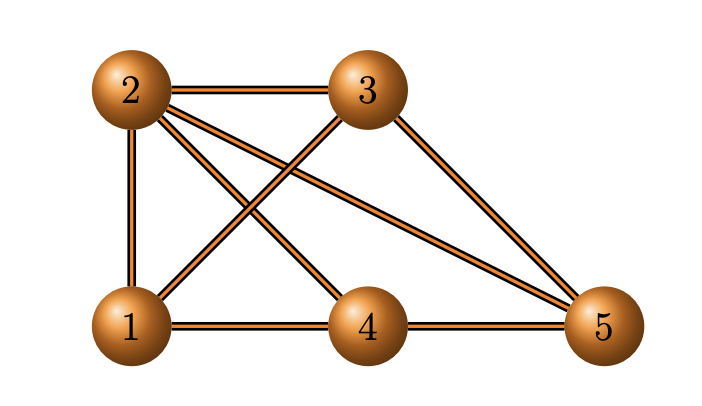

$P\,=\, \left( \begin{array}{ccccc} 0 & \frac13 & \frac13 & \frac 13 & 0 \\ \frac14 & 0 & \frac14 & \frac 14 & \frac14 \\ \frac13 & \frac13 & 0 & 0& \frac 13 \\ \frac13 & \frac13 & 0 & 0 & \frac13 \\ 0 & \frac13 & \frac13 & \frac13 & 0 \\ \end{array} \right)$ $\quad \quad \quad \pi = \left( \frac{3}{16}, \frac{4}{16}, \frac{3}{16}, \frac{3}{16}, \frac{3}{16}\right)$

**Example 1.4 (Random walk on the hypercube)**

The $d$-dimensional hypercube graph $Q_d$ has for vertices the binary $d$-tuples
$$\mathbf{x}=(x_1, \cdots, x_d) \quad \text{ with } x_k \in \{0,1\}$$
Two vertices are connected by an edge when they differ in exactly one coordinate (flipping a $0$ into $1$ or vice-versa).

The simple random walk on $Q_d$ moves from one vertex $x=(x_1, \cdots, x_d)$ by choosing a coordinate $j \in \{ 1,2,\cdots, d\}$ uniformly at random and setting $x_j \to (1-x_j)$.

The degree of each vertex is $d$, the number of vertices is $2^d$ and the number of edges is $2^d \frac{d}{2}$.

The stationary distribution is $\pi(\mathbf{x}) \,=\, \frac{1}{2^d}$,the uniform distribution on $Q_d$.

Variation on this random walk have many applications, you can intepret the vector $\mathbf{x}$ as describing which one of $d$ objects is on a list (see the section on Monte-Carlo Markov chains)

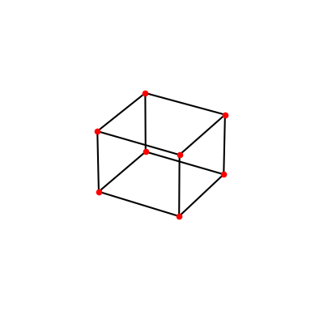

**Example 1.5 (Assymetric random walks on {0,1, , N})** State space $S=\{0,1,\cdots,N\}$ and the Markov chain goes up by $1$ with probability $p$ and down by $1$ with probaility $1-p$.
$$P(j, j+1) =p,\, P(j, j-1) = 1-p \,, \quad \textrm {for } j=1, \cdots, N-1$$
We can pick different boundary conditions (BC) at $0$ and $N$:

- Absorbing BC: $P(0,0)=1, P(N,N)=1$
- Reflecting BC: $P(0,1)=1, P(N,N-1)=1$
- Partially reflecting BC: $P(0,0)=(1-p)\,, P(0,1)=p P(N,N-1)=(1-p)\,, P(N,N)=p$
- Periodic BC: $P(0,1)=p\,, P(0, N)=(1-p)\,, \quad P(N, 0) =p\,, P(N, N-1)= (1-p)$

**Example 1.6 (Ehrenfest urn model)** Suppose $d$ balls are distributed among two urns, urn $A$ and urn $B$. At each move one ball is selected uniformly at random among the $d$ balls and is transferred from its current urn to the other urn. If $X_n$ is the number of balls in urn $A$ then the state space is $S=\{0, 1, \cdots, d\}$ and the transition probabilities
$$P(j,j+1) \,=\, \frac{d-j}{d}\,, \quad P(j,j-1) \,=\, \frac{j}{d} \,.$$
We show that the invariant distribution is binomial with paramters $(d,\frac{1}{2})$, that is $\pi(j) \,=\, {d \choose j} \frac{1}{2^d}$.

$$\begin{aligned}
\pi P (j) &= \sum_{k} \pi(k) P(k,j) = \pi(j-1) P(j-1,j) + \pi(j+1) P(j+1, j) \\
&= \frac{1}{2^d}\left[ {d \choose j-1} \frac{d - (j-1)}{d} + {d \choose j+1} \frac{j+1}{d} \right]
= {d \choose j} \frac{1}{2^d} \,.
\end{aligned}$$

This Markov chain is closely related to the simple random walk $Y_n$ on the hypercube $Q_d$. Indeed selecting randomly one of the $d$ balls and moving it the other urn is equivalent to selecting a random coordinate $y_k$ of $\mathbf{y}=(y_1, \cdots, y_d)$ and changing it to $1-y_k$. If we denote by $j= |\mathbf{y}|=y_1+ \cdots + y_d$ to be the number of $1$s in $\mathbf{y}$. Then
$$P(X_n=j+1|X_n=j) = P(\textrm{ choose } k \textrm{ such that } y_k=0) = \frac{d-j}{d}$$

## 1.7 Simulation of Markov chains

- It is relatively easy to compute the distribution of $X_n$ by matrix multiplication, that is $\mu P^n$ if $P$ is not too large.
- It is also not difficult to generate the paths $X_0, X_1, X_2, \cdots$ of the Markov chain.
  - Set $X_0=i$ (or generate the random variable $X_0$ with distribution $\mu$)
  - Generate the RV $Z$ with probability distribution $(P(i,1), \cdots P(i,n))$ and set $X_1=Z$.
  - and so on.
- To generate a discrete RV with finite state space do

```python
import numpy as np

# Create an array to describe the state space
elements = np.array([1, 2, 3, 4, 5])

# Define nonuniform probabilities for each element
probabilities = np.array([0.1, 0.2, 0.3, 0.2, 0.2])

# Use random.choice with nonuniform probabilities
random_element = np.random.choice(elements, p=probabilities)
```

## 1.8 Exercises

**Exercise 1.1** A standard die is rolled repeatedly. Which of the following are Markov chains? For those that are, supply the transition matrix.

1. The largest number $X_n$ shown up to the nth roll.
2. The number $N_n$ of sixes in n rolls.
3. At time r the time $C_r$, since the most recent six.
4. At time r, the time $B_r$ until the next six.

**Solution**

1. The state space is $\{1, \cdots, 6\}$ and $P=\begin{bmatrix} 1/6 & 1/6 & 1/6 & 1/6 & 1/6 & 1/6 \\ 0 & 2/6 & 1/6 & 1/6 & 1/6 & 1/6 \\ 0 & 0 & 3/6 & 1/6 & 1/6 & 1/6 \\ 0 & 0 & 0 & 4/6 & 1/6 & 1/6 \\ 0 & 0 & 0 & 0 & 5/6 & 1/6 \\ 0 & 0 & 0 & 0 & 0 & 1 \end{bmatrix}$
2. The state space is $\{0,1, 2, \cdots, \}$ and it is natural to pick $N_0=0$. We have $N_{n+1}=N_n + Z_{n+1}$ where $Z_n$ are IID bernoulli RV with $p=1/6$. Thus $P(i,i)=5/6$ and $P(i,i+1)=1/6$.
3. The state space is $\{0,1, 2, \cdots, \}$. If $C_r=i$ it the last six occurred at time $r-i$ and thus $C_{r+1}$ can be either $i+1$ or $0$ depending whether you roll a six or not. So we have $P(i,i+1)=5/6$ and $P(i,0)=1/6$.
4. The time until the next $6$ does not depend on your current state and so $B_r$ are independent geometric RV with $p=1/6$.

**Exercise 1.2** Suppose $X_n$ is a Markov chain on the state space $\{1,2,3,4,5,6\}$. Is it true that
$$P(X_2=6| X_1\in\{3,4\}, X_0=2) = P(X_2=6|X_1\in\{3,4\})?$$
$$P(X_2=6| X_1=3, X_0\{2,5\}) = P(X_2=6|X_1=3)?$$
Prove or disprove.

**Exercise 1.3 (More on the Markov property)** We have introduced the Markov property as meaning that the future depends on the present but not on the past, see Definition 1.2. Show that for a Markov chain the following two condition hold

1. The past depends only on the present but not on the future:
   $$P(X_0=i_0 \,|\, X_{1}=i_{1}, \cdots X_n=i_n)
   = P( X_0=i_0\,|\, X_{1}=i_{1})\,.$$
2. Conditioned on the present, the past and the future are independent,:
   $$P( X_{n+1}=i_{n+1}, X_{n-1}=i_{n-1} | X_n =i_n)= P( X_{n+1}=i_{n+1}| X_n =i_n) P( X_{n-1}=i_{n-1} | X_n =i_n)$$
3. Generalize part b. and show that for any event $A$ which depends only on $\{X_0, \cdots, X_{n-1}\}$ we have
   $$\begin{aligned}
   & P( \{X_{n+1}=i_{n+1}, \cdots X_{n+m}=i_{n+m}\} \cap A | X_n =i ) \\
   &= P( X_{n+1}=i_{n+1}, \cdots X_{n+m}=i_{n+m} | X_n =i)P(A|X_n =i)
   \end{aligned}$$

**Solution**

Suppose the Markov chain start in the state $\mu$.

1. We have
   $$\begin{aligned}
   P(X_0=i_0 \,|\, X_{1}=i_{1}, \cdots X_n=i_n)&= \frac{P(X_0=i_0, X_{1}=i_{1}, \cdots X_n=i_n)}{P( X_{1}=i_{1}, \cdots X_n=i_n)} \\
   & = \frac{\mu(i_0)P(i_0,i_1)\cdots P(i_{n-1},i_n)}{ \mu P(i_1) P(i_1,i_2) \cdots P(i_{n-1},i_n)} =
   \frac{\mu(i_0)P(i_0,i_1)}{ \mu P(i_1)} \\
   & = \frac{P(X_0=i_0, X_1=i_1 )}{P(X_1=i_1)} = P(X_0=i_0 \,|\, X_{1}=i_{1})
   \end{aligned}$$
2. Using $P(AB|C)=P(A|BC)P(BC)$ and the Markov property we have
   $$\begin{aligned}
   & P( X_{n+1}=i_{n+1}, X_{n-1}=i_{n-1} | X_n =i_n) \\
   &= P( X_{n+1}=i_{n+1} | X_n =i_n, , X_{n-1}=i_{n-1})P(X_{n-1}=i_{n-1} | X_n =i_n) \\
   & = P( X_{n+1}=i_{n+1} | X_n =i_n)P(X_{n-1}=i_{n-1} | X_n =i_n)
   \end{aligned}$$
3. Any event which depends only $\{X_0, X_1, \cdots, X_{n-1}\}$ can be written as a disjoint union of events of the form $\{X_0=i_0, \cdots, X_{n-1}=i_{n-1}\}$ and by the addition rule for probability we may assume $A$ has this form. The proof follows then exactly the same steps are in part b.  
   This equation means that, conditioned on the present state being $i_n$, the Markov chain in the future is independent of any event of the past and starts anew with initial conidition $i_n$.

**Exercise 1.4 (2-steps Markov chain)** Suppose that $X_n$ is a Markov chain with state space $S$, transition probabilities $P(i,j)$ and stationary distribution $\pi(i)$. Show that
$$Z_n = ( X_n, X_{n+1} )$$
is a Markov chain. What are (a) the state space, (b) the transition probabilities, and (c) the stationary distribution?

**Solution**

The state space of $Z_n$ is $T = \{(i,j) \in S \times S \text{ such that } P(i,j) >0 \}$. It is a Markov chain since the distribution of $(X_n,X_{n+1})$ depends only $X_{n-1}$ and thus only on $Z_{n-1}$. The transition probabilities are
$$P((k,l), (i,j)) = P(Z_n=(i,j)| Z_{n-1}=(k,l)) = P(X_n=i, X_{n+1}=j|X_n=l, X_{n-1}=k) = \delta(i,l)P(l,j)$$
where $\delta(i,l)$ are the entries of the identity matrix (i.e. $\delta(i,l)=0$ if $i\not=l$ and $delta(i,i)=1$).

The stationary distribution is $\tilde{\pi}(i,j)=\pi(i) P(i,j)$. First $\sum_{i,j} \pi(i)P(i,j)= \sum_i \pi(i)=1$ and using the stationarity of $\pi$
$$\sum_{k,l} \tilde{\pi}(k,l) P((k,l), (i,j)) = \sum_{k,l} \pi(k) P(k,l) \delta(i,l) P(l,j) = \sum_{k} \pi(k) P(k,i) P(i,j) = \pi(i) P(i,j) =\tilde{\pi}(k,l)$$

**Exercise 1.5 (Markov chain finite memory)** Instead of the Markov property let us assume $X_n$ depends on the previous two steps: i.e we have for all $n$ and states
$$P\{X_n=i_n \,|\, X_{n-1}=i_{n-1}, \cdots X_0=i_0\}
= P\{ X_n=i_n\,|\, X_{n-1}=i_{n-1}, X_{n-2}=i_{n-2}\}\,.$$
This is called a **$2$-Markov chain** and if it is time-homogeneous it is specified by the numbers $Q_{i,j,k}=P\{ X_n=k\,|\, X_{n-1}=j, X_{n-2}=i\}$. Show that
$$Z_n = (X_{n}, X_{n+1})$$
is a Markov chain. Describe its state space and transition probabilities.

**Solution**

The state space is $S \times S$. We have
$$\begin{aligned}
& P(Z_{n+1}=(i_{n+1},j_{n+1})| Z_{n}=(i_{n},j_{n}) , \cdots, Z_{0}=(i_0,i_1)) \\
& = P( X_{n+1}=i_{n+1}, X_{n+2}=j_{n+1}| X_{n+1}=j_n, X_n=i_n, X_{n}=j_{n-1}, X_{n-1}=i_{n-1} \cdots, X_1=j_0, X_0=i_0)
\end{aligned}$$
For this to be non-zero we need $j_0=i_1$, $j_1=i_2$ and so on. Assuming this hold we have then
$$\begin{aligned}
&P( X_{n+1}=i_{n+1}, X_{n+2}=j_{n+1}| X_{n+1}=i_{n+1}, X_n=i_n, X_{n-1}=i_{n-1} \cdots, X_1=i_1, X_0=i_0) \\
&= P( X_{n+2}=j_{n+1}| X_{n+1}=i_{n+1}, X_n=i_n, X_{n-1}=i_{n-1} \cdots, X_1=i_1, X_0=i_0) \\
& = P( X_{n+2}=j_{n+1}| X_{n+1}=i_{n+1}, X_n=i_n) = Q(i_n, i_{n+1}, j_{n+1}) \\
&= P( X_{n+1}=i_{n+1}, X_{n+2}=j_{n+1}| X_{n+1}=i_{n+1}X_n=i_n) \\
&= P(Z_{n+1}=(i_{n+1},j_{n+1})| Z_{n}=(i_{n},i_{n+1}))
\end{aligned}$$
which establish the Marko property. The transition matrix is given by $P( Z_{n+1} = (i,j)| Z_n=(k,l)) = \delta(i,l) Q(k,i,j)$ where $\delta(i,l)$ are the entries of the identity matrix.

**Exercise 1.6** Suppose $\{X_n\}$ are independent indentically distributed random variables taking values in $\mathbb{Z}$. Determine which of the following are Markov chains.

1. $X_n$
2. $S_n=X_1+ \cdots + X_n$ (with $S_0=0$)
3. $Y_n = X_n+ X_{n-1}$ (with $X_{-1}=0$ so $Y_0=X_0$)
4. $Z_n = \sum_{k=0}^n S_k$
5. $(S_n,Z_n)$

**Solution**

1. By independence
   $$\begin{aligned}
   P(X_{n+1}=i_{n+1}|X_n=i_n, X_{n-1}= i_{n_1}, \cdots, X_0=i_0) &= P(X_{n+1}=i_{n+1}) \\
   &= P(X_{n+1}=i_{n+1}|X_n=i_n)
   \end{aligned}$$
   and thus $X_n$ is Markov.
2. Since $S_{n+1}= S_n + X_{n+1}$,
   $$\begin{aligned}
   P(S_{n+1}=s_{n+1}|S_n=s_n, S_{n-1}= i_{n_1}, \cdots, S_0=i_0)& = P(X_{n+1} = s_{n+1}-s_n ) \\
   &= P(S_{n+1}=s_{n+1}|S_n=s_n)
   \end{aligned}$$
   and thus it is Markov.
3. $Y_n$ is not Markov. For example for $n=2$ we have
   $$\begin{aligned}
   P(Y_2= i_2| Y_1=i_1, Y_0=i_0) &= P(X_2 + X_1 = i_2| X_1+ X_0=i_1, X_0=i_0) \\
   & = P(X_2 + X_1 =i_2 | X_1=i_1 -i_0, X_0=i_0) \\
   &= P(X_2=i_2- i_1 + i_0)
   \end{aligned}$$
   On the other hand $P(Y_2= i_2| Y_1=i_1)= P(X_1+X_2= i_2| X_1+ X_0= i_1)$ which is different since the conditioning does not depend on $i_0$.
4. $Z_n$ is not a Markov chain. To see this (there are many ways to do this) note that $Z_1=S_1=X_1$, $Z_2=S_1+S_2= 2X_1 + X_2, \cdots, Z_n= nX_1 + (n-1) X_2 + \cdots X_n$. By inverting the linear relation between the $Z_n$ and the $X_n$ one sees that the information contained in $(Z_1, \cdots, Z_n)$ is the same as in $(X_1, \cdots, X_n)$. Therefore given $(Z_1, \cdots, Z_n)$, $Z_{n+1}= Z_n + S_{n+1}$ depends only on the value of $X_{n+1}$. This is clearly different for $Z_{n+1}$ condition on $Z_n$ which depends on $S_{n+1}$ and thus all values of $X_i$.
5. If you know $(S_n,Z_n)$ then $(S_{n+1},Z_{n+1})=(S_n + X_{n+1}, Z_n + S_n + X_{n+1})$. Arguing in a similar way as in 2. we see it is a Markov chain. Even though $Z_n$ is not a Markov chain if we keep track of some extra information (that is $S_n$) we can obtain a Markov chain in a larger state space.

**Exercise 1.7 (Umbrella Markov chain)** Jane possesses $r$ umbrellas which she uses going from her home to her office in the morning and vice versa in the evening. If it rains in the morning or in the evening she will take an umbrella with her provided there is one available. Assume that independent of the past it will rain in the morning or evening with probability $p$. Let $X_n$ denote the number of umbrellas at her home before she gets to work.

1. Give the state space and the transition probabilities describing the Markov chain $X_n$.
2. Find the stationary distribution $\pi(j)$.
3. Estimate the number of times in a year where Jane gets wet.

**Solution**

1. If there are $j$ umbrellas at home (with $j\not=0,r$) there always will be umbrellas available both at home and at work and thus we have
   $$P(j,j+1) = p(1-p), P(j,j) = p^2 + (1-p)^2, P(j,j-1)= p(1-p)$$
   For example $P(j,j+1)=P( \text{rain in the AM and no rain in the PM})$.
   The case $j=0$ and $j=r$ are a bit different. We have
   $$P(0,0) =P(\text{no rain in the PM}) = (1-p), \quad P(0,1) =p$$
   $$P(r,r-1)= P(\text{rain in the AM and no rain in the PM})=p(1-p), P(r,r)= p^2 +(1-p)^2 + p(1-p) \,.$$
2. To find the stationary distribution we solve $\pi P = \pi$ recursively and find
   $$\begin{aligned}
   \pi(0) (1-p) + \pi(1) p(1-p) = \pi(0) & \implies \pi(1)(1-p) = \pi(0) \\
   \pi(0) p + \pi(1) (p^2 +(1-p)^2) + \pi(2) p(1-p) = \pi(1) & \implies \pi(2)=\pi(1) \\
   \pi(1) p(1-p) + \pi(2) (p^2 +(1-p)^2) + \pi(3) p(1-p) = \pi(2) & \implies \pi(3)=\pi(2) \\
   \vdots & \\
   \pi(r-2) p(1-p)+ \pi(r-1) (p^2 +(1-p)^2) + p(1-p) \pi(r) = \pi(r-1) & \implies \pi(r)=\pi(r-1) \\
   \pi(r-1)p(1-p) + \pi(r)(p^2 +(1-p)^2 + p(1-p)) = \pi(r) & \implies \pi(r)=\pi(r-1) \\
   \end{aligned}$$
   Therefore the stationary distribution is $\pi =\left(\frac{1-p}{1-p+r},\frac{1}{1-p+r},\cdots,\frac{1}{1-p+r})\right)$
3. You get wet if you have $0$ umbrella at home and it rains in the AM or if you have r umbrellas at home and it does not rain in the AM and rains in the PM. Over a long period of time, say a year, you will get wet $365 (\pi(0)p + \pi(r)p(1-p)) = 365\frac{2p(1-p)}{1-p+r}$ days.

**Exercise 1.8 (Simulation of Markov chains)** Write codes which simulate the umbrella Markov chain in the previous exercise (or other Markov chains where the transition matrix is not too big). The input should be the initial distribution, or initial state, and the transition probability matrix. Your code should return as outputs

- $P^n$ for sufficently large $n$.
- One sufficently long path $X_0, X_1, X_2, \cdots, X_n$ of the Markov chain using the simulation algorithm in Section 1.7. Use this path to extract the path statistics: find the proportion of time spent in every state (for example do an histogram).
- What do you observe for the umbrella Markov chains?

**Exercise 1.9** Suppose $X_n$ is a Markov chain with state space $S$ and $h:S \to T$ is a function.

- Show that if $h$ is one-to-one then $Y_n=h(X_n)$ is a Markov chain.
- Show that if $h$ is not one-to-one then $Y_n=h(X_n)$ is not a Markov chain in general.
- If $h$ is not one-to-one and $Y_n$ is a Markov chain then the Markov chain $X_n$ is called lumpable.  
  Show that the random walk on the hypercube is lumpable if $h(x_1,\cdots, x_d)=x_1+\cdots x_d$.

**Exercise 1.10 (Canonical representation of Markov chains)**

1. A general way to construct a Markov chain is to use a noise model. Take $Z_1,Z_2,Z_3 \cdots$ to be IID random variables taking value in some arbitary space $E$. If $f: S \times E \to S$ is a function show that
   $$X_{n+1}=f(X_n, Z_{n+1})$$
   defines a Markov chain. For example you can think of $f(X_n) + Z_{n+1}$ as determinstic evolution plus noise.
2. Conversely show that any Markov chain can be represented in this form.  
   *Hint:* Pick $Z_n$ to be independent uniform random variable on $[0,1]$ and use the simulation algorithm in Section Section 1.7.

**Solution**

1. Check the Markov property. Since the $Z_n$ are independent of each other.
   $$P( X_{n+1} =j | X_n=k) = P(f(k,Z_{n+1}=j)$$
   and the same is true for $P( X_{n+1} =j | X_n= k, X_{n-1}=k_1, \cdots, X_0=n_k)$.
2. Given a Markov chain with transition probbailities $P(i,j)$ and state space $S=\{1,2,3, \cdots, N\}$, we take $U_n$ to be IID uniform random variables on $[0,1]$. Then we define
   $$f(i,U) = \left\{
   \begin{array}{cl}
   1 & \text{ if } 0\le U \le P(i,1) \\
   2 & \text{ if } P(i,1) \le U \le P(i,1)+ P(i,2) \\
   \vdots & \vdots \\
   k & \text{ if } P(i,1) + \cdots P(i,k-1) \le U \le P(i,1)+ \cdots P(i,k) \\
   \vdots & \vdots
   \end{array}
   \right.$$
   Then
   $$\begin{aligned}
   P(X_{n+1}=k|X_n=i)&= P( f(i,U_{n+1})=k) \\
   &= P(P(i,1) + \cdots P(i,k-1) \le U \le P(i,1)+ \cdots P(i,k))= P(i,k)
   \end{aligned}$$
   as desired.

# 2 Ergodic theory of finite state space Markov chains

We present the basic convergence theory for finite state Markov chains and introduce the concept of irreducubility and period of a Markov chain. This is very classical stuff, see e.g. Lawler (2006) and Levin et al. (2017).

## 2.1 Existence of stationary distributions

Stationary distributions always exist for finite state Markov chains. This will not be the case if the state space is countable.

**Theorem 2.1 (Existence)** Let $X_n$ be a Markov chain on a finite state space $S$. Then $X_n$ has at least one stationary distribution.

*Proof*. Boltzano Weierstrass theorem asserts that any bounded sequences $x_k$ in $\mathbb{R^d}$ has a convergence subsequence.

Choose $\mu_0$ to be an arbitrary initial distribution and let $\mu_n = \mu P^n$. Appling Boltzano Weierstrass directly to the sequence $\mu_n$ will not work but consider instead the time averages sequences
$$\nu_n \,=\, \frac{\mu + \mu P + \cdots \mu P^{n-1}}{n}$$
The sequence $\nu_n$ is bounded since $\mu_n$ and thus $\nu_n$ are probability vector. Therefore there exists a convergent subsequence $\nu_{n_k}$ with $lim_{k}\nu_{n_k}=\pi$ and $\pi$ is a probability vector as well. We show that $\pi$ is a stationary distribution. Note
$$\nu_n P - \nu_n \,=\, \frac{ \mu P + \cdots \mu P^{n} - \mu - \cdots -\mu P^{n-1}}{n} \,=\,
\frac{\mu P^n - \mu}{n} \quad \textrm{ and thus } \quad \left\vert \nu_n P(j) - \nu_n(j) \right\vert \,\le \, \frac{1}{n}$$
To conclude we note that
$$| \pi P(j) - \pi(j)| \,=\, \lim_{k \to \infty} | \nu_{n_k}P (j) - \nu_{n_k}(j) | \,\le\, \lim_{k \to \infty} \frac{1}{n_k} \,=\, 0 \,.$$
and thus $\pi$ is a stationary distribution. $\quad \square$.

## 2.2 Uniqueness of stationary distributions

**Definition 2.1 (communication and irreducibility)**

- We say that **$j$ is accessible from $i$**, symbolically **$i \rightsquigarrow j$** if there exists $n\ge 0$ such that $P^n(i,j)>0$.
- We say that **$i$ and $j$ communicate**, symbolically **$i \leftrightsquigarrow j$** if $i \rightsquigarrow j$ and $j \rightsquigarrow i$.
- A Markov chain $X_n$ is **irreducible** if every state $i\in S$ communicate with every other state $j \in S$, that is, for any pair of states $i,j$ in $S$ there exists $n$ such that $P^n(i,j) >0$.

In an irreducible Markov chain, starting with any state the Markov chain will eventually visit any other state.

**Theorem 2.2 (Uniqueness)** Suppose $X_n$ is an irreducible Markov chain with finite state space $S$.

1. If $\pi$ is a stationary distribution then $\pi(j)>0$ for all $j\in S$,
2. Suppose $h$ is a column vector such that $Ph=h$ then $h=c(1,1,\cdots,1)^T$ is a constant vector.
3. The Markov chain $X_n$ has a unique stationary distribution $\pi$.

*Proof*. For 1. choose $i$ with $\pi(i)>0$. If $j$ is such that $i \rightsquigarrow j$ then $P^r(i,j) >0$ for some $r$ and thus
$$\pi(j) =\pi P^r(j)\,=\, \sum_{k} \pi(k) P^r(k,j) \,\ge \, \pi(i) P^r(i,j) >0 \,.$$
Since $X_n$ is irreducible, $\pi(j)>0$ for any $j \in S$.

For 2. suppose that $Ph=h$ and $i_0$ such that $h(i_0)= \max_{i\in S} h(i)\equiv M$. If $h$ is not a constant vector there exists $j$ with $i_0 \rightsquigarrow j$ but $h(j) < M$ and $P^r(i_0,j)>0$. Since $P^rh=h$,
$$M= h(i_0) \,=\, P^r h(i_0) \,=\, P^r( i_0, j) \underbrace{h(j)}_{< M} + \sum_{l \not= i_0} P^r(i_0,l) \underbrace{h(l)}_{\le M} < M\sum_{l} P^r(i_0,l)=M\,,$$
and this is a contradiction.

For 3. part 2. shows that the geometric multiplicity of the eigenvalue $1$ matrix $P$ is equal to $1$ and thus so is the geometric multiplicity of the eigenvalue $1$ for the adjoint $P^T$ and thus $P$ has at most one left eigenvector $\pi$.

## 2.3 Convergence to stationary distribution

- **Question**: If we have a unique stationary distribution is it correct that $\lim_{n \to \infty} \mu P^n = \pi$?
- Without further assumption the answer is NO, because of possible periodic behavior. Consider for example the random walk on $\{1, \cdots, 2N\}$ with, for example, periodic boundary conditions. The stationary distribution is uniform $\pi= \left(\frac{1}{2N}, \cdots, \frac{1}{2N}\right)$. But if $X_0$ is even then $X_1$ is odd and then alternating periodically between odd and even positions. For example for
  $$P \,=\, \left( \begin{array}{cccc} 0 & 1/4 & 0 & 3/4 \\ 3/4 & 0 & 1/4 & 0 \\
  0 & 3/4 & 0 & 1/4 \\
  1/4 & 0 & 3/4 & 0 \end{array} \right) \quad \quad \pi = \left( \frac14,\frac14 ,\frac14,\frac14 \right)
  \textrm{ is stationary}$$
  and
  $$P^{10}=\begin{pmatrix}
  0.4995 & 0 & 0.5004 & 0 \\
  0 & 0.4995 & 0 & 0.5004 \\
  0.5004 & 0 & 0.4995 & 0 \\
  0 & 0.5004 & 0 & 0.4995 \\
  \end{pmatrix}
  \quad \quad
  P^{11}=
  \begin{pmatrix}
  0 & 0.5002 & 0 & 0.4997 \\
  0.4997 & 0 & 0.5002 & 0 \\
  0 & 0.4997 & 0 & 0.5002 \\
  0.5002 & 0 & 0.4997 & 0 \\
  \end{pmatrix}$$
  and $P^n(i,j)$ does not converge, oscillates, asymptotically between $0$, and $1/2$.

**Definition 2.2** A Markov chain $X_n$ is called *irreducible and aperiodic* if there exists an integer $n$ such that $P^n(i,j) > 0$ for all pair $i,j$ in $S$. (The meaning of the terminology will become clearer later on.)

**Theorem 2.3 (Doeblin’s Theorem)** Suppose $X_n$ be an irreducible and aperiodic Markov chain on the finite state space $S$ with stationary distribution $\pi$. There exists a constant $C>0$ and number $\alpha$ with $0\le \alpha< 1$ such that for any initial distribution $\mu$ we have
$$|\mu P^n(j) - \pi(j)| \,\le\, C \alpha^n \,,
\tag{2.1}$$
i.e., the distribution of $X_n$ converges, exponentially fast, to $\pi$.

*Proof*. Since the Markov chain is irreducible and aperiodic we can find an integer $r$ such that $P^r$ has strictly positive entries. Let $\Pi$ be the stochastic matrix
$$\Pi \,=\, \left( \begin{array}{cccc} \pi(1)& \pi(2)& \cdots& \pi(N) \\
\pi(1)& \pi(2)& \cdots& \pi(N) \\
\vdots& \vdots & &\vdots
\\
\pi(1) &\pi(2)& \cdots& \pi(N)
\end{array}
\right)$$
where every row is the stationary distribution $\pi$. Note that this corresponds to independent sampling from the stationary distribution.

Since all elements of $P^r(i,j)$ are strictly positive we can pick $\delta >0$ sufficiently small such that for all $i,j$
$$P^r(i,j) \,\ge \, \delta\,\Pi(i,j)=\delta \pi(j) \,.
\tag{2.2}$$

Let us set $\theta = 1-\delta$ and by Equation 2.2 we define a stochastic matrix $Q$ through the equation
$$P^r = (1-\theta) \Pi + \theta Q \,.$$
Note the following facts:

- Since $\pi P = \pi$ we have $\Pi P^n = \Pi$ for any $n \ge 1$.
- For any stochastic matrix $M$ we have $M \Pi = \Pi$ since all rows of $\Pi$ are identical.

Using these two properties we show, by induction, that any integer $k\ge 1$, $P^{kr} \,=\, (1 - \theta^k) \Pi + \theta^k Q^k$. This is true for $k=1$ and so let us assume this to be true for $k$. We have
$$\begin{aligned}
P^{r(k+1)} = P^{rk} P^r &= \left[ (1 - \theta^k) \Pi + \theta^k Q^k \right] P^r
= (1 - \theta^k) \Pi P^r + \theta^k Q^k [(1-\theta) \Pi + \theta Q] \\
&= (1 - \theta^k) \Pi + \theta^k(1-\theta) \Pi + \theta^{k+1} Q^{k+1} = (1 - \theta^{k+1}) \Pi + \theta^{k+1} Q^{k+1}
\end{aligned}$$
and this concludes the induction step.

From this we conclude that $P^{rk} \to \Pi$ as $k \to \infty$. Write $n=k r +l$ where $0 \le l < r$. We have then
$$P^n = P^{kr} P^l = [(1 - \theta^k) \Pi + \theta^k Q^k] P^l = \Pi + \theta^{k} \left[ Q^k P^l - \Pi \right]$$
and thus
$$|P^n(i,j) - \pi(j)| \,=\, \theta^k |Q^k P^l(i,j) - \Pi(i,j)| \le \theta^k \le \frac{1}{\theta} (\theta^{1/r})^n \equiv C\alpha^n \,.$$
The same holds for any initial distribution multiplying by $\mu(i)$ and summing.

## 2.4 The period of a Markov chain

As we have seen before Markov chain can exhibit periodic behavior and circle around various part of the state space.

**Definition 2.3** The *period of state $j$, $\textrm{per}(j)$* is the greatest common divisor of the set
$${\mathcal T}(j) \,=\, \left\{ n\ge 1\,,\, P^n(j,j)>0 \right\}$$
that is ${\mathcal T}(j)$ is set of all times at which the chain can return to $j$ with positive probability.

For example for random walks with periodic boundary conditions the period is 2 is the number of sites is even and 1 if the number of sites is odd.

- The set *${\mathcal T}(j)$ is closed under addition*:
  $$n,m \in {\mathcal T}(j) \implies m+n \in {\mathcal T}(j)$$
  which holds true since $P^{n+m}(j,j) \ge P^{n}(j,j)P^{m}(j,j)$.
- By definition if $\textrm{per}(j)=d$ then
  $${\mathcal T}(j) \subset \{ 0,d,2d, \cdots\}$$
  Since it is closed under addition a **fact from number theory** (see exercise) implies that there exists $k$ such that
  $$\{ kd, (k+1)d, (k+2)d \cdots \} \subset {\mathcal T}(j) \quad \textrm { or equivalently } \quad P^{nd}(j,j)>0 \textrm{ for all } n\ge k$$

**Lemma 2.1** If $i \leftrightsquigarrow j$ then $\textrm{per}(i)=\textrm{per}(j)$.

*Proof*. Suppose $\textrm{per}(j)=d$ and $i \leftrightsquigarrow j$. There exist integers $m$ and $m$ such that $P^m(i,j)>0$ and $P^n(j,i)>0$ and thus
$$P^{m+n}(i,i)>0 \textrm{ and }P^{m+n}(j,j)>0$$
which means that $m+n \in {\mathcal T}(i) \cap {\mathcal T}(j)$ and so $m+n=kd$ for some integer $k$.

Suppose $l \in {\mathcal T}(i)$ then
$$P^{n+m+l}(j,j) \ge P^n(j,i) P^l(i,i) P^m(i,j) > 0$$
and $n+m+l \in {\mathcal T}(j)$. Therefore $d$ divides $l$ since it divides both $n+m+l$ and $n+m$ and this shows that $\textrm{per}(j) \le \textrm{per}(i)$. Reversing the roles of $i$ and $j$ we find $\textrm{per}(j) = \textrm{per}(i)$. $\quad \blacksquare$

**Consequences:**

- If $X_n$ is irreducible then all states have the same period and we can define the period of the irreducible Markov chain $X_n$ .
- If $X_n$ is irreducible and has period 1 (also called aperiodic) and $S$ is finite then $P^{n}(i,j) >0$ for all suficiently large $n$ (compare with our earlier definition of irreducible and paeriodic).

Decomposing the state space $S = G_1 \cup G_2 \cup \cdots G_d$:

- Start with a state $i\in S$ and let $i \in G_1$.
- For all $j$ such that $P(i,j)>0$ let $j \in G_2$.
- For all $j\in G_2$ and all $k$ such that $P(j,k)>0$ let $k\in G_3$.
- After assigning set to $G_d$ assign the next states to $G_1$.
- Repeat until all states have been assigned. If $|S|$ is finite this takes at most $|S|$ steps.

By construction we get a partition of $S$ into $d$ distinct subsets $G_1, \cdots, G_d$ and
$$P(i,j)> 0 \implies i \in G_k \textrm{ and } j \in G_{k+1 (\textrm{mod} d)}$$
For example

$$P=
\begin{matrix}
1\\2\\3\\4\\5\\6\\7
\end{matrix}
\begin{pmatrix}
0 & 0 & 0 & 1 & 0 & 0 & 0 \\
0 & 0 & 0 & 0 & 0 & 0 & 1 \\
1 & 0 & 0 & 0 & 0 & 0 & 0 \\
0 & 0 & .2 & 0 & 0 & .8 & 0 \\
.3 & .7 & 0 & 0 & 0 & 0 & 0 \\
.2 & .8 & 0 & 0 & 0 & 0 & 1 \\
0 & 0 & 0 & 0 & .7 & .3 & 0 \\
\end{pmatrix}$$

Iteratively we find
$$1 \rightsquigarrow 4 \rightsquigarrow 3,6 \rightsquigarrow 1,2 \rightsquigarrow 4,7 \rightsquigarrow 3,5,6 \rightsquigarrow 1,2
\rightsquigarrow 4,7$$
and thus the Markov chain is irreducible with period $3$ and so we have
$$S=\{1,2\} \cup \{4,7\} \cup \{3,5,6\}$$

Relabeling the state the transition matrix $P$ takes the following block matrix form
$$P\,=\,
\begin{matrix}
G_1 \\
G_2 \\
\vdots\\
G_{d-1}\\
G_d
\end{matrix}
\begin{pmatrix}
0 & P_{G_1 G_2} & 0 & \cdots &0 \\
0 & 0 &P_{G_2 G_3} & \cdots &0 \\
\vdots & \vdots & & \vdots & \vdots \\
0 & 0 & \cdots & 0 &P_{G_{d-1} G_d} \\
P_{G_dG_1}& 0 & \cdots & 0 & 0
\end{pmatrix}$$

where $P_{G_l G_{l+1}}$ describe the transition between states in $G_l$ and $G_{l+1}$.

Putting the matrix $P$ to the power $d$ we find the block diagonal form
$$P^d\,=\,
\begin{matrix}
G_1 \\
G_2 \\
\vdots\\
G_d
\end{matrix}
\begin{pmatrix}
Q_{G_1} & 0 & 0 & \cdots &0 \\
0 & Q_{G_2} & 0 & \cdots & 0 \\
\vdots & \vdots & & & \vdots \\
0 & 0 & \cdots & 0 & Q_{G_d}
\end{pmatrix}$$

**Theorem 2.4** If $X_n$ is an irreducible Markov chain on a finite state space with stationary distribution $\pi$ then we have
$$\lim_{n \to \infty} \frac{1}{n} \sum_{k=0}^{n-1} P^k(i,j) \,=\, \pi(j) \,.$$

*Proof*. The matrix $Q_{G_l}$, restricted to state space $G_l$ governs the evolution of an irreducible aperiodic Markov chain and thus, by Theorem 2.3, we have
$$\lim_{n \to \infty} P^{nd}(i,j) \,=\,\lim_{n \to \infty} Q^n_{G_l}(i,j) = \pi_{G_l}(j)\,\quad \textrm{ for } i \in G_l, j \in G_l$$
where $\pi_{G_l}$ is the stationary distribution for $Q_{G_l}$. Morever $P^{l}(i,j)=0$ if $l\not=nd$ for some $n$.

If $i \in G_{l-1}$ and $j \in G_{l}$ then
$$\lim_{n \to \infty} P^{nd+1}(i,j) \,=\, \lim_{n\to \infty} \sum_{k \in G_{l}} P(ik) P^{nd}(k,j) \,=\, \sum_{k \in G_{l}} P(ik) \pi_{G_l}(j) \,=\,
\pi_{G_l}(j)\,,$$
and $P^{m}(i,j)=0$ if $m\not=nd+1$ for some $n$. Similarly if $i \in G_{l-r}$ and $j \in G_{l}$ we have
$$\lim_{n \to \infty} P^{nd+r}(i,j) \,=\, \pi_{G_l}(j)\,.$$
and $P^{m}(i,j)=0$ if $m\not=nd+r$ for some $n$.

The sequence $P^n(i,j)$ is asymptotically periodic where $d-1$ successive $0$ alternates with a number converging to $\pi_{G_l}(j)$ and thus if we define $\pi \equiv \frac{1}{d} ( \pi_{G_1}, \cdots, \pi_{G_d})$ then $\pi$ is normalized, stationary and
$$\lim_{n \to \infty} \frac{1}{n} \sum_{k=1}^n P^k(i,j) \,=\, \pi(k)$$
since the time spend in state $j$ is asymptotically equal to $\frac{1}{d} \pi_{G_l}(j)$.

## 2.5 Hitting times, return times and the strong Markov property

We now have good understanding the asymptotic behavior of $P^n(i,j)$ or $\mu P^n$ as $n \to \infty$. When simulating or observing a Markov chain we usually observe a single sequence
$$X_0, X_1, X_2, \cdots$$
and our next goal is to derive a **law large numbers** for this sequence of random variables. To do this it will be useful to track how often the Markov chain visits some state.

**Definition 2.4 (Hitting time and return times)**

- The **Hitting time for the state $j$, $\sigma(j)$,** is the first time the Markov chain visits the state $j$.
  $$\sigma(j) = \inf\{ n \ge 0\,;\, X_n=j \} \quad \textrm{hitting time }$$
- The **return time for the state $j$, $\tau(j)$** is the first time the Markov chain returns to the state $j$.
  $$\tau(j) = \inf\{ n \ge 1\,;\, X_n=j \} \quad \textrm{return time }$$

Hitting time and return times are closely related and are distinct only from the way they consider what happen at time $0$ (both will be useful later on).

Hitting time and return times are example of stopping times and have the crucial property that to decide the events $\tau(j)=k$ we only need to know what happened in $X_0, \cdots X_k$.

**Definition 2.5 (Stopping times)** A random variable $T$ taking values in the integer is called a stopping time for the Markov chain $X_n$ if, for any $k$, the event $\{T=k\}$ depends only on $X_0, X_1, \cdots, X_k$, that is $\{T=k\}$ belong to the $\sigma$-algebra $\sigma(X_0, \cdots, X_k)$.

Intuitively stopping times are random times for the Markov chains which are decided only by looking at the past and the present and not the future, such as hitting time and return times.

Stopping times are very useful for Markov chain: if you run a Markov chain up to a stopping time $T$, then after $T$ the Markov chain starts anew, that is  
$Y_n=X_{T+n}$ is a Markov chain which is independent of the past. More precisely we have

**Theorem 2.5 (Stong Markov property)** Consider a stopping time $T$ with $P(T < \infty)=1$. Then conditional on $X_T=i$, $Y_n=X_{T+n}$ is a Markov chain with transition $P$ and initial condition $i$.

*Proof*. If $A$ is an event determined by $X_0, \cdots, X_T$ then $A \cap \{T=m\}$ is determined by $X_0, \cdots, X_m$. By the Markov property at time $m$ we have
$$P( X_T=j_0, X_{T+1}=j_1, \cdots, X_{T+n}=j_n \cap A \cap {T=m} \cap X_{T}=i) = P( X_{1}=j_1, \cdots, X_{n}=j_n| X_0=i) P(A \cap {T=m} \cap X_{T}=i))$$
Now if we sum over $m=0,1,2, \cdots$ and divide by $P(X_T=i)$ we find
$$P( X_T=j_0, X_{T+1}=j_1, \cdots, X_{T+n}=j_n \cap A |X_{T}=i) = P( X_{1}=j_1, \cdots, X_{n}=j_n|X_0=i) P( A |X_{T}=i)$$
$\quad \square$

## 2.6 Strong law of large numbers for Markov chains

Irreducibility means that starting from $i$ the Markov chain will reach $j$ and thus for any $i$ we have
$$P\{\tau(j) <\infty |X_0=i\} >0$$
If the state space is finite then we have something much stronger. Not only we have $P\{\tau(j) <\infty |X_0=i\} =1$, the expectation of $\tau(j)$ is actually finite.

**Lemma 2.2** For an irreducible Markov chain with finite state space $S$ the expected return time $E[\sigma(j)|X_0=i] < \infty$

*Proof*. By irreducibility the Markov chain can reach the state $j$ from any state $i$ in a finite time. Since $S$ is finite this time is uniformly bounded. So there exist a time $m$ and $\varepsilon>0$ such that $P^l(i,j)\ge \epsilon$ for some $l \le m$ uniformly in $i \in S$. Using the strong Markov property this implies that
$$P\{\sigma(j) > k m|X_0=i\} \le (1-\varepsilon) P \{ \sigma(j) > (k-1) m |X_0=i\}\le \cdots \le (1-\varepsilon)^k$$

Therefore, using that $P\{\sigma(j) > n|X_0=i\}$ is a decreasing function of $n$
$$E[\sigma(j)|X_0=i] = \sum_{n \ge 0} P\{\sigma(j) > n|X_0=i\} \le m \sum_{k \ge 0} P\{\sigma(j) > km|X_0=i\}\le m \sum_{k \ge 0}
(1-\varepsilon)^k < \infty \quad \blacksquare$$

Remark If $S$ is infinite this is not necessarily true and this will lead to the concepts of transience, recurrence and positive recurrence.

We will also need the random variable $Y_n(j)$ which counts the number of visits to starte $j$ up to time $n$ that is
$$Y_n(j) \equiv \sum_{k=0}^{n-1} \mathbf{1}_{\{X_k=j\}} \quad = \textrm{ the number of visits to the state } j \textrm{ up to time } n$$

Since $E \left[ \mathbf{1}_{\{X_k=j\}} \vert X_0=i \right] =P^k(i,j)$ and we have
$$\frac{1}{n}E[Y_n(j)\vert X_0=i]= \frac{1}{n}\sum_{k=0}^{n-1} P^k(i,j)$$
and thus by Theorem 2.3 or Theorem 2.4
$$\pi(j) \,=\, \lim_{n\to \infty} \frac{1}{n}E\left[ \sum_{k=1}^{n} {\textbf{1}}_{\{X_k=j\}} \right] \quad = \textrm{ the proportion of time spent in state } j \textrm{ in the long run }$$
This is an important intuition

$$\pi(j) = \textrm{expected fraction of time that the Markov chain spends in state } j \textrm{ in the long run}.$$
The next results strengthen that intepretation.

**Theorem 2.6 (Ergodic Theorem for Markov chain)** Let $X_n$ be an irreducible Markov chain with an arbitrary initial condition $\mu$, then, with probability $1$ we have
$$\lim_{n \to \infty} \frac{1}{n} \sum_{k=0}^{n-1} {\textbf{1}}_{\{X_n=j\}} \,=\, \pi(j) \,,$$
this is the *ergodic theorem* for Markov chain.

Moreover if $\tau(j)$ is the first return time to $j$ we have the *Kac’s formula*
$$\pi(j) \,=\, \frac{1}{E[\tau(j)|X_0=j]} \,.$$

*Proof*. For a Markov chain starting in some state $i$ consider the successive return to the state $j$. By the strong Markov property, once the Markov chain has reached $j$ it starts a fresh. So the time when the Markov chain returns to state $j$ for the $k^{th}$ time is
$$T_k(j)\,=\, \tau_1(j) + \cdots+ \tau_k(j) \,,$$
where $\tau_l(j)$ are independent copies of the return times $\tau(j)$. For $l\ge 2$ $\tau_l(j)$ is conditioned on starting at $j$ while for $l=1$ it depends on the initial condition. Note that by the strong LLN for IID random variables we have
$$\lim_{k\to \infty}\frac{T_k(j)}{k}\,=\, \lim_{k \to \infty} \frac{1}{k} \left( \tau_1(j) + \cdots+ \tau_k(j) \right) \,=\, E[\tau(j)|X_0=j] \,.$$

Note further that if the total number of visits to state $j$ up to time $n$ is $k$, it means that that we have returned exactyl $k$ times and so
$$\left\{ Y_n(j)=k \right\} =\left\{ T_{k}(j) \le n < T_{k+1}(j) \right\}$$
So we have
$$\frac{ T_{Y_n(j)}(j) } {Y_n(j)} < \frac{n}{Y_n(j)} \le \frac{T_{Y_n(j)+1}(j)}{Y_n(j)+1} \frac{Y_n(j)+1}{ Y_n(j)}$$
As $n \to \infty$ $Y_n(j) \to \infty$ too and taking $n \to \infty$ both extremes of the inequality converge to $E[\tau(j) \vert X_0=j]$ with probability $1$ and thus we conclude that, with probability $1$,
$$\lim_{n \to \infty} \frac{Y_n(j)}{n} \,=\, \frac{1}{E[\tau(j)|X_0=j]} \,.$$
On the other hand we know that
$$\lim_{n \to \infty} \frac{E[Y_n(j)]}{n} \,=\, \pi(j) \,,$$
and thus
$$\pi(j) \,=\, \frac{1}{E[\tau(j)|X_0=j]} \,.$$
Putting all the pieces together gives the theorem. $\quad \blacksquare$.

## 2.7 Exercises

**Exercise 2.1 (Algorithm to compute the stationary distribution)** Instead of solving $\pi P=\pi$ (that is computation of an eigenvector) we provide an alternative formula for $\pi$ which is very easy to implement on a computer. We let $I$ be the identity matrix and we let $M$ be the matrix whose all entries are $M(i,j)=1$.

- Prove that if $X_n$ is an irreducible Markov chain with transition probabilities matrix $P$, then the unique stationary distribution $\pi$ is given by
  $$\pi \,=\, (1,1,\cdots,1) \left(I - P + M\right)^{-1} \,.
  \tag{2.3}$$

  *Hint*: Assuming first that the matrix $(I - P + M)$ is invertible show Equation 2.3. To that $(I - P + M)$ is invertible is equivalent to proving that $(I-P+M)x=0 \implies x=0$. To do this multiply $(I-P+M)x=0$ by on the left by $\pi$ and use that the only solutions of $Px=x$ are of the form $x= c (1\, \cdots, 1)^T$.
- Add this to your simulation algorithm for Markov chain of Exercise 1.8

**Solution:**

Let $\pi$ be a stationary distribution for the Markov chain $X_n$. Since $\pi$ is a probability distribution we have $\pi M = (1,1,\cdots,1)$ and since $\pi P = \pi$ we have
$$\pi( I - P + M) = (1,1,\cdots,1)$$
Next we show that if the Markov chain is irreducible then $(I - P + M)$ is invertible in which case we have our desired formula.

To show that the matrice $(I - P + M)$ is invertible we show that its kernel is trivial. Suppose $x$ is such that $(I - P + M)x=0$. Multiplying on the left by $\pi$ we find using that $\pi M = (1,1,\cdots,1)$
$$0 = \pi( I - P - M)x = \pi M x = (1,1,\cdots,1) x = \sum_{k} x_k \equiv c$$
On the other hand we have
$$Mx = c \begin{pmatrix}
1 \\
1 \\
\vdots \\
1
\end{pmatrix}
=0$$
since $c=0$. Hence we must have $Px=x$. As we have proved in Theorem 2.2 the only solutions of this equation are multiples of $\begin{pmatrix} 1 \\ \vdots \\ 1 \end{pmatrix}$ but since we have shown that $\sum_{k} x_k=0$ we must have $x=0$. Hence $(I-P+M)$ is invertible.

**Exercise 2.2**

1. A transition matrix for a Markov chain is called doubly stochastic if for any $j \in S$ we have
   $$\sum_{i \in S} P(i, j) =1 \,$$
   Show that the uniform distribution $\pi(j)= \frac{1}{|S|}$ is a stationary distribution.
2. Let $S_n$ be the sum of $n$ independent rolls of a fair dice. Find  
   $\lim_{n \to \infty} P ( S_n \textrm{ is a multiple of 8})$. *Hint*: Define an appropriate Markov chain and apply part 1.

**Solution**

1. If the sum of the column of $P$ is equal to $1$ then we have
   $$(1, \cdots, 1) P = (1, \cdots, 1)$$
   and if we normalize see that $\pi$ with $\pi(j)=\frac{1}{|S|}$ is a stationary distribution.
2. Define $X_n = S_n (\text{modulo} 8)$. This is a markov chain with state space $\{0,1,2, \cdots, 7\}$ with transition matrix
   $$\begin{pmatrix}
   0 & \frac{1}{6} & \frac{1}{6} & \frac{1}{6} & \frac{1}{6} & \frac{1}{6} & \frac{1}{6} & 0 \\
   0 & 0 & \frac{1}{6} & \frac{1}{6} & \frac{1}{6} & \frac{1}{6} & \frac{1}{6} & \frac{1}{6} \\
   \frac{1}{6} & 0 & 0 & \frac{1}{6} & \frac{1}{6} & \frac{1}{6} & \frac{1}{6} & \frac{1}{6} \\
   \frac{1}{6} & \frac{1}{6} & 0 & 0 & \frac{1}{6} & \frac{1}{6} & \frac{1}{6} & \frac{1}{6} \\
   \frac{1}{6} & \frac{1}{6} & \frac{1}{6} & 0 & 0 & \frac{1}{6} & \frac{1}{6} & \frac{1}{6} \\
   \frac{1}{6} & \frac{1}{6} & \frac{1}{6} & \frac{1}{6} & 0 & 0 & \frac{1}{6} & \frac{1}{6} \\
   \frac{1}{6} & \frac{1}{6} & \frac{1}{6} & \frac{1}{6} & \frac{1}{6} & 0 & 0 & \frac{1}{6} \\
   \frac{1}{6} & \frac{1}{6} & \frac{1}{6} & \frac{1}{6} & \frac{1}{6} & \frac{1}{6} & 0 & 0
   \end{pmatrix}$$
   By part 1. the stationary dsitribution is $\pi=\left( \frac{1}{8},\cdots, \frac{1}{8}\right)$.

**Exercise 2.3** Consider the Markov chain with transition matrix $P$.

$$P\,=\, \left(
\begin{array}{ccccc}
0 & 1/3 & 2/3 & 0 & 0 \\
0 & 0 & 0 & 1/4 & 3/4 \\
0 &0 & 0 & 1/2 & 1/2 \\
1 & 0 & 0 & 0 &0 \\
1 & 0 & 0 & 0 &0\\
\end{array}
\right) \,.$$

1. Is the chain irreducible?
2. What is the period of the chain?
3. Let $\tau^{(1)}$ be the first return time to state $1$. Compute directly $E[\tau(1) \vert X_0=1]$ by computing the pdf of $\tau(1)$.
4. Compute the stationary distribution $\pi$.

**Solution**

We have $1\rightsquigarrow 2,3$ $2 \rightsquigarrow 4,5$ $3 \rightsquigarrow 4,5$ $4,5 \rightsquigarrow 1$ and thus the Markov chain is irreducible and has period $3$. The first return time to $1$ starting from $1$ can only take the value $3$ and $E[\tau(1) \vert X_0=1]=3$.

To compute the stationary distribution I use the algorithm in Exercise 2.1

```python
import numpy as np

def compute_stationary(P):
    """
    Computes the row vector pi = 1^T * (I - P + M)^(-1),
    where M is a matrix of ones.

    Parameters:
        P (numpy.ndarray): n x n stochastic matrix.

    Returns:
        numpy.ndarray: 1 x n row vector.
    """
    n = P.shape[0]

    # Identity matrix
    I = np.eye(n)

    # Matrix of ones (renamed from J to M)
    M = np.ones((n, n))

    # Compute the inverse of (I - P + M)
    try:
        M_inv = np.linalg.inv(I - P + M)
    except np.linalg.LinAlgError:
        return "Matrix is singular; inverse does not exist."

    # Row vector of ones
    ones_row = np.ones((1, n))

    # Compute the result
    pi = ones_row @ M_inv

    return pi

# Example usage
P = np.array([
    [0, 1/3, 2/3, 0, 0],
    [0, 0, 0, 1/4, 3/4],
    [0, 0, 0, 1/2, 1/2],
    [1, 0, 0, 0, 0],
    [1, 0, 0, 0, 0]
])

result = compute_stationary(P)
print("Output row vector:", result)
```

```
Output row vector: [[0.33333333 0.11111111 0.22222222 0.13888889 0.19444444]]
```

**Exercise 2.4 (A Markov chain for card shuffling)** Suppose you have a deck of 52 cards. You shuffle your deck of cards by picking the top card of the deck and insert it uniformly at random in the deck.

1. What is the state space?
2. Show that Markov chain defined in this way is irreducible and aperiodic.
3. What is the stationary distribution.
4. If you shuffle the deck of cards every second. What is the average time (in years) until the deck returns to the original order?
5. Starting with an arbitrary deck consider the card at the bottom of the deck. What happens to that particular card after one shuffle? after $n$ shuffle?
6. Suppose that at time $n$ there are $k$ cards under the original bottom card. Show (by induction on $n$) that each the possible $k!$ ordering of the cards is equally likely.
7. Show that if $\tau$ is the random time at which the card originally at the bottom reach the top of the deck then at time $\sigma= \tau + 1$ the cards are uniformly distributed on the set of all permutations. That is the system reaches reaches the stationary distribution at the (random) time $\tau +1$.
8. Compute $E[\sigma]$ and $\textrm{Var}(\sigma)$. *Hint*: Coupon collector problem.

**Solution**

1. $S$ is the set all 52! permuations of 52 cards
2. Each row of the transition matrix has 52 non-zero entries each equal to $\frac{1}{52}$. But it is also true for every column, given a permuation $x$ of the card there are exactly 52 states $y$ such that $P(y,x)$ is non zero. Just take any of the 52 cards from the deck and put it on top. The Markov chain is aperiodic since starting from any permutation there is a non-zero probability that you return to it in one step. It is also clearly irreducible.
3. The transition matrix is doubly stochastic and thus $\pi$ is uniform with $\pi(x)=\frac{1}{52!}$.
4. $52!= 8.06 \times 10^67$ and there are $3.15 \times 10^7$ in a year. So by Kac’s formula it will take a $2.55 times 10^60$ years to come back to the original configuration.
5. Consider the card orginally at the bottom of the deck and we are going to track how it moves as we shuffle. At every move the top card either lands above or below the bottom card. At the first shuffle the bottom card stays at the bottom with probability $1/52$ and moves to the 51st position with probability $51/52$. After the bottom card is the 51st position the top card will land below the bottom card with probability $2/52$ and so on. Eventually the bottom card will reach the top of the deck and will be then shuffled.
6. We prove this by induction. For $k=1$ this is obvious. Look next at $k=2$, when the second card lands below the bottom then any ordering of the these two cards has equal probability since the second card can be either above or below the first card. By induction when the (k+1)th card lands below the bottom card then it can be in of $k+1$ positions. This means that any permutations of the $k+1$ cards are equally likely.
7. At the end of the process, after a random time $\tau$, the bottom cards reaches the top and is then inserted in a random position and all $52$ permutation are then equally likely. This means that $X_{\tau+1}$ is dsitributed according to $\pi$. By the strong Markov property $X_{tau+n}$ will be stationary for all $n\ge 2$ as well. The time $\sigma$ is called a *strong stationary time*.
8. The times $\sigma = T_1+ \cdots + 52$ is a sum of independent geometric random variables with $p_i = \frac{i}{52}$. Therefore we find
   $$E[\sigma] = \sum_{i=1}^{52} \frac{52}{i} \approx 52 \ln(52) \quad \quad V[\sigma] = \sum_{i=1}^{52} \frac{(52)^2}{i^2} - \frac{52}{i} \approx (52)^2 \frac{\pi^2}{6} - 52 \ln(52)$$

**Exercise 2.5 (More on the Law of Large numbers)** Suppose $X_n$ is irreducible so that the strong Law of Large numbers holds.

1. Show that for any $f:S \to \mathbb{R}$ (think of $f$ as a column vector) such that $\pi f = \sum_{j \in S}f(j) \pi(j) < \infty$ we have
   $$\lim_{N\to \infty} \frac{1}{N} \sum_{k=1}^N f(X_k) = \pi f = \sum_{j \in S}\pi(j) f(j)$$
2. Suppose that you observe a sample of an (irreducible) Markov chain $X_0, X_2, \cdots, X_{N-1}$ of length $N$ (where $N$ sufficiently large). Build an estimator for $P(i,j)$ based on the sample $X_0, X_2, \cdots, X_{N-1}$.  
   *Hint:* Use part 1. and the result in Exercise 1.4 in Homework 4 for the Markov chain $(X_n,X_{n+1})$

**Solution**

**Exercise 2.6 (Chess)**

1. A chess piece performs a random walk on a chessboard; at each step it is equally likely to make any one of the available moves. What is the mean return time of a corner square if the piece is a: (a) king? (b) queen? (c) bishop? (d) knight? (e) rook?
2. A rook and a bishop perform independent random walks with synchronous steps on a 4 x 4 chessboard (16 squares). If they start together at a corner, show that the expected number of steps until they meet again at the same corner is 448/3.

**Solution**

1. These are all random walks one graph whose vertices are the 64 squares of the chess boord. They are all irreducible, except for the bishop random walk which moves diagonally and hence will always stay on squares with the same color.
   Using Kac’s formula the mean return time to the corner is $\pi(\text{corner})^{-1}$. By the formula for stationary distribution for the random walk on a graph we have
   $$\pi(\text{corner}) = \frac{\rm{deg}(\text{corner})}{\sum_j \rm{deg}(j)}$$
   and so we just need to compute the degree of every corner.

For example for the king there are 3 types of vertices: the 4 corners with degree 3, the square on the boundaries but not on the corners (24 of them) with degree 5 and the square not on the boundaries with degree $8$. Hence $\pi(\text{corner})= \frac{3}{ 3\times 4 + 5\times 24 + 8\times 36 }=\frac{1}{140}$ and so the king will come back to the corner after an average of 140 moves.

2. If $X_n$ and $Y_n$ are independent Markov chain with states spaces $S_X$ and $S_Y$, transition matrix $P_X(i,k)$ and $P_Y(j,l)$ stationary distribution $\pi_X$ and $\pi_Y$ then $Z_n=(X_n,Y_n)$ is a Markov chain with transition probabilities $P((i,j),((k,l)=P_X(i,k) P_Y(j,l)$ stationary distribution $\pi(i,j)=\pi_X(i)\pi_Y(j)$.

The rook perform a random walk on the 16 squares while the bishop perform a random walk on 8 squares (the ones of the same color as the initial one) with degrees given by
$$\begin{array}{|c|c|c|c|}
\hline
6 & 6 & 6 & 6 \\ \hline
6 & 6 & 6 & 6 \\ \hline
6 & 6 & 6 & 6 \\ \hline
6 & 6 & 6 & 6 \\ \hline
\end{array}
\quad \quad
\begin{array}{|c|c|c|c|}
\hline
3 & & 3 & \\ \hline
& 5 & & 3 \\ \hline
3 & & 5 & \\ \hline
& 3 & & 3 \\ \hline
\end{array}$$
Therefore $\pi(\text{corner},\text{corner})=\frac{1}{16} \frac{3}{28} =\frac{3}{448}$

**Exercise 2.7 (Cesaro limit)** A sequence of numbers $\{a_n\}_{n=1}^\infty$ *converges in the sense of Cesaro to $a$* if the sequence $b_n=\frac{a_1 + \cdots + a_n}{n}$ converges to $a$.

1. Prove that if a sequence $a_n$ converges to $a$ then $a_n$ also converges to $a$ in the sense of Cesaro.
2. Show that he converse is generally not true.

Solution

1. If the $a_n$ converges to $a$ then the sequence is bounded (i.e. $|a_n| \le M$ for all $n$) and $a \le M$ and given any $\epsilon> 0$ there exists $N$ such that $|a_n -a| \le \epsilon$. We write for $n \ge N$
   $$\begin{aligned}
   |b_n -a| &= \left| \frac{(a_1 -a) + \cdots + (a_n-a)}{n}\right| \\
   &\le \left| \frac{(a_1 -a) + \cdots + (a_N-a)}{n}\right| + \left| \frac{(a_{N+1} -a) + \cdots + (a_n-a)}{n}\right| \\
   & \le \frac{2M}{n} + \frac{n-N}{n} \epsilon
   \end{aligned}$$
   The right hand sides convegerges to $0$ as $n \to infty$, showing that $b_n \to b$.
2. An exmaple relevant to periodic Markov chains. Take sequences $a_n \to a$, $b_n \to b$ and $c_n \to c$ and then the sequence
   $$a_1,b_1,c_a, a_2,b_2,c_2, a_3, b_3, c_3, \cdots$$
   does not converge (unless $a=b=c) but the sequnce converge in the sens of Cesaro to $\frac{a+b+c}{3}$.

**Exercise 2.8 (Simulation of Markov chains, continued)** Improve your code of Exercise 1.8 such that given a sufficently long path $X_0, X_1, X_2, \cdots, X_n$ of a Markov chain it will returns estimates of both the stationary distribution $\pi(i)$ and the transition probabilities $P(i,j)$. You will need part 2 of Exercise 2.5.

**Exercise 2.9 (Simulation of Markov chains, irreducibility and period)**

- Write a code which determines whether a Markov chain is irreducible or not. The input is the transition matrix $P$.
- Write a code which computes the period of the states for a given Markov chain. The input is the transition matrix $P$.

# 3 Transient behavior of Markov chains

## 3.1 Decomposition of state space

We now drop the assumption of irreducibility.

- The communication relation $i \leftrightsquigarrow j$ is an **equivalence relation**. We use the convention $P^0 = I$ (the identity matrix) and then also that $i \leftrightsquigarrow i$ ($i$ communicates with itself $P^0(i,i)=1$).
  1. It is *reflexive* : $i \leftrightsquigarrow i$.
  2. It is *symmetric*: $i \leftrightsquigarrow j$ implies $j \leftrightsquigarrow i$.
  3. It is *transitive*: $i \leftrightsquigarrow j$ and $j \leftrightsquigarrow l$ implies $i \leftrightsquigarrow l$.
- Using this equivalence relation we can decompose the state space $S$ into mutually disjoint communication classes
  $$S = C_1 \cup C_2 \cup \cdots \cup C_M \,.$$

**Definition 3.1 (transient and closed classes)**

- A class $C$ is called **transient** if there exists $i\in C$ and $j \in S \setminus C$ with $i \rightsquigarrow j$.  
  It means it is possible to exit the class $C$ and never come back.
- A class $C$ is called **closed** classes if it is not transient that is, for any pair $i\in C$ and $j \in S \setminus C$ we have $i \not\rightsquigarrow j$.  
  Clearly it is impossible to exit a closed class.

The next result state if you start in a finite transient class you will always eventually exit it (this may not be true any more $S$ is infinite).

**Lemma 3.1** Suppose $S$ is finite and $X_0 \in C$ where $C$ is a transient class. Then $X_n$ exits $C$ after a finite time with probability $1$. As a consequence for $i, j \in C$ we have
$$\lim_{n\to \infty} P^n(i,j) =0 \,.$$

*Proof*. By irreducibility $X_n$ can exit $C$ starting from any $i\in C$ after a finite time. Since $C$ is finite, there exists
$k$ and $\theta < 1$ such that have
$$P \{X _k \in C | X_0=i \} \le \theta \,\, \textrm{ for all } i \in C \,.$$
Using the (strong) Markov property this implies that $P \{X _{nk} \in C | X_0=i \} \le \theta^n$ and so so the probability to stay in transient class goes to $0$ as time goes by. If $i$ and $j$ both belong to the transient class $C$ this can be re-expressed as
$$\lim_{n\to \infty} P^n(i, j) \,=\, 0 \,.$$

$\quad \blacksquare$.

## 3.2 Communication diagram

To figure out the class structure it is convenient to build a directed graph where the vertices are the state and each directed edges corespond to a pair $(i,j)$ with $P(i,j)>0$.

For example

$$P=
\begin{matrix}
1 \\ 2 \\ 3\\4\\5\\6\\7\\8
\end{matrix}
\begin{pmatrix}
0 & .4 & .6 & 0 & 0 & 0 & 0 &0 \\
.3 & .7 & 0 & 0 & 0 & 0 & 0 & 0 \\
0 & 0 & 0 & .5 & 0 & 0 & 0 & .5\\
0 & 0 & .2 & 0 & .8 & 0 & 0 &0 \\
0 & 0 & 0 & 0 & 0 & 1 & 0 &0 \\
0 & 0 & 0 & 0 & 0 & 0 & 1 &0 \\
0 & 0 & 0 & 0 & 0 & .3 & 0 &.7 \\
0 & 0 & 0 & 0 & 0 & 1 & 0 &0
\end{pmatrix}$$

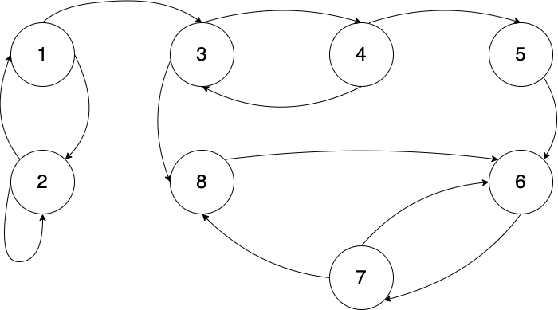

There are 4 classes: $T_1=\{1,2\}$, $T_2=\{3,4\}$, $T_3=\{5\}$ are all transient and $C=\{6,7,8\}$ which is closed.

## 3.3 Decomposition of reducible Markov chains

Markov chain with closed classes $R_1, \cdots R_L$ and transient classes denoted by $T_1, \cdots T_K$ (set $T= T_1 \cup \cdots T_K$). After reordering the states the transition matrix has the block form
$$P\,=\,
\begin{matrix}
R_1 \\ R_2 \\ R_3 \\ \vdots \\ R_L \\ T
\end{matrix}
\begin{pmatrix}
P_1 & & & & &\\
& P_2 & & 0 & &\\
& & P_3 & & & \\
& 0 & & \ddots & &\\
& & & &P_L &\\
& & S & & & Q
\end{pmatrix}
\tag{3.1}$$

where $P_l$ gives the transition probabilities within the class $R_l$, $Q$ the transition within the transient classes and $S\not= 0$ the transition from the transient classes into the closed classes.

It is easy to see that $P^n$ has the form
$$P^n\,=\,
\begin{matrix}
R_1 \\ R_2 \\ R_3 \\ \vdots \\ R_L \\ T
\end{matrix}
\begin{pmatrix}
P_1^n & & & & &\\
& P_2^n & & 0 & &\\
& & P_3^n & & & \\
& 0 & & \ddots & &\\
& & & &P_L^n &\\
& & S_n & & & Q^n
\end{pmatrix}$$
for some matrix $S_n$.

**Example**: Consider the random walk with absorbing boundary conditions (see Example 1.5). There are three classes, 2 closed ones  
$\{0\}$, $\{N\}$ and 1 transient $\{1, \cdots, N-1\}$ for example with $N=5$ we have

$$P\,=\,
\begin{matrix}
0 \\ 5 \\ 1 \\ 2 \\ 3 \\ 4
\end{matrix}
\begin{pmatrix}
1 & 0 & 0 & 0 &0 & 0\\
0 & 1 & 0 & 0 & 0& 0\\
1/2 & 0 & 0 & 1/2 & 0 & 0 \\
0 & 0 & 1/2 & 0 & 1/2 & 0 \\
0 & 0 & 0 & 1/2 & 0 & 1/2\\
0 & 1/2 & 0 & 0 & 1/2 & 0
\end{pmatrix}$$
To get a feel of what’s going on we find (rounded to 4 digit precision)

$$P^{20} = \begin{pmatrix}
1 & 0 & 0 & 0 & 0 & 0 \\
0 & 1 & 0 & 0 & 0 & 0 \\
0.7942 & 0.1953 & 0.004 & 0 & 0.0065 & 0 \\
0.5924 & 0.3907 & 0 & 0.0104 & 0 & 0.0065 \\
0.3907 & 0.5924 & 0.0065 & 0 & 0.0104 & 0 \\
0.1953 & 0.7942 & 0 & 0.0065 & 0 & 0.004 \\
\end{pmatrix}\,, \quad
P^{50}=\begin{pmatrix}
1 & 0 & 0 & 0 & 0 & 0 \\
0 & 1 & 0 & 0 & 0 & 0 \\
0.8 & 0.2 & 0 & 0 & 0 & 0 \\
0.6 & 0.4 & 0 & 0 & 0 & 0 \\
0.4 & 0.6 & 0 & 0 & 0 & 0 \\
0.2 & 0.8 & 0 & 0 & 0 & 0 \\
\end{pmatrix}$$

As expected starting in transient class the Markoveventually exit it to reach here of one the two closed class. From $P^{50}$ one can read that starting in, say state $2$ with probability $.6$ the Markov chain will end up at $0$ and with probability $.4$ the Markov chain will end up in $5$. We will learn how to compute these probability later on but we study first how long it takes to exit the closed class.

## 3.4 Absorption time

- Starting in a closed class $R_l$ the Markov chain stays in $R_l$ forever and its behavior is dictated entirely by the irreducible matrix $P_l$ with state space $R_l$.
- Starting from a transient class the Markov chain will eventually exit the class $T$ and is absorbed into some closed class. One basic question is: **What is the expected time until absorption**?
- We define the **absorption time**
  $$\tau_{\textrm{abs}} = \min\{ n \ge 0 \,;\, X_n \notin T \}$$

**Theorem 3.1 (Expected time until absorption)** Let $j$ be a transient state and let $\tau_{\textrm{abs}}$ to be the time until the Markov chain reaches some closed class. Then we have
$$E[\tau_{abs} |X_0=j] \,=\, \sum_{i\in T} M(j,i) \,.$$
where
$$M=(I-Q)^{-1} = 1 + Q + Q^2 + \cdots$$
and $Q$ is from the decomposition Equation 3.1.

*Proof*. From Lemma 3.1 we know that $Q^n(i,j) \to 0$ and so all eigenvalues of $Q$ have absolute values strictly less than $1$. Therefore $I-Q$ is an invertible matrix and we can define
$$M = (I-Q)^{-1} = I +Q +Q^2 + Q^3 + \cdots$$
The second equality is the geometric series for matrices which follows from the identity
$$(I+ Q + \cdots Q^n)(1-Q) = I -Q^{n+1} \,.$$
To give a probabilistic interpretation to the matrix $M$ we introduce the random variable
$$Y(i) \,=\, \sum_{n=0}^\infty 1_{\{X_n=i\}} \quad = \textrm{ total number of visits to state } i$$
If $i$ is transient by Lemma 3.1 $Y(i) < \infty$ with probability $1$. If $j$ is another transient state we have
$$E[ Y(i) \,\vert\, X_0=j]= \,E\left[ \sum_{n=0}^\infty {\bf 1}_{\{X_n=i\}} \,\vert\, X_0=j\right]
\,=\,\sum_{n=0}^\infty P\left\{ X_n=i \,\vert\, X_0=j\right\}
\,=\,\sum_{n=0}^\infty Q^n(i,j) = M(i,j)$$
That is $M(j,i)$ is simply the expected number of visits to $i$ if $X_0=j$ and thus, summing over all the transient states we obtain
$$E[\tau_{abs} |X_0=j] \,=\, \sum_{i\in T} M(j,i) \,. \quad \blacksquare$$

## 3.5 Hitting time in irreducible Markov chain

- Suppose $X_n$ is irreducible and we are interested in computing the expected time to reach one state from another state that is $E[ \tau(i)| X_0=j] \textrm{ for } j \not= i$.
- If $i=j$ then from Theorem 2.6 that $E[ \tau(i)| X_0=i]=\pi(i)^{-1}$ where $\pi$ is the stationary distribution.
- If $i \not= j$ we use the following idea. Relabel the states so that the first state is $i$ and turn $i$ into an absorbing state
  $$P =
  \begin{pmatrix}
  P(i,i) & R \\ S & Q
  \end{pmatrix}
  \quad \quad \longrightarrow \quad \quad
  \widetilde{P} =
  \begin{pmatrix}
  1 & 0 \\ S & Q
  \end{pmatrix}
  \tag{3.2}$$
  The fact that $P$ is irreducible implies that $S\setminus \{i\}$ is a transient class for the modified transition matrix $\widetilde{P}$. The return time $\tau(i)$ starting from $i\not= j$ for the Markov chain with transition $P$ is exactly the same as the absorption time for the Markov chain with transtion $\widetilde{P}$. Indeed the hitting time does not depend on the submatrix $R$. Therefore from Theorem 3.1 we obtain immediately

**Theorem 3.2 (Expected hitting time in irreducible Markov chain)** Let $X_n$ be an irreducible Markov chain. For $i \not= j$ we
$$E[\tau(i) |X_0=j] \,=\, \sum_{l\in T} M(j,l) \,.$$
where $M=(I-Q)^{-1}$ and $Q$ is given in Equation 3.2 and is obtained by deleting the $i^{th}$ row and $i^{th}$ column from $P$.

## 3.6 Examples

**Example**(continued): Random walk with absorbing boundary conditions on $\{0,1,\cdots,5\}$. We get
$$Q\,=\, \begin{pmatrix}
0 & 1/2 & 0 & 0 \\
1/2 & 0 & 1/2 & 0 \\
0 & 1/2 & 0 & 1/2\\
0 & 0 & 1/2 & 0
\end{pmatrix} \quad \implies
\quad
M=(I-Q)^{-1}
\,=\,
\begin{pmatrix}
1.6 & 1.2 & 0.8 & 0.4 \\
1.2 & 2.4 & 1.6 & 0.8 \\
0.8 & 1.6 & 2.4 & 1.2\\
0.4 & .8 & 1.2 & 1.6
\end{pmatrix}$$
and thus the expected times until absorption are $4$ for states $1$ and $4$ and $6$ for states $2$ and $3$.

**Example**: Random walk with reflecting boundary conditions (see Example 1.5) with $N=5$ and we compute $E[ \tau(0) | X_0=i]$. The stationary distribution is $\pi = \left(\frac{1}{10}, \frac{2}{10}, \frac{2}{10}, \frac{2}{10}, \frac{2}{10}, \frac{1}{10}\right)$ so $E[ \tau(0) | X_0=0]=10$. For $i\not=0$ we delete the first row and column from $P$ and have
$$Q\,=\, \left( \begin{array}{ccccc}
0 & 1/2 & 0 & 0 &0 \\
1/2 & 0 & 1/2 & 0 &0 \\
0 & 1/2 & 0 & 1/2 &0 \\
0 & 0 & 1/2 & 0 &1/2 \\
0 & 0 & 0 & 1 &0
\end{array}
\right) \,,
\quad
M=(I-Q)^{-1}
\,=\, \left( \begin{array}{ccccc}
2 & 2 & 2 & 2 & 1\\
2 & 4 & 4 & 4 &2 \\
2 & 4 & 6 & 6& 3\\
2 & 4 & 6 & 8 & 4 \\
2 & 4 & 6 & 8 & 5
\end{array} \right)$$
and so the expected return times to $1$ are $10, 9, 16, 21, 24, 25$ respectively.

## 3.7 Absorption probabilities

- If $X_0 = i \in T$ belongs to some transient class and if there are more than one closed classes, say $R_1, R_2, \cdots, R_L$ then the Markov may be absorbed in distinct closed class and so we wisht to compute the probabilities
  $$P\{ X_n \,\,\textrm{ reaches class } R_l \,|\, X_0=i \}$$
- Without loss of generality we can assume that each closed class is an absorbing state $r_1, \cdots r_L$ (we can always collapse a closed class into a absorbing state since it does not matter which state in the closed class we first visit). We denote the transient states by $t_1, \cdots, t_M$ and upon reordering the state the transition matrix has the form
  $$P\,=\,
  \begin{matrix}
  r_1 \\ \vdots \\ r_L \\ t_1 \\ \vdots \\ t_M
  \end{matrix}
  \begin{pmatrix}
  & & & & & \\
  & I & & &0& \\
  & & & & & \\
  & & & & & \\
  & S & & &Q & \\
  & & & & & \\
  \end{pmatrix}
  \tag{3.3}$$
- We wish to compute
  $$A( t_i, r_j) = P\{ X_n \, \textrm{ eventually reaches } r_j \,|\, X_0= t_i\}\,.$$
  and it will be convenient to set $A(r_l, r_l)=1$ and $A(r_k, r_l)=0$ if $k\not= l$.

**Theorem 3.3 (Absorption probabilities in closed classes)** For a Markov chain with transition matrix Equation 3.3 where the states $t_1, \cdots t_M$ are transient we have
$$P\{ X_n \, \textrm{ reaches } r_j \,|\, X_0= t_i\} = A(t_i, r_j) \quad \textrm{ with } \quad A = (I -Q)^{-1} S$$

*Proof*. We condition on the first step of the Markov chain to obtain
$$\begin{aligned}
A( t_i, r_j) &= P \left\{ X_n = r_j \textrm{ eventually } \vert X_0= t_i\right\} \\
&= \sum_{k \in S} P \left\{ X_n = r_j \textrm{ eventually}, X_1=k \vert X_0= t_i\right\} \\
&= \sum_{ k \in S} P \left\{ X_1 = k \vert X_0= t_i\right\} P \left\{ X_n = r_j
\text{ eventually } \vert X_1= k\right\} \\
&= \sum_{ k \in S} P(t_i, k) A( k, r_j) \,=\, P(t_i, r_l) + \sum_{ t_k } P(t_i, t_k) A( t_k, r_j) \,.
\end{aligned}$$
If $A$ be the $L \times M$ matrix with entries $A(t_i, r_l)$, then this can be written in matrix form as
$$A \,=\, S + Q A$$
or
$$A \,=\, (I-Q)^{-1} S \,=\, MS \,.$$

Continuing with the random walk example with absorbing boundary conditions, we get
$$A \,=\, MS \,=\,
\left( \begin{array}{cccc}
1.6 & 1.2 & 0.8 & 0.4 \\
1.2 & 2.4 & 1.6 & 0.8 \\
0.8 & 1.6 & 2.4 & 1.2\\
0.4 & .8 & 1.2 & 1.6
\end{array} \right)
\left( \begin{array}{cc} 1/2 & 0 \\ 0 & 0 \\ 0 & 0 \\ 0 & 1/2 \end{array}\right)
\,=\,
\left( \begin{array}{cc} .8 & .2 \\ .6 & .4 \\ .4 & .6 \\ .2 & .8 \end{array}\right)$$
For example from state $2$ the probability to be absorbed in $0$ is $.6$, and so on….

Remark You can apply similar ideas to irreducible Markov chain to compute probabilities like
$$P( \tau(i) \le \tau(j)|X_0=k).$$
that is the probability to return to $i$ before returning to $j$ by transforming $i$ and $j$ into absorbing states. See some examples in that spirit in the homework.

## 3.8 Tennis game

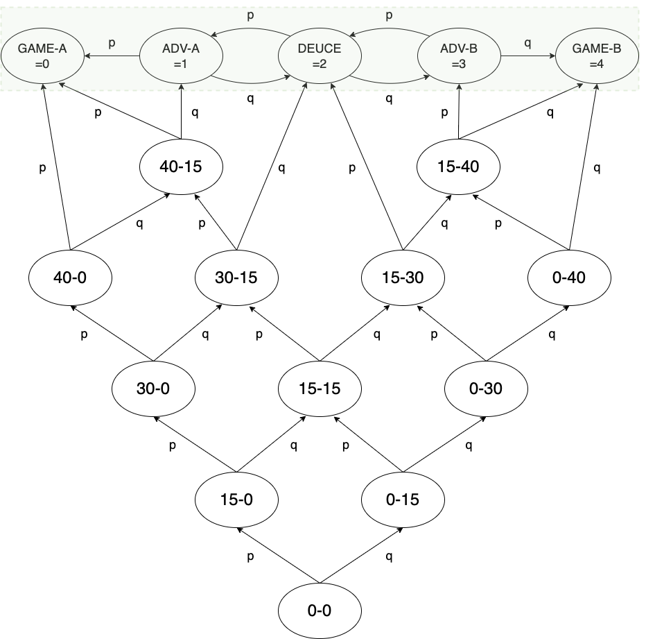

Tennis communication diagram

- The Markov chain “moves up” until it reaches one of the 5 states on the top (which we relabel $0,1,2,3,4$) and the chains stays on those 5 states forever and performs a random walks with absorbing boundary conditions.
- Want the probability that $A$ wins, of course starting from the initial conditions $0-0$. Compute this probability by successive conditioning.
- Consider the events
  $$D_i=\{ X_n \textrm{ reaches the top row in state } i \}$$
- We compute $P(D_i)$ simply by enumerating all the paths leading up to state $i$ starting form the initial state.
- We find then
  $$P(D_0)=p^4 + 4 qp^4\,, \quad
  P(D_1)=4p^3q^2\,, \quad
  P(D_2)= 6p^2q^2\,, \quad
  P(D_3)= 4p^2q^3\,, \quad
  P(D_4)=q^4 + 4 pq^4 \quad$$
- Conditioning on the $B_i$’s: $\displaystyle P(A) =\sum_{i=0}^4 P(A|D_i) P(D_i)$
- Obviously we have $P(A|D_0) =1$ and $P(A|D_4) =0$. By conditioning on the first step we find the system of equations
  $$\begin{aligned}
  P(A|D_1) &= p + q P(A|B_2) & & P(A|D_1) = \frac{p (1-pq)}{1-2pq} \\
  P(A |D_2) &= pP(A |D_1) + q P(A |D_3) & \implies \quad\quad & P(A|D_2) = \frac{p^2}{1-2pq}\\
  P(A |D_3) &= p P(A|D_2) & & P(A|D_3) = \frac{p^3}{1-2pq}
  \end{aligned}$$
- Putting everyting together

$$P(A) = \frac{p^4 (1+2q)(1+4q^2)}{1-2pq}$$
$$p = .54 \implies P(A)=.599$$

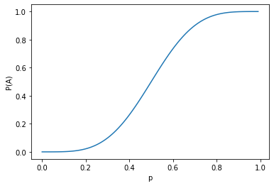

## 3.9 Gambler’s ruin

- A gambler is coming to the casino to play the game of dice called [craps](https://en.wikipedia.org/wiki/Craps). At this game the standard bet (pass line bet) has even money odds and the probability to win is $\frac{244}{495}=0.49292929...$, one of the casino games with best odds.
- Suppose that the player start with a fortune of $j$ and bets $1$ in every game. Their ultimate goal is to reach a fortune of $N$ and, if they do, they would stop. Of course they could lose all their money before reaching their goal.
- The game is described by a random walk on $\{0,1, \cdots, N\}$ with absorbing boundary conditions and we want to compute
  $$\alpha_j = P(X_n \textrm{ reaches } N \textrm{ before reaching } 0| X_0=j)$$
- Conditioning on the first step gives the second order homogeneous linear difference equation
  $$\alpha_j = p \alpha_{j+1} + (1-p) \alpha_{j-1} \quad \textrm{ with boundary conditions } \alpha_0=0\,, \alpha_N=1$$
- To solve this second order homogeneous linear difference equations we look for solutions of the form $\alpha_j=x^j$ which leads to the equation
  $$px^2 - x + (1-p) =0 \quad \implies x_1=1\,, x_2= \frac{1-p}{p}
  \tag{3.4}$$
  This leads to the system of equation (for $p\not= \frac12$)
  $$\alpha_j= C_1 + C_2 \left(\frac{1-p}{p} \right)^j \quad \textrm{ with } \quad \left\{ \begin{array}{r} C_1+C_2=0 \\ C_1 + C_2\left(\frac{1-p}{p} \right)^N=1 \end{array} \right.$$
- Solving gives the **Gambler’s ruin probabilities**
  $$\alpha_j = \frac{ 1 - \left( \frac{1-p}{p} \right)^j }{1 -\left( \frac{1-p}{p} \right)^N} \quad \quad \textrm{ Gambler's ruin for } q\not= p$$
- If $p=\frac{1}{2}$ the quadratic equation Equation 3.4 has a double root $1$ but we note that $\alpha_j= j$ is a second linearly independent solution of $\frac{1}{2}\alpha_{j+1} - \alpha_j + \frac{1}{2}\alpha_{j-1}=0$. Solving the equation $\alpha_j= C_1 + C_2j$ with the boundary conditions gives
  $$\alpha(j) \,=\, \frac{j}{N} \quad \quad \textrm{ Gambler's ruin for } p=\frac{1}{2}$$
- **How bad does it get?**:For example if $p=\frac{244}{495}$ and you start with a fortune a 50 and want to double it, the probability to succeed is $\frac{ 1 - \left( \frac{251}{244}\right)^{50}}{1 -\left(\frac{251}{244}\right)^{100}}=.1955$, not so great. You could also be more risky and bet an amount of 10 in which case you probability to succeed i a much better $\frac{ 1 - \left( \frac{251}{244}\right)^{5}}{1 -\left(\frac{251}{244}\right)^{10}}=.4647$. Even better bet everything and your probability to win is $p=.4929$. (In casino boldness pays, or loses less).
- **Limiting cases** To get a better handle on the gambler’s ruin formula we slightly rephrase the problem:
  - We start at $0$.
  - We stop whenever we reach $W$ ($W$ is the desired gain) 0r when we reach $-L$ ($L$ is the acceptable losss).
  - The state are now $j \in \left\{ -L, -L+1, \cdots, \cdots, W-1, W\right\}$

  We get
  $$P(-L, W)\,\equiv\, P\left( \text{Reach}W{\rm~before~reaching~} - L {\text{ ~starting~from~}}0 \right) \,=\, \frac{1 - \left( \frac{1-p}{p} \right)^L}{1 - \left( \frac{1-p}{p} \right)^{L+W}} \,.$$
- The limit $L \to \infty$ describes a player with infinite wealth:
  $$P(-\infty,L)= \left\{\begin{array}{cl}1 & \text{ if } p> \frac12 \\ \left(\frac{p}{1-p}\right)^W & \text{ if } p< \frac12 \end{array} \right.$$
  Even with infinite wealth it is exponentially hard to win $W$!
- The limit $W \to \infty$ describes a player with fortune $L$ who does not stops unless they lose.
  $$P(-L,\infty) \,=\, \left\{\begin{array}{cl} 1 - \left(\frac{1-p}{p}\right)^L & \text{ if } p > \frac{1}{2}
  \\ 0 & \text{ if } p < \frac{1}{2} \end{array} \right.$$
  The probability to play forever is, unsurprisingly, $0$.

## 3.10 Exercises

**Exercise 3.1** Consider a Markov chain with state space $\{0,\cdots,5\}$ and transition matrix
$$P\,=\, \left( \begin{array}{cccccc}
.5 & .5 & 0 & 0 & 0 & 0 \\
.3 & .7 & 0 & 0 & 0 & 0 \\
0 & 0 & .1& 0 & .9& 0 \\
.25& .25& 0 & 0 &.25&.25 \\
0 & 0 & .7& 0 & .3& 0 \\
0 & .2 & 0 & .2 & .2 & .4 \\
\end{array} \right) \,.$$

1. What are the communication classes. Which ones are closed and which ones are transient?
2. Suppose $X_0=5$. What is the probability that $X_n$ visits the state $1$ before the state $4$?
3. Suppose $X_0=5$. Compute $\lim_{n \to \infty} P^n(5, j)$ for all j?

**Solution**

1. After running the code in Exercise 3.9 we find that

```
Canonical Form Transition Matrix:
[[0.5  0.5  0.   0.   0.   0.  ]
 [0.3  0.7  0.   0.   0.   0.  ]
 [0.   0.   0.1  0.9  0.   0.  ]
 [0.   0.   0.7  0.3  0.   0.  ]
 [0.25 0.25 0.   0.25 0.   0.25]
 [0.   0.2  0.   0.2  0.2  0.4 ]]

Submatrix Q (Transient to Transient):
[[0.   0.25]
 [0.2  0.4 ]]

Submatrix R (Transient to Recurrent):
[[0.25 0.25 0.   0.25]
 [0.   0.2  0.   0.2 ]]

Identity Matrix for Recurrent States:
[[1. 0. 0. 0.]
 [0. 1. 0. 0.]
 [0. 0. 1. 0.]
 [0. 0. 0. 1.]]

Communication Classes:
([0, 1], 'Recurrent')
([2, 4], 'Recurrent')
([3, 5], 'Transient')
```

2. Starting from 5 the chain will visit 1 before 4 if gets absorbed in the class $\{0,1\}$ before getting absorbed in the class $\{2,4\}$ so we need to compute the matrix (after collapsing the recurrent classes to absorbing states)
   $$A = (I-Q)^{-1}S =
   \left(I - \begin{pmatrix}
   0 & 0.25 \\
   0.2 & 0.4
   \end{pmatrix}\right)^{-1} \begin{pmatrix}
   .5 & .25 \\
   .2 & .2
   \end{pmatrix}$$

```
Matrix A:
 [[0.63636364 0.36363636]
 [0.54545455 0.45454545]]
```

So the Markov chain will visit 1 before 4 with probability $\frac{6}{11}$.

3. Starting from $5$ the chain will be absorbed in the class $\{0,1\}$ with probability $6/11$ and in the class $\{2,4\}$ with probability $5/11$. Once it is in a recurrent class it will stay there forever and it future will be governed by the stationary distribution of the Markov chain of that recurrent class. We have
   $$\pi_{\{0,1 \}}= \left(\frac{3}{8}, \frac{5}{8} \right)\, \quad \pi_{\{2,4 \}}= \left(\frac{7}{16}, \frac{9}{16} \right)$$
   For example we find $\lim_{n \to \infty} P^n(5,4) = \frac{5}{11} \times \frac{9}{16}$.

**Exercise 3.2** Suppose we flip a fair coin repeatedly until we have flipped four consecutive heads. What is the expected number of flips that are needed?  
*Hint*: Build up a suitable Markov chain with state space $\{0,1,2,3,4\}$

**Solution**

Flip a coin repeatedly and we say $X_n=k$ the $k$ last flips (that is flips $n, n-1, \cdots, n-k+1$ were heads and the flip $n-k$ was a tail). Clearly it is a Markov chain since $X_{n+1}$ is a function of $X_n$ and a random variable $B_{n+1}$ which describe the $n=1$ flips. To study the problem at hand we turn $4$ into an absorbing state and take the initial condition to be $X_0=0$. The transition matrix is
$$\begin{pmatrix}
1/2 & 1/2 & 0 & 0 & 0 \\
1/2 & 0 & 1/2 & 0 & 0 \\
1/2 & 0 & 0 & 1/2 & 0 \\
1/2 & 0 & 0 & 0 & 1/2 \\
0 & 0 & 0 & 0 & 1
\end{pmatrix}$$
To find the absorption time we compute
$$M=(I-Q)^{-1} =\left( I - \begin{pmatrix}
1/2 & 1/2 & 0 & 0 \\
1/2 & 0 & 1/2 & 0 \\
1/2 & 0 & 0 & 1/2 \\
1/2 & 0 & 0 & 0 &
\end{pmatrix} \right)^{-1}$$

```python
import numpy as np

# Define the matrix Q
Q = np.array([
    [1/2, 1/2, 0, 0],
    [1/2, 0, 1/2, 0],
    [1/2, 0, 0, 1/2],
    [1/2, 0, 0, 0]
])

# Compute I - Q
I = np.eye(Q.shape[0])  # Identity matrix of the same size as Q
I_minus_Q = I - Q

# Compute the inverse of (I - Q)
try:
    inverse_matrix = np.linalg.inv(I_minus_Q)
    print("Inverse of (I - Q):\n", inverse_matrix)
except np.linalg.LinAlgError:
    print("Matrix (I - Q) is singular and cannot be inverted.")
```

```
Inverse of (I - Q):
 [[16.  8.  4.  2.]
 [14.  8.  4.  2.]
 [12.  6.  4.  2.]
 [ 8.  4.  2.  2.]]
```

and therefore it will take an average of $30$ flips to get four heads in a row.

**Exercise 3.3** Consider the Markov chain with state space $\{0, \cdots, 6\}$ and transition matrix
$$P\,=\, \left( \begin{array}{ccccccc}
\frac34 & \frac14 & 0 & 0 & 0 & 0 &0\\
\frac12 & \frac14 & \frac14 & 0 & 0 & 0&0 \\
\frac14 & \frac14 & \frac14& \frac14 & 0& 0 &0\\
\frac14& 0&\frac14 &\frac14 &\frac14&0&0 \\
\frac14 & 0 & 0& \frac14 & \frac14& \frac14 &0 \\
\frac14 & 0 & 0 & 0 & \frac14 & \frac14 &\frac14\\
\frac14 & 0 & 0 & 0 & 0 & \frac14 &\frac12\\
\end{array} \right) \,.$$

1. Is this chain irreducible? Aperiodic?
2. Suppose the chain starts in state 1. What is the probability it reaches state 6 before reaching state $0$?
3. Suppose the chain starts in state 3. What is the expected number of steps until it reaches $3$ again?
4. Suppose the chain starts in state 0. What is the expected number of steps until it reaches state $6$?

**Exercise 3.4 (Random walk on the complete graph)** The complete graph with vertex sets $\{1, \cdots, N\}$ is the graph such that any two vertex are joined by an edge. Let $X_n$ be the simple random walk on this graph.

1. Let $\tau{(1)}$ be the first time the chain returns to state $1$. Compute the p.d.f of $\tau{(1)}$ conditioned on $X_0=1$. Use this to compute $E[ \tau{(1)}| X_0=1]$.
2. Compute $E[ \tau{(1)}| X_0=2]$
3. Find the expected number of steps $T_N$ until every one of the $N$ state has been visited at least once.  
   *Hint*: Let $T_k$ be the time until $k$ distinct states have been visited at least once. Compute first $E[T_k - T_{k-1}]$.

**Solution**

The transition matrix is simply $P(i,j)=\frac{1}{N-1}$ for $i \not= j$.

1. Suppose $X_0=1$ then $X_1$ will be any in any of theer states with equal probability and so $P(\tau(1)=1|X_0=1)=0$.

If $X_2=j$ with $j\not=1$, then $X_3=1$ with probability $\frac{1}{N-1}$ (and hence $\tau(1)=2$) and $X_3 \not= 1$ with probability $\frac{N-2}{N-1}$ and so on… Therefore we find
$$P(\tau(1)=n|X_0=1)= \left(\frac{N-2}{N-1}\right)^{n-2}\frac{1}{N-1}$$
We see that $\tau(1)$ conidtioned on $X_0=1$ has the same distribution as $1+ X$ where $X$ is a geometric random variables with parameter $p=\frac{1}{N-1}$. Therefore $E[\tau(1)|X_0=1]= 1 + \frac{1}{p} = N$.

This is course to be expected since the matrix is symmetric and so the stationary distribution is uniform and so Kac’s formula would give that result immediately.

2. Arguing as in $1$ we find that
   $$P(\tau(1)=n|X_0=2)= \left(\frac{N-2}{N-1}\right)^{n-1}\frac{1}{N-1}$$
   which is a geometric random variable and so $E[\tau(1)|X_0=2]= N-1$.
3. This problem is a slight variation of the coupon collecting problem. The Markov chain will visit two different states in the first two moves. So $T_1=1$ and $T_2=2$. Now $T_3-T_2$ is geometric with probability $\frac{N-2}{N-1}$ and so on. We find
   $$E[T] = 2 + \frac{N-1}{N-2} + \cdots + N-1 = 2+(N-1)\left(1 + \frac{1}{2} + \cdots + \frac{1}{N-2}\right)$$

**Exercise 3.5** Every night Bob and Catherine go out to one of three bar $A$, $B$, or $C$. For each of Bob and Catherine their visits to bars are independent of each other and are governed by Markov chains with the same transition probabilities.
$$P\,=\,
\begin{matrix}
A\\B\\C
\end{matrix}
\begin{pmatrix}
1/2 & 1/4 & 1/4 \\
1/4 &1/4 & 1/2 \\
0 & 1/2 & 1/2 \\
\end{pmatrix}$$
Let us denote $X_n$ and $Y_n$ the bar visited by Bob and Catherine respectively on day $n$ and let us suppose that $X_0= A$ and $Y_0=C$ and let $T$ denote the first day when Bob and Catherine are in the same bar:
$$T= \min\{ n \,;\, X_n = Y_n \}$$

1. Find $E[T]$.
2. What is the probability they first meet in bar $C$, i.e. compute $P(X_T=C)$.
3. In the long run what is the proportion of time they spend in the same bar.

*Hint:* You should consider the $9$ state Markov chain $Z_n = (X_n,Y_n)$.

**Solution**

If $X_n$ and $Y_n$ are independent Markov chain with transition $P(i,j)$ and $Q(k,l)$ then $Z_n=(X_n,Y_n)$ is a Markov chain with transition $P((i,k),(j,l))=P(i,j)Q(k,l)$. This is called the Kronecker product (or tensor product) of the product matrix $P \otimes Q$ and is a $nm \times nm$ matrix if $P$ has $n$ states and $Q$has $m$ states. The stationary distribution is $\pi((i,j))=\pi_P(i) \pi_Q(j)$, if it exists.

We can answer the questions immediately from the Markov chain $Z$ with transition $P \otimes Q$.

After multiplying the matrix, changing the states $(A,A),(B,B),(C,C)$ into absorbing states reoerdering the states we find
$$\begin{matrix}
AA \\ BB \\ CC \\ AB \\ AC \\BA \\BC \\CA \\ CB
\end{matrix}
\begin{pmatrix}
1 & 0 & 0 & 0 & 0 & 0 & 0 & 0 & 0 \\
0 & 1 & 0 & 0 & 0 & 0 & 0 & 0 & 0 \\
0 & 0 & 1 & 0 & 0 & 0 & 0 & 0 & 0 \\
0.125 & 0.0625 & 0.125 & 0.125 & 0.25 & 0.0625 & 0.125 & 0.0625 & 0.0625 \\
0 & 0.125 & 0.125 & 0.25 & 0.25 & 0 & 0.125 & 0 & 0.125 \\
0.125 & 0.0625 & 0.125 & 0.0625 & 0.0625 & 0.125 & 0.0625 & 0.25 & 0.125 \\
0 & 0.125 & 0.25 & 0.125 & 0.125 & 0 & 0.125 & 0 & 0.25 \\
0 & 0.125 & 0.125 & 0 & 0 & 0.25 & 0.125 & 0.25 & 0.125 \\
0 & 0.125 & 0.25 & 0 & 0 & 0.125 & 0.25 & 0.125 & 0.125
\end{pmatrix}$$
This gives the fundamental matrix
$$M=(I-Q)^{-1} =
\begin{bmatrix}
1.3775 & 0.5497 & 0.2225 & 0.4321 & 0.2503 & 0.3679 \\
0.5354 & 1.6023 & 0.1503 & 0.4678 & 0.1691 & 0.4464 \\
0.2225 & 0.2503 & 1.3775 & 0.3679 & 0.5497 & 0.4321 \\
0.3141 & 0.3534 & 0.1430 & 1.4206 & 0.1609 & 0.5222 \\
0.1503 & 0.1691 & 0.5354 & 0.4464 & 1.6023 & 0.4678 \\
0.1430 & 0.1609 & 0.3141 & 0.5222 & 0.3534 & 1.4206
\end{bmatrix}$$
and the sum of the second row is $3.37$ which gives the expected time until meeting. To find the probability they first meet in $C$ we have
$$A=MS = \begin{bmatrix}
0.2 & 0.3 & 0.5 \\
0.0857 & 0.3786 & 0.5357 \\
0.2 & 0.3 & 0.5 \\
0.0571 & 0.3357 & 0.6071 \\
0.0857 & 0.3786 & 0.5357 \\
0.0571 & 0.3357 & 0.6071
\end{bmatrix}$$
and so they will first meet in C with probability $0.5357$.

In the long run the time spent in the same bar is $\pi(A)^2 +\pi(B)^2 + \pi(C)^2 = \left(\frac{2}{11}\right)^2 + \left(\frac{4}{11}\right)^2 \left(\frac{5}{11}\right)^2$

**Exercise 3.6** You can use absorbing state to compute *tabu probabilities*, i.e. probabilities of reaching some given state while avoiding some other states. For example the weather in the island of H is either 1=sunny, 2=cloudy, or 3=rainy and evolve according to a Markov chain with transition probabilties
$$P\,=\,
\begin{matrix}
1\\2\\3
\end{matrix}
\begin{pmatrix}
0.70 & 0.10 & 0.20 \\
0.50 & 0.25 & 0.25 \\
0.40 & 0.30 & 0.30 \\
\end{pmatrix}$$

1. Compute the probability that there is no rain in the next five days given that it is sunny today.  
   *Hint* Consider the transition matrix $\tilde P$ where $3$ is transformed into an absorbing state.
2. Compute the probability that there is no rain in the next five days given that it is rainy today.  
   *Hint*: Condition first on tomorrow’s weather and use $\tilde P$

**Exercise 3.7 (Free casino money)** You highschool friend W. B. now owns a casino in Macao. He is so happy to see you again that he gives you infinite credit at a table of craps to play the “pass line bet” which is an even money bet with probability of winning equal to 244/495. The maximal allowed bet is $ 1,000. What is the expected size of the present your friend is giving you?

**Exercise 3.8 (Roger Federer)** In his commencement speech in Dartmouth college the swiss tennisman Roger Federer stated “I won almost 80% of singles matches… But I only won 54% of points. Even top ranked tennis players win barely more than half the points they play.” (see the speech at [here](https://www.youtube.com/watch?v=LnfOJDZm-9U)). Continue the analysis of tennis we started in Section 3.8 where we computed the probability to win a “game”. A tennis match is played in five sets (best of five, the player who first wins three sets wins the match). A set is won when a player wins 6 games and two games ahead. If the scores reaches 6-5 then there are 2 possibilites. In the tie-break method when a score of 6-5 occurs then a plyer can win 7-5 or of if it reaches 6-6 a tie-break ensue. In the advantage set method games are played until until one player is to games ahead (Famously in in 2010 a set see [here](https://en.wikipedia.org/wiki/Isner%E2%80%93Mahut_match_at_the_2010_Wimbledon_Championships%3E) ended with the score 70–68 and lasted more than 6 hours. Details for the scoring rules are in https://en.wikipedia.org/wiki/Tennis_scoring_system.

*Hint*: Using the negative binomial distribution will be helpful.

Is the statement of Roger Federer consistent with our model?

**Solution**

It is useful first consider the “playoff problem”. In the $n$-playoff problem you play a series a game until one team has accumulated $n$ victory. For example in NBA the playoff is best of seven, that is you play until a team has accumulated $4$ wins, this is a $4$-playoff in our notation. To analyze the game tennis we will need the formula for various value of $n$: in a $n$- playoff where all game are independent and Roger win each round with probability $p$, then Roger will win the playoff with probability

$$P(\text{win a $n$-playoff}) = \underbrace{p^n}_{\text{win } n \text{ to } 0} + \underbrace{{n \choose 1} p^nq}_{\text{win } n \text{ to } 1} + \underbrace{{n+1 \choose 2}p^nq^2}_{\text{win } n \text{ to } 2} + \cdots + \cdots \underbrace{{2n-2 \choose n-1}p^nq^{n-1}}_{\text{win } n \text{ to } n-1}$$
For example to win $n$ to $2$ you will play $n+2$ games, and win $n$ of them. The last one must be a win and 2 out of the n+1 first games are losses, hence the binomial factor ${n+1 \choose 2}$ which accounts for the different way your lossse can occur.

Since a tennis match is played in $5$ sets, this is a $3$-playoff. If the probability to win a single set is $p_{\text{set}}$ then the probbaility to win the match will be
$$P(\text{win a match}) = p_{\text{set}}^3 + {3 \choose 1} p_{\text{set}}^3 q_{\text{set}} + {4 \choose 2} p_{\text{set}}^3 q_{\text{set}}^2$$

Let us now analyze what happens during a single set. The probability to win a game is $p_{game}$ (computed already in Section 3.8). The set will end up whenever one of the player reach $6-0$, $6-1$, $6-2$, $6-3$ or $6-4$ and we can compute arguing as in the $n$=playoff formula. If the game reach $6-5$ or $5-6$ however the rules are a bitt different. After a score $6-5$, for eexample, the next game will played will lead to $7-5$ if the fist player win and to $6-6$ if the scond player wins. The score of $6-6$ leads to a tie-break which is won with a probability $p_{tiebreak}$ which we will analyze later on. Putting all together we find that the probability that the first player win a set is

$$\begin{aligned}
P(\text{win a set}) & = p_{\text{game}}^6 + {6 \choose 1} p_{\text{game}}^6q_{\text{game}} + {7 \choose 2} p_{\text{game}}^6q_{\text{game}}^2 + {8 \choose 3} p_{\text{game}}^6q_{\text{game}}^3 + {9 \choose 4} p_{\text{game}}^6q_{\text{game}}^4 \\
& + {10 \choose 5} p_{\text{game}}^6q_{\text{game}}^5 ( p_{\text{game}} + q_{\text{game}} p_{\text{tiebreak}} ) + {10 \choose 5} p_{\text{game}}^5q_{\text{game}}^6 ( p_{\text{game}} p_{\text{tiebreak}} )
\end{aligned}$$

Finally we analyze the probability to win a tie-break. Recall that to win a tie break you must win at least $7$ points and have at least two points more than your opponent. So you can win by reaching $7-0$, $7-1$, $\cdots$ $7-5$. However if you reach the score of $6-6$, you will now play points until one the player has two more points than his oppenent. This is exactly a gambler’s ruin with starting with a fortune of $j=2$ and wanting to reach a fortune of $N=4$
$$P(\text{win tiebreak}|6-6) = \frac{1- \left(\frac{ q_{\text{point}} }{p_{\text{point}}} \right)^2 }{1- \left(\frac{q_{\text{point}}}{p_{\text{point}}}\right)^4}$$

So putting this altogether we find
$$\begin{aligned}
P(\text{win tiebreak}) & = p_{\text{point}}^7 + {7 \choose 1} p_{\text{point}}^7 q_{\text{point}} + {8 \choose 2} p_{\text{point}}^7q_{\text{point}}^2 + {9 \choose 3} p_{\text{point}}^7 q_{\text{point}}^3 + {10 \choose 4} p_{\text{point}}^7q_{\text{point}}^4 \\
& + {11 \choose 5} p_{\text{point}}^7q_{\text{point}}^5 + {12 \choose 6} p_{\text{point}}^6 q_{\text{point}}^6 \frac{1- \left(\frac{ q_{\text{point}} }{p_{\text{point}}} \right)^2 }{1- \left(\frac{q_{\text{point}}}{p_{\text{point}}}\right)^4}
\end{aligned}$$

```python
import numpy as np
from scipy.special import comb

def p_match(p_point):
  """
  Args:
      arg1: prob_point is the probability that player A wins any given point.

  Returns:
      prob_game is the probability that player A wins a game, assuming all point are
      independent
      prob_set is the probability that player A wins a set, assuming all points are
      independent and we follow the tie break rule
      prob_match is the probability that player A wins a match (played in 5 sets).
  """
  q_point=1-p_point

  p_game = ((p_point**4)*(1+ 2*(q_point))*(1+4*q_point**2))/(1-2*p_point*q_point)

  q_game = 1-p_game

  p_tiebreak = (p_point**7 +
            comb(7, 1) * p_point**7 * q_point +
            comb(8, 2) * p_point**7 * q_point**2 +
            comb(9, 3) * p_point**7 * q_point**3 +
            comb(10, 4) * p_point**7 * q_point**4 +
            comb(11, 5) * p_point**7 * q_point**5 +
            comb(12, 6) * p_point**6 * q_point**6 *
            (1 - (q_point / p_point)**2) / (1 - (q_point / p_point)**4))

  p_set= (p_game**6 +
       comb(6, 1) * p_game**6 * q_game +
       comb(7, 2) * p_game**6 * q_game**2 +
       comb(8, 3) * p_game**6 * q_game**3 +
       comb(9, 4) * p_game**6 * q_game**4 +
       comb(10, 5) * p_game**6 * q_game**5 * (p_game + q_game * p_tiebreak) +
       comb(10, 5) * p_game**5 * q_game**6 * (p_game * p_tiebreak))

  q_set =1-p_set

  p_match = ( p_set**3 +
          comb(3,1) * p_set**3 * q_set +
          comb(4,2) * p_set**3 * q_set**2)


  return (p_game, p_set, p_match)


p_point =.53

p_match(p_point)

print(f"Probability of winning a point: {p_point:.4f}")
print(f"Probability of winning a game: {p_match(p_point)[0]:.4f}")
print(f"Probability of winning a set: {p_match(p_point)[1]:.4f}")
print(f"Probability of winning a match: {p_match(p_point)[2]:.4f}")
```

```
Probability of winning a point: 0.5300
Probability of winning a game: 0.5746
Probability of winning a set: 0.7047
Probability of winning a match: 0.8431
```

**Exercise 3.9 (Computer exercise)**

- Write a code which take a Markov chain and returns in canonical form.
- Add to the previous code the computation of the time until absorption and the absorption probabilities.

**Solution**

After a bit of gentle prodding Chat GPT returned me the following code. The idea is to associated a directed graph to a transition matrix. The coommunication classes are the strongly connected component of this directed graph.

```python
import numpy as np
from scipy.sparse.csgraph import connected_components
from scipy.sparse import csr_matrix

def markov_chain_decomposition(P):
    """
    Decomposes a Markov chain into communication classes, identifies them as recurrent or transient,
    and returns the transition matrix in canonical form with recurrent states first.

    Parameters:
        P (numpy.ndarray): Transition probability matrix of the Markov chain.

    Returns:
        canonical_P (numpy.ndarray): Transition matrix in canonical form.
        Q (numpy.ndarray): Submatrix of transitions among transient states.
        R (numpy.ndarray): Submatrix of transitions from transient to recurrent states.
        I (numpy.ndarray): Identity matrix for recurrent states.
        class_info (list): List of communication classes with their classification (recurrent/transient).
    """
    n = P.shape[0]
    adjacency_matrix = (P > 0).astype(int)

    # Find strongly connected components
    n_components, labels = connected_components(csgraph=csr_matrix(adjacency_matrix), directed=True, connection='strong')

    # Group states into communication classes
    classes = [[] for _ in range(n_components)]
    for state, label in enumerate(labels):
        classes[label].append(state)

    # Identify recurrent and transient classes
    recurrent_classes = set()
    for class_states in classes:
        submatrix = P[np.ix_(class_states, class_states)]
        if np.all(np.sum(submatrix, axis=1) == 1):
            recurrent_classes.add(tuple(class_states))

    class_info = [(c, 'Recurrent' if tuple(c) in recurrent_classes else 'Transient') for c in classes]

    # Canonical form: reorder recurrent states first, then transient states
    recurrent_states = [s for c in classes if tuple(c) in recurrent_classes for s in c]
    transient_states = [s for c in classes if tuple(c) not in recurrent_classes for s in c]
    new_order = recurrent_states + transient_states
    canonical_P = P[np.ix_(new_order, new_order)]

    # Extract submatrices
    num_recurrent = len(recurrent_states)
    Q = canonical_P[num_recurrent:, num_recurrent:]  # Transient to transient
    R = canonical_P[num_recurrent:, :num_recurrent]  # Transient to recurrent
    I = np.eye(num_recurrent) if num_recurrent > 0 else np.array([])  # Identity for recurrent states

    return canonical_P, Q, R, I, class_info

# Example usage:
P = np.array([
    [0.5, 0.5, 0, 0, 0, 0, 0],
    [0.2, 0.3, 0.5, 0, 0, 0, 0],
    [0, 0.2, 0.3, 0.5, 0, 0, 0],
    [0, 0, 0, 0.5, 0.5, 0, 0],
    [0, 0, 0, 0, 1, 0, 0],
    [0, 0, 0, 0, 0, 0.6, 0.4],
    [0, 0, 0, 0, 0, 0.3, 0.7]
])

canonical_P, Q, R, I, class_info = markov_chain_decomposition(P)
print("Canonical Form Transition Matrix:")
print(canonical_P)
print("\nSubmatrix Q (Transient to Transient):")
print(Q)
print("\nSubmatrix R (Transient to Recurrent):")
print(R)
print("\nIdentity Matrix for Recurrent States:")
print(I)
print("\nCommunication Classes:")
for c in class_info:
    print(c)
```

```
Canonical Form Transition Matrix:
[[1.  0.  0.  0.  0.  0.  0. ]
 [0.  0.6 0.4 0.  0.  0.  0. ]
 [0.  0.3 0.7 0.  0.  0.  0. ]
 [0.5 0.  0.  0.5 0.  0.  0. ]
 [0.  0.  0.  0.  0.5 0.5 0. ]
 [0.  0.  0.  0.  0.2 0.3 0.5]
 [0.  0.  0.  0.5 0.  0.2 0.3]]

Submatrix Q (Transient to Transient):
[[0.5 0.  0.  0. ]
 [0.  0.5 0.5 0. ]
 [0.  0.2 0.3 0.5]
 [0.5 0.  0.2 0.3]]

Submatrix R (Transient to Recurrent):
[[0.5 0.  0. ]
 [0.  0.  0. ]
 [0.  0.  0. ]
 [0.  0.  0. ]]

Identity Matrix for Recurrent States:
[[1. 0. 0.]
 [0. 1. 0.]
 [0. 0. 1.]]

Communication Classes:
([4], 'Recurrent')
([3], 'Transient')
([0, 1, 2], 'Transient')
([5, 6], 'Recurrent')
```

# 4 Markov chains with countable state space

## 4.1 Examples

We introduce some basic examples of Markov chains on a countable state space

**Example 4.1 (Random walk on the non-negative integers)** Let us consider a random walk on the set of nonnegative integers with partially reflecting boundary conditions at $0$. The transition probabilities are given by
$$\begin{matrix}
0 \\ 1 \\ 2 \\ \vdots
\end{matrix}
\begin{pmatrix}
q & p & 0 &0 & 0 &\ldots \\
q & 0 & p &0 & 0 &\ldots \\
0 & q & 0 & p & 0& \ldots \\
\vdots & \vdots & \ddots & \ddots & \ddots& \\
\end{pmatrix}
\quad \quad \textrm{ with } q=1-p$$

**Example 4.2 (Discrete-time queueing model)** At a service station (think of a cash register), during each time period there is a probability $p$ that an additional customer comes in the queue. The first person in the queue is being served and during each time period there is a probability $q$ that this person exits the queue.

We denote by $X_n$ the number of people in the queue (either in being served or waiting in line). The state space is $S = \{ 0,1,2,3, \cdots \}$ and the transition probabilities are given by
$$P\,=\,
\begin{matrix}
0\\1\\2\\ \vdots
\end{matrix}
\begin{pmatrix}
1-p & p & 0 &0 & \ldots \\
q(1-p) & qp + (1-p)(1-q) & p(1-q) &0 & \ldots \\
0 & q(1-p) & qp + (1-p)(1-q) & p(1-q) & \\
\vdots& \vdots & \ddots & \ddots & \ddots & \\
\end{pmatrix}$$

**Example 4.3 (Repair shop)** A repair shop is able to repair one item on any single day. On day $n$ $Z_n$ items break down and are brought for repair to the repair shop and we assume that $Z_n$ are IID random variables with pdf $P\{ Z_n = k\} = a_k$ for $k=0,1,2, \cdots$. If $X_n$ denotes the number of item in the shop waiting to be repaired we have
$$X_{n+1} = \max \{ (X_n -1), 0 \} + Z_n$$
The state space is $S = \{ 0,1,2,3, \cdots \}$ and the transition probabilities are
$$P\,=\,
\begin{matrix}
0\\1\\2 \\ \vdots
\end{matrix}
\begin{pmatrix}
a_0 & a_1 & a_2 & a_3 & \cdots \\
a_0 & a_1 & a_2 & a_3 & \cdots \\
0 & a_0 & a_1 & a_2 & \cdots \\
\vdots & \vdots & \vdots & \vdots &
\end{pmatrix}
\quad \quad
\textrm{ with } \sum_{k=0}^\infty a_k =1$$

**Example 4.4 (Success run chain)** Imagine a player taking a series of bets labelled $0,1,2, \cdots$. The probability to win bet $j$ is $p_j$. If the player wins bet $j$ they move up to bet $j+1$ but if they lose they move back to bet $0$. If $X_n$ denotes the number of successive winning bets then $X_n$ has state space $S = \{ 0,1,2,3, \cdots \}$ and transition probabilities
$$P\,=\,
\begin{matrix}
0\\1\\2 \\ \vdots
\end{matrix}
\begin{pmatrix}
q_0 & p_0 & 0 &0 & \ldots \\
q_1 & 0 & p_1 &0 & \ldots \\
q_2 & 0 & 0 & p_2 & \\
\vdots & \vdots & & \ddots & \ddots \\
\end{pmatrix}
\quad \quad \textrm{ with } q_i=1-p_i$$
This Markov chain has allows for nice analytical computations.

**Example 4.5 (Simple d-dimensional random walk)** The state space $S$ of the Markov chain is the d-dimensional lattice $\mathbb{Z}^d$. We denote by ${\bf e}_i$, $i=1, \cdots, d$ the standard orthonormal basis in $\mathbb{R}^d$. We view $\mathbb{Z}^d$ as the vertex set of a graph and any point ${\bf x=(x_1, \cdots, x_d)}$ is connected by edges to $2d$ neighbors ${\bf x} \pm {\bf e}_i$. For the simple random walk we have
$$p({\bf x}, {\bf x} \pm {\bf e}_i) \,=\, \frac{1}{2d}$$
and all the others $p({\bf x},{\bf y})=0$.

**Example 4.6 (Branching process)** The branching process, also known as the *Galton-Watson process* model the evolution over time of populations.
In a unit of time every individual in a population dies and leave behind a random number of descendents.
To describe the Markov chain we will use IID random variables $Z_n^{(k)}$ indexed by $n=0,1,2\cdots$ and $k=0,1,2,\cdots$.
The branching process is given by
$$X_{n+1} \,=\, \sum_{k=1}^{X_n} Z_n^{(k)}$$
which simply says that the each of $X_n$ individuals in the population at time $n$ has a random number $Z_n^{(k)}$ of descendents. It is not convenient to write down the transition probabilities but we will study this process later using its moment generating function.

## 4.2 Transience/recurrence dichotomy

In Markov chains on a countable state space a new phenomenon occurs compared to finite state space. Suppose the the Markov chain is irreducible (or starts in a closed class), from a state $i$ the Markov chain will return to $i$ with positive probaility but it is also possible that the Markov chain does not return to $i$ and “wander away to infinity”.

We introduce the corresponding definitions of transience and recurrence of a state. Recall that the return time to state $i$ is given by
$$\tau(i) = \min \{ n \ge 1 \,;\, X_n =i \}\,. \quad (\text{return time})$$

**Definition 4.1 (recurrent and transient state)**

- A **state $i$ is recurrent** if if the Markov chain starting in $i$ will eventually return to $i$ with probability $1$, i.e. if
  $$P \left\{ \tau(i) < \infty |X_0=i \right\} = 1 .$$
- A **state $i$ is transient** if it is not recurrent, that is starting in $i$ the Markov chain return to $i$ with probability $q<1$, i.e., if
  $$P \left\{ \tau(i)< \infty |X_0=i \right\} = q < 1 .$$

Recall also the random variable $Y(i)$ which counts the number of visits to state $j$:
$$Y(i) = \sum_{k=0}^\infty I_{\{X_k=i\}} \quad \textrm{ with expectation } \quad E[Y(i)|X_0=j] = \sum_{n=0}^\infty P^n(j,i)$$

**Theorem 4.1 (Transience/recurrence dichotomy)**

1. A state $i$ is recurrent $\displaystyle \iff P\{ Y(i)=\infty | X_0=i \}=1 \iff \sum_{n=0}^\infty P^{n}(i,i) = \infty$.
   Moreover if $i$ is recurrent and $i \leftrightsquigarrow j$ then $j$ is recurrent and we have
   $$\sum_{n=0}^\infty P^n(i,j) = \infty \quad \text{ and } \quad
   P \left\{ \tau(j) < \infty |X_0= i \right\} = 1$$
2. The state $i$ is transient $\displaystyle \iff P\{ Y(i)<\infty | X_0=i \} =1 \iff \sum_{n=0}^\infty P^{n}(i,i) < \infty$.
   Moreover if $i$ is transient and $i \leftrightsquigarrow j$ then $j$ is transient and we have
   $$\sum_{n=0}^\infty P^n(i,j) < \infty
   \quad
   \text{ and }
   \quad
   P \left\{ \tau(j) < \infty |X_0= i \right\} < 1\,.$$

*Proof*. If $i$ is recurrent the Markov chain starting from $i$ will return to $i$ with probability $1$, and then, by the (strong) Markov property, it will return a second time with probability $1$ and therefore infinitely many time with probability $1$. This means that $Y(i)=\infty$ almost surely and so $\sum_{k} P^{k}(i,i) = + \infty$.

If $i \leftrightsquigarrow j$ then then we can find time $l$ and $m$ such that $P^l(i,j)>0$ and $P^m(j,i)>0$ and so
$$\sum_{n=0}^\infty P^{n}(j,j) \ge \sum_{n=0}^\infty P^{n+l+m}(j,j) \ge P^m(j,i) \sum_{n=0}^\infty P^n(i,i) P^l(i,j) = \infty\,,$$

and $j$ is recurrent. A similar argument shows that $\sum_{n=0}^\infty P^n(i,j) = \infty$.

It is a consequence of irreducibility that $P \left\{\tau(i) < \tau(j) |X_0= j \right\} > 0$. (Argue by contraduction, if this probability were $0$ by the Markov property, the chain would never visits $i$ starting from $j$). As a consequence
$$0\,=\, P \left\{ \tau(j) = \infty |X_0= j \right\} \,\ge\, P \left\{ \tau(i)< \tau(j) |X_0= j \right\}
P \left\{ \tau(j) = \infty |X_0= i \right\}$$
and therefore $P \left\{ \tau(j) < \infty |X_0= i \right\} =1$.

On the other hand, if $i$ is transient, by the Markov property again, the random variable $Y(i)$ is a geometric random variable with success probability $q<1$ which implies that $E[Y(i)]=\sum_{k} P^{k}(i,i) = \frac{1}{q} <\infty$. This implies all the other equivalence stated. $\quad \blacksquare$

## 4.3 Transience/recurrence for the simple random walk.

We analyze the recurence and transience propeties for the simple random walk on $\mathbb{Z}^d$ (see Example 4.5).
As we will see this depends on the dimension. To prove recurrence transience here we compute/estimate directly
$$\sum_{n=0}^\infty P^n(0,0) = \sum_{n=0}^\infty P^{2n}(0,0)$$
since $X_n$ is periodic with period $2$.

**$d=1$**: To return to $0$ in $2n$ steps the Markov chain must take exactly $n$ steps to the left and $n$ steps to the right and thus we have
$$P^{2n}(0,0) = {2n \choose n} \frac{1}{2^{2n}}$$
By Stirling’s formula we have $n! \sim \sqrt{2 \pi n}e^{-n} n^n$ where $a_n \sim b_n$ means that $\lim a_n/b_n =1$. Thus we have
$${2n \choose n} \frac{1}{2^{2n}} \sim \frac{1}{2^{2n}} \frac{ \sqrt{2 \pi 2n} e^{-2n} (2n)^{2n}} { 2 \pi n e^{-2n} n^{2n}} = \frac{1}{\sqrt{\pi n}}\,.$$
Recalling that if $a_n \sim b_n$ then $\sum a_n$ converges if and only if $\sum b_n$ converges we see that **the random walk in $d=1$ is recurrent**.

- **$d=2$**: In dimension $2$ to return to $0$ in $2n$ steps the Markov chain must take exactly $k$ steps to the left and $k$ steps to the right and $n-k$ steps up and $n-k$ steps down. Therefore
  $$P^{2n}(0,0) = \sum_{k=0}^n \frac{ 2n!}{ k! k! (n-k)! (n-k)!} \frac{1}{4^{2n}} = \frac{1}{4^{2n}} {2n \choose n} \sum_{k=0}^n {n \choose k} {n \choose n-k}$$
  Now we claim that $\sum_{k=0}^n {n \choose k} {n \choose n-k}= {2n \choose n}$ as can be seen by the counting the number of ways that a team of $n$ can be formed out of $n$ boys and $n$ girls. Therefore
  $$P^{2n}(0,0) = {2n \choose n}^2 \frac{1}{4^{2n}} \sim \frac{1}{\pi n}$$
  and thus the simple random walk is recurrent for $d=2$ since $\sum\frac{1}{n}$ diverges.
- **$d=3$**: Similarly as in 2 dimension 2 we find
  $$P^{2n}(0,0) = \sum_{k,j \atop k+j \le n} \frac{ 2n!}{ j! j! k! k! (n-k-j)! (n-k-j)!} \frac{1}{6^{2n}}
  = \frac{1}{2^{2n}} {2n \choose n} \sum_{k,j \atop k+j \le n} \left( \frac{1}{3^n} \frac{n!}{j! k! (n-j-k)!} \right)^2$$
  To analyze this quantity we note that, by the multinomial theorem,
  $$\sum_{k,j : k+j \le n} \frac{1}{3^n} \frac{n!}{j! k! (n-j-k)!} =1$$

Moreover we have
$$\sum_{i} q_i =1 \implies \sum_{i}q_i^2 \le max_{i} q_i$$
and thus we only need to the maximum of $\displaystyle \frac{n!}{j! k! (n-j-k)!}$. If $k_0,j_0$ is the maximum then we must have for example
$$\frac{n!}{(j_0-1)! k_0! (n-j_0-k_0+1)!} \le \frac{n!}{(j_0)! k_0! (n-j_0-k_0)!} \implies 2j_0 \le n -k_0 +1 \,.$$
Repeating the same computation with $j_0\to j_0+1$, $k_0\to k_0-1$, $k_0 \to k_0+1$ gives the set of inequalities
$$n- j_0 -1 \le 2 k_0 \le n- j_0 +1 \, \quad \textrm{ and } \quad n- k_0 -1 \le 2 j_0 \le n- k_0 +1$$
which implies that
$$\frac n3 -1 \le j_0, k_0 \le \frac n3 +1$$
i.e. $j_0$ and $k_0$ are of order $n/3$. Using Stirling’s formula
$$P^{2n}(0,0) \le \frac{1}{2^{2n}} {2n \choose n} \frac{1}{3^n} \frac{n!}{ (n/3)! (n/3)! (n/3)! } \sim \frac{3 \sqrt{3}}{2} \frac{1}{ (\pi n)^{3/2}}$$
which shows that the random walk is transient in dimension $3$.

## 4.4 Transience/recurrence for the succcess run chain

Continuing with Example 4.4 we consider the return time to state $0$, $\tau(0)$ whose pdf we can compute explicitly since to return to $0$ the only possible paths are $0 \rightarrow 0$, $0 \rightarrow 1 \rightarrow 0$, $0 \rightarrow 1 \rightarrow 2 \rightarrow 0$, and so on. We set $u_n \equiv p_0p_1 \cdots p_{n-1}$ and find
$$P( \tau(0) = k|X_0=0) = p_0 p_1 p_{k-2}q_{k-1}= p_0 p_1 p_{k-2}(1-p_{k-1}) = u_{k-1} - u_k\,.$$
Therefore
$$P( \tau(0) \le n |X_0=0) = \sum_{k=1}^n P( \tau(0) = k|X_0=0) = (1- u_0) + (u_0-u_1) + \cdots + (u_{n-1} - u_n) = 1 - u_n$$
and
$$P( \tau(0) < \infty|X_0=0) = 1 - \lim_{n\to \infty} u_n$$
and we obtain that
$$\textrm{The success run chain is recurrent if and only if } \lim_{n \to \infty} u_n = \lim_{n \to \infty} p_0 \cdots p_{n-1} =0$$
To have a better handle on this criterion we need a little result from analysis about infinite products.

**Lemma 4.1** With $q_k=1-p_k$ and $u_n= \prod_{k=0}^{n-1} u_k$

$$\lim_{n \to \infty} u_n= \lim_{n\to \infty} \prod_{k=0}^{n-1} p_k = 0 \iff \sum_{k=0}^\infty {q_k} = \infty$$
$$\lim_{n \to \infty} u_n= \lim_{n\to \infty} \prod_{k=0}^{n-1} p_k > 0 \iff \sum_{k=0}^\infty {q_k} < \infty$$

*Proof*. We have
$\displaystyle \prod_{k=0}^{n-1} p_k > 0 \iff \infty > - \log (\prod_{k=0}^{n-1} p_k ) =- \sum_{k=1}^n \log p_k = - \sum_{k=1}^n \log (1-q_k)$ Taking $n \to \infty$ shows that
$$\lim_{n\to \infty} \prod_{k=0}^{n-1} p_k > 0 \iff \sum_{k=1}^\infty \log (1-q_k) \textrm{ converges.}$$
For this to happen we must have $\lim_{k \to \infty} q_k =0$. But since $\lim_{x \to 0} \log(1-x)/x =1$ by L’Hospital rule, we have that $\sum_{k=1}^n \log (1-q_k)$ converges if and only if $\sum_{k=1}^n q_k$ converges. $\quad \blacksquare$

For the chain to be transient $q_k$ must go to $0$ fast enough. If say $q_i= \frac{1}{i}$ then the chain is recurrent while if $q_i= \frac{1}{i^2}$ then it is transient.

## 4.5 Another criterion for transience

We add one more method to establish transience. For this pick reference state $j$ and consider the hitting time to state $j$, $\sigma(j)$ (not the return time but we will play with both.)
$$\alpha(i)\,=\, P \left\{ \sigma(j)< \infty | X_0= i \right\}$$
By definition we have $\alpha(j)=1$ since $\sigma(j)=0$ if $X_{0} = j$. If the chain is transient we must have
$$\alpha(i) < 1 \quad \textrm { for } i \not= j \,.$$
since by Theorem 4.1 for $i \not=j$ we have $\alpha(i)= P \left\{ \tau(j) < \infty |X_0= i \right\} < 1$.

Let us derive an equation for $\alpha(i)$ by conditioning of the first step. For $i \not=j$
$$\begin{aligned}
\alpha(i) &= P \left( \sigma(j) < \infty | X_0= i \right) = P \left( \tau(j) < \infty | X_0= i \right) \\
&= \sum_{k \in S} P \left( \tau(j) < \infty | X_1=k \right) P(i,k) = \sum_{k \in S} P \left( \sigma(j)< \infty | X_0=k \right) P(i,k) \\
&= \sum_{k \in S} P(i,k) \alpha(k)
\end{aligned}$$
and thus $\alpha(i)$ satisfies the equation
$$P\alpha(i) = \alpha(i) \,, \quad i \not= j \,.$$

**Theorem 4.2 (A criterion for transience)** An irreducible Markov chain $X_n$ is transient if and only if for some state $j_0$ there exists a solution for the equation
$$P\alpha(i) = \alpha(i) \textrm { for } i \not= j_0
\tag{4.1}$$
such that
$$\alpha(j_0)=1 \quad \textrm { and } \quad 0 < \alpha(i) < 1 \quad \textrm { for } i \not= j_0
\tag{4.2}$$

*Proof*. We have already established the necessity. In order to show the sufficiency assume that we have found a solution for Equation 4.1 and Equation 4.2. Then for $i \not= j_0$ we have, using repeatedly the equation $P\alpha(i)=\alpha(i)$
$$\begin{aligned}
1 &> \alpha(i) = P\alpha(i) = P(i, j_0) \alpha(j_0) + \sum_{j \not= j_0} P(i, j) \alpha(j) = P(i, j_0) + \sum_{j \not= j_0} P(i, j) P\alpha(j) \\
&= P(i, j_0) + \sum_{j \not= j_0} P(i, j) P(j,j_0) + \sum_{j \not= j_0, k \not= j_0} P(i, j) P(j,k) \alpha(k) \\
&= P(i, j_0) + \sum_{j \not= j_0} P(i, j) P(j,j_0) + \sum_{j,k \not= j_0} P(i, j) P(j,k) P(k,j_0) + \cdots \\
&= P(\tau(j_0)=1|X_0=i) + P(\tau(j_0)=2|X_0=i) + P(\tau(j_0)=3|X_0=i) + \cdots \\
&= P(\tau(j_0)< \infty|X_0=i)\,.
\end{aligned}$$
which establishes transience. $\quad \blacksquare$

## 4.6 Transience/recurrence for the RW on $\{0,1,2,\cdots \}$

# 5 Positive recurrent Markov chains

## 5.1 Positive recurrence versus null recurrence

A finite state irreducible Markov chain is always recurrent, $P(\tau(i) < \infty |X_0=j)=1$ and we have proved Kac’s formula for the invariant measure $\pi(i) = E[ \tau(i)|X_0=i]^{-1}$, that is the random variable $\tau(i)$ has finite expectation.  
For a countable state space it is possible for a Markov chain to be recurrent but also that $\tau(i)$ does not have finite expectation. This motivates the following definitions.

**Definition 5.1 (Postive and Null recurrence)**

- A state $i$ is positive recurrent if $E[ \tau(i)|X_0=i] < \infty$
- A state $i$ is null recurrent if it is recurrent but not positive recurrent

We first investigate the relation between recurrence and existence of invariant measures. We first show that if one state $j$ is positive recurrent then there exists a stationary distribution. The basic idea is to decompose any path of the Markov chain into successive visits to the state $j$. To build up our intuition if a stationary distribution were to exists it should measure the amount of time spent in state $i$ and to measure this we introduce
$$\mu(i) = E\left[ \sum_{n=0}^{\tau(j)-1} {\bf 1}_{\{X_n=i\}}| X_0=j \right] \quad = \textrm{number of visits to $i$ between two successive visits to $j$}.$$

Note that $\mu(j)=1$ since $X_0=j$, and if $j$ is positive recurrent
$$\sum_{i} \mu(i) = \sum_{i\in S} E\left[ \sum_{n=0}^{\tau(j)-1} {\bf 1}_{\{X_n=i\}}| X_0=j \right] \,=\, E\left[ \tau(j) \,|\, X_0=j \right] < \infty$$

and thus
$$\pi(i)= \frac{\mu(i)}{E[ \tau(i)|X_0=i]}$$
is a probability distribution.

**Theorem 5.1** For a recurrent irreducible Markov chain $X_n$ and a fixed state $j$, $\mu(i) = E[ \sum_{n=0}^{\tau(j)-1} {\bf 1}_{\{X_n=i\}}| X_0=j ]$ is stationary in the sense that
$$\mu P = \mu$$
If the state $j$ is positive recurrent then $\mu$ can be normalized to a stationary distribution $\pi$.

*Proof*. The chain visits $j$ at time $0$ and then only again at time $\tau(j)$ and thus we have the two formulas
$$\begin{aligned}
\mu(i) &= E\left[ \sum_{n=0}^{\tau(j)-1} {\bf 1}_{\{X_n=i\}}| X_0=j \right] = \sum_{n=0}^\infty P( X_{n}=i, \tau(j)> n | X_0=j)\\
&= E\left[ \sum_{n=1}^{\tau(j)} {\bf 1}_{\{X_n=i\}}| X_0=j \right]
= \sum_{n=1}^{\infty} P( X_n=i, \tau(j) \ge n | X_0=j )
\end{aligned}$$

We have then, by *conditioning on the last step*, and using $\mu(j)=1$
$$\begin{aligned}
\mu(i) &= \sum_{n=1}^{\infty} P( X_n=i, \tau(j)\ge n | X_0=j ) = P(j,i) + \sum_{n=2}^\infty P( X_n =i, \tau(j)\ge n | X_0=j) \\
&= P(j,i) +\sum_{k \in S, k\not=j} \sum_{n=2}^\infty P( X_n =i, X_{n-1}=k, \tau(j)\ge n | X_0=j) \\
&= P(j,i) +\sum_{k \in S, k\not=j} \sum_{n=2}^\infty P(k,i) P( X_{n-1}=k, \tau(j)\ge n | X_0=j) \\
&= P(j,i) +\sum_{k \in S, k\not=j} \sum_{n=2}^\infty P(k,i) P( X_{n-1}=k, \tau(j)> n-1 | X_0=j) \\
&= P(j,i) +\sum_{k \in S, k\not=j} \sum_{m=1}^\infty P(k,i) P( X_{m}=k, \tau(j)> m | X_0=j) \\
&= \mu(j) P(j,i) + \sum_{k\not=j} E\left[ \sum_{m=1}^{\tau(j)-1} {\bf 1}_{\{X_m=k\}}| X_0=j \right] P(k,j) \\
&= \mu(j) P(j,i) + \sum_{k\not=j} \mu(k) P(k,i) \,=\, \sum_{k} \mu(k) P(k,i)
\end{aligned}$$
which proves the invariance of $\mu$. If the chain is positive recurrent we have already seen that $\mu$ is normalizable. $\quad \blacksquare$.

## 5.2 Stationarity and irreducibility implies positive recurrence

**Theorem 5.2** Assume the irreducible Markov chain has a stationary distribution $\pi(i)$ then $\pi(i)>0$ for any $i$ and we we have Kac’s formula $\pi(i) = E \left[ \tau(i) | X_0=i \right]^{-1}$. In particular all states are positive recurrent and the stationary distribution is unique.

*Proof*. Let us assume that $\pi$ is invariant. We first show that the chain must be recurrent. If the chain were transient then we would have $P^n(i,j) \to 0$ as $n \to \infty$ and so by dominated convergence
$$\pi(i) = \sum_{j} \pi(j) P^n(j,i) \to 0 \textrm{ as } n \to \infty \,.$$
which is impossible.

The fact that $\pi(i)>0$ for all $i\in S$ is proved as for finite state space see the argument in Theorem 2.2.

To prove positive recurrence we use a clever argument involving the time reversed chain (more on time reversal in Chapter 8 and in the exercises). Consider the Markov chain with transition matrix $Q(i,j)=\frac{\pi(j) P(j,i)} {\pi(i)}$. It is easy to verify that $Q(i,j)$ is a transition matrix and that $\pi$ is stationary for $Q$, $\pi Q=\pi$. We denote by $Y_n$ the Markov chain with transition matrix $Q$, since $\pi(i)>0$ this Markov chain has the same communication structure as $X_n$ and is irreducible since $X_n$ is. By the previous argument $Y_n$ must be recurrent.

Next we write
$$\pi(i) E[ \tau(i) |X_0=i] \,=\, \pi(i) \sum_{n=1}^\infty P (\tau(i) \ge n |X_0=i)$$
The event $\{\tau(i) \ge n \}$ conditioned on $\{ X_0=i\}$ correspond to a sequence of states
$$i_0=i, i_1, \cdots \cdots, i_{n-1}, i_n=j$$
where $i_1, \cdots, i_{n-1}$ cannot be equal to $i$ and $i_n=j$ can be any state. Using repeatedly the relation $\pi(i)P(i,j)= \pi(j)Q(j,i)$ the probability of such event can be written as
$$\begin{aligned}
\pi(i) P(i,i_1) \cdots P(i_{n-1}, i_n) &= \pi(j) Q(j,i_{n-1}) \cdots Q(i_1, i)
\end{aligned}$$
For the Markov chain $Y_n$ this correspond to a path starting in $j$ and returning to $i$ after exactly $n$ steps. Therefore we find

$$\begin{aligned}
\pi(i) E[ \tau(i) |X_0=i] = \pi(i) \sum_{n =1}^\infty P (\tau(i) \ge n |X_0=i)
&= \sum_{j \in S} \pi(j)\sum_{n=1}^\infty P ( \tau(i) =n | Y_0 = j) \\
&= \sum_{j \in S} \pi(j) P( \tau(i) < \infty|Y_0 = j) =1 \,.
\end{aligned}$$
where for the last equality we have used the recurrence of the time reversed chain. This shows Kac’s formula which implies the uniqueness of the stationary distribution and that all states are positive recurrent. $\quad \blacksquare$

## 5.3 Ergodic theorem for countable Markov chains

**Theorem 5.3 (Ergodic theorem for countable state space Markov chains)** If $X_n$ is irreducible and positive recurrent then there exists a unique stationary distribution $\pi$ and for any initial distribution $\mu$ we have
$$\lim_{n \to \infty} \frac{1}{n} \sum_{k=0}^{n-1} {\bf 1}_{\{X_k=j\}} \,=\, \pi(j) \,,$$
with probability $1$. In particular $\lim_{n \to \infty} \frac{1}{n} \sum_{k=0}^{n-1} \mu P^k(j) \,=\, \pi(j)$,. Moreover $\pi$ we have the Kac’s formula $\pi(j) =\frac{1}{E[ \tau(j) |X_0= j]}$. Conversely if an irreducible Markov has a stationary distribution then it is positive recurrent.

*Proof*. We have actually already proved all of it. Positive recurrence implies the existence of the stationary distribution (Theorem 5.1) and Kac’s formula is from Theorem 5.2 which implies uniqueness of the stationary distribution. We can now repeat the proof of Theorem 2.6 to show that if $X_0=i$ with $i$ arbitrary we have
$$\lim_{n \to \infty} \frac{1}{n} \sum_{k=0}^{n-1} {\bf 1}_{\{X_k=j\}} = \pi(j) \,.
\tag{5.1}$$
The reader should verify that the proof of Theorem 2.6 only use positive recurrence and not the finiteness of the state space. Taking now expectation of Equation 5.1 and summing over initial condition we have $\lim_{n \to \infty} \frac{1}{n} \sum_{k=1}^{n} \mu P^k(j) \,=\, \pi(j)$. $\quad \blacksquare$

## 5.4 Convergence to equilibrium via coupling

We continue our theoretical consideration by proving that if the chain is aperiodic then the distribution of $X_n$ converges to $\pi(j)$.

**Theorem 5.4** Suppose $X_n$ is an irreducible positive recurrent aperiodic Markov chain. Then for any initial distribution $\mu$ we have
$$\lim_{n \to \infty} \mu P^n(j) \,=\, \pi(j) \,.$$

*Proof*. We will use a *coupling argument*: we take two independent copies $X_n$ and $Y_n$ of the Markov chain where $X_n$ is starting in the initial distribution $\mu$ while $Y_n$ is starting in the stationary distribution $\pi$.

The idea is to consider the coupling time
$$\sigma = \inf\{ n \ge 1 ; X_n = Y_n\} \,.$$
At the (random) time $\sigma$, $X_n$ and $Y_n$ are in the same state and after that time $X_n$ and $Y_n$ must have the same distribution by the (strong) Markov property. But since $Y_n$ is distributed according to $\pi$ so must $X_n$ be as well and thus, at the coupling time $\sigma$, $X_n$ has reached stationarity.

Let us now consider the chain $Z_n=(X_n,Y_n)$ with transition probabilities
$$P( Z_{n+1} = (k,l) \,|\, Z_n=(i,j) ) = P(i,k) P(j,l)$$
and stationary distribution $\pi( i,j) = \pi(i) \pi(j)$. Since $X_n$ and $Y_n$ are aperiodic, given states $i,j,k,l$ we can find $n_0$ such that for every $n \ge n_0$ we have $P^n(i,k) > 0$ and $P^n(j,l)>0$. This implies that $Z_n$ is irreducible and thus, since a stationary measure exists, by Theorem 5.3 the chain $Z_n$ is positive recurrent. Since the coupling time is the first time the Markov chain $Z_n$ hits a state of the form $(j,j)$, recurrence of $Z_n$ implies that $P( \sigma < \infty)=1$ and thus $P(\sigma >n ) \to 0$.

To conclude
$$\begin{aligned}
\left| \mu P^n(j) - \pi(j)\right| & = \left| P( X_n=j) - P(Y_n =j) \right| \\
& \le \left| P( X_n=j , \sigma \le n ) - P(Y_n =j , \sigma\le n) \right| + \left| P( X_n=j , \sigma > n ) - P(Y_n =j, \sigma > n) \right| \\
& = \left| P( X_n=j , \sigma > n ) - P(Y_n =j, \sigma > n) \right| \\
& = \left| E[ ({\bf 1}_{\{X_n=j\}} - {\bf 1}_{\{Y_n=j}\}) {\bf 1}_{\{\sigma > n\}} ] \right| \\
& \le E[ {\bf 1}_{\{\sigma > n\}}] = P( \sigma > n) \rightarrow 0 \textrm{ as } n \to \infty
\end{aligned}$$
and this prove the convergence. $\quad \blacksquare$.

Remark The idea of coupling used in Theorem 5.4 is an instance of powerful idea. First we can use other coupling that the one used here and if we can bound the tail behavior of the coupling time then we can control the speed of convergence to the stationary distribution! We will exploit this idea later on.

## 5.5 Examples

Positive recurrence for the random walk on $\{0,1,2, \cdots\}$. Continuing with Example 4.1, we use Theorem 5.3 to establish positive recurrence by computing the stationary distribution. We find the equations
$$\pi(0) (1-p) + \pi(1)(1-p) = \pi(0) \quad \textrm{ and } \quad \pi(j+1)(1-p) + \pi(j-1)p = \pi(j) \quad \textrm{ for }j \ge 1$$
The second equation has the general solution
$$\pi(n)=C_1 + C_2 \left(\frac{p}{1-p}\right)^n \,\,\,(\textrm{if }p\not=\frac12) \quad \textrm{ and } \quad \pi(n)=C_1 + C_2n\,\,\, (\textrm{ if } p=\frac12)$$
and the first equation gives $\pi(1)=\frac{p}{1-p}\pi(0)$. For $p=\frac{1}{2}$ we cannot find a normalized solution. For $p < \frac{1}{2}$ we can choose $C_1=0$ and $\pi(n) = \left(\frac{p}{1-p}\right)^n \pi(0)$ can be normalized toi find $\pi(n) = \frac{1-2p}{1-p} \left(\frac{p}{1-p}\right)^n$. If $p> \frac{1}{2}$ we already know the Markov chain is transient and thus
$$\textrm{ The random walk on } \{0,1,2, \cdots\} \textrm{ is } \left\{ \begin{array}{l} \textrm{transient for } p> \frac{1}{2} \\
\textrm{null recurrent for } p = \frac{1}{2} \\
\textrm{positive recurrent for } p < \frac{1}{2} \\
\end{array}
\right. \,.$$

Positive recurrence for the success run chain. Continuing with Examples Example 4.4 we determine recurrence by solving $\pi P=\pi$. This gives the equations
$$\begin{aligned}
\pi(0) &= \pi(0) q_0 + \pi(1)q_1 + \cdots = \sum_{n=0}^\infty \pi(n) q_n \\
\pi(1) &= \pi(0) p_0\,, \quad \pi(2) = \pi(1) p_1, \quad \cdots
\end{aligned}$$
From the second line we find $\pi(n) = \pi(0) p_0 p_1 \cdots p_{n-1}$ and inserting into the first equation
$$\pi(0) = \pi(0) \left[ (1-p_0) + p_0 (1-p_1) + p_0 p_1(1-p_2) + \cdots \right] = \pi(0) \left[ 1 - \lim_{n \to \infty} p_0 p_1 \cdots p_{n-1}\right]$$
Recall that recurrence occurs provided $\lim_{n\to \infty} \prod_{j=0}^{n-1} p_j = 0$ and so if $X_n$ is recurrent there exists a solution of $\pi P=\pi$ and we can normalize $\pi$ provided
$$\sum_{n=1}^\infty \prod_{j=0}^{n-1} p_j < \infty$$
Therefore we obtain
$$\textrm{ The success run chain is } \left\{ \begin{array}{l} \textrm{transient if } \lim_{n} \prod_{j=0}^{n-1} p_j >0 \\
\textrm{recurrent if } \lim_{n} \prod_{j=0}^{n-1} p_j = 0 \\
\textrm{positive recurrent if } \sum_{n} \prod_{j=0}^{n-1} p_j < \infty \\
\end{array}
\right. \,.$$

## 5.6 Exercises

These exercises will use the material of both Section 4 and Section 5

**Exercise 5.1** Consider the following queueing model. In any given time unit, there is probability $q$ that an item being serviced is repaired and there is a probability $p$ that new item is added to the queue. Denote $X_n$ to be the numbers of items in the queue (being repaired or waiting to be repaired). The transition probabilities are given by
$$P\,=\,
\begin{matrix}
0 \\ 1 \\ 2 \\ \vdots
\end{matrix}
\begin{pmatrix}
1-p & p & 0 &0 & \ldots \\
q(1-p) & qp + (1-p)(1-q) & p(1-q) &0 & \ldots \\
0 & q(1-p) & qp + (1-p)(1-q) & p(1-q) & \\
\vdots & & \ddots & \ddots & \ddots \\
\end{pmatrix}$$

1. Determine when the Markov chain is transient, recurrent, or positive recurrent.
2. In the positive recurrent case compute the stationary distribution and the length of the queue in equilibrium.
3. In the transient case compute the probability $\alpha(j)$ of ever reaching $0$ starting from $j$.

**Solution**

This is handled exactly as the random walk on the positive integers. We have

- Transient if $p(1-q)>q(1-p)$ then $\alpha(j) = \left( \frac{q(1-p)}{p(1-q)}\right)^j$.
- Positive recurrent if $q(1-p)> p(1-q)$ then $\pi(j)= \left( 1- \frac{p(1-q)}{q(1-p)} \right)\left( \frac{p(1-q)}{q(1-p)}\right)^j$.
- Null recurent if
  $$q(1-p) = p(1-q)$$
  .

**Exercise 5.2** Let $p(k)$, $k=0,1,2,3,\cdots$ be such that $\sum_{k=0}^\infty p(k)=1$. Consider the Markov chain on the state space $S\,=\,\{0,1,2,3, \cdots \}$ with transition probabilities
$$P\,=\,
\begin{matrix}
0 \\ 1 \\ 2 \\ \vdots
\end{matrix}
\begin{pmatrix}
p(0) & p(1) & p(2) &p(3) & \ldots \\
1 & 0 & 0 &0 & \ldots \\
0 & 1 & 0 & 0 & \\
\vdots& \vdots & \ddots & \ddots & \ddots & \ddots \\
\end{pmatrix}$$
Starting from zero the Markov chain $X_n$ visits state $k$ with probability $p(k)$ and then falls back to $0$ one step at a time.

Determine under which conditions on $p_k$ is the Markov chain positive recurrent, null recurrent, transient? Compute the stationary distribution $\pi$ in the positive recurrent case.  
*Hint*: Study the distribution of the return time $\tau{(0)}$.

**Solution**

The Markov chain has a very simple structure, jumping to $state $k$ from state $0$ and then heading back down to $0$. This implies that
$$P(\tau(0)=n|X_0=0)=p(n-1)$$
and thus
$$E[\tau(0)|X_0=0] = \sum_{n=1}^\infty n p(n-1) = E[Z]+1$$
where $Z$ is integer-valed random variable with distribution $p(n)$. Postive recurrence occurs if $E[Z]< \infty$ and if $E[Z]=\infty$ then the chain is null recurrent.

**Exercise 5.3** Consider the Markov chain with state space $\{0,1,2,\cdots\}$ with transition probabilities
$$P\,=\,
\begin{matrix}
0 \\ 1 \\ 2 \\ \vdots
\end{matrix}
\begin{pmatrix}
1-p & 0 & p &0 & 0 & \ldots \\
1-p & 0 &0 &p & 0 & \ldots \\
0 & (1-p) & 0 & 0 & p & \ldots \\
\vdots& & \ddots & \ddots & \ddots & \ddots & \\
\end{pmatrix}$$
For which values of $p$ is the chain transient, recurrent, positive recurrent?

**Exercise 5.4** For each of the following success run Markov chain with state space $\{0, 1,2, \cdots \}$ determine if the chain is transient, recurrent, positive recurrent. (If it is positive recurrent compute the stationary distribution $\pi$).

1. $\displaystyle p(j,0) =\frac{1}{j+2}, \quad p(j, j+1) \,=\, \frac{j+1}{j+2}$
2. $\displaystyle p(j,0) =\frac{j+1}{j+2}, \quad p(j, j+1) \,=\, \frac{1}{j+2}$
3. $\displaystyle p(j,0) =\frac{1}{j^2+2}, \quad p(j, j+1) \,=\, \frac{j^2+1}{j^2+2}$

**Exercise 5.5 (Hitting times)**

1. Consider the gambler’s ruin problem again. The goal is to compute the duration of play, that is let $\tau$ be the stopping time given by
   $$\tau = \inf \{ n \ge 0, X_n \in \{0,N\}\}$$
   Compute $\alpha(j)=E[\tau|X_0=j]$.
   To do this condition on the frist step to find a system of (inhomogeneous) linear equations for $\alpha(j)$ and solve them (you will need some help from linear ODEs)
2. Consider a positive recurrent random walk on $\{0,1,2,\cdots\}$. Using the same ideas as in 1. compute the expected hitting time to $0$, $E[\tau(0)|X_0=j]$.

**Solution**

1. If one conditions on the first step one find the equation and boundary conditions
   $$\alpha(j) = 1 + p \alpha(j+1) + q \alpha(j-1) \quad \quad \alpha(0)=\alpha(N)=0$$
   This is a second order *inhomogeneous* difference equation. The general solution is equal to the general solution of the homogeneous equation + a particular solution of the inhomogeneous equation.

2. This is very simlar to part $1$. The chain is positive recurrent provided $p < \frac{1}{2}$. If the chain is positive recurrent the chain reach $0$ before reaching infinity with probbaility $1$ and thus the expected time to reach $0$ can be obtained by taking $N \to infty$ in the gambler’s ruin problem. If $P < \frac{1}{2}$ this gives
   $$\alpha(j) = \frac{j}{q-p} \,.$$

**Exercise 5.6** In this problem we are interested in how long should we wait until we a series of $n$ consecutive occurences in a sequence of independent trials. Suppose $B_1, B_2, \cdots$ are independent Bernoulli random variables random variables with $P(B_j =1) = 1- P(B_j= 0) = p$. Let $N$ be a positive integer and let $T_N$ be the first time that $N$ consecutive $1$ have appeared.

Consider the Markov chain with $X_0=0$ and $X_n$ to be the number of consecutive $1$ in the last run.

1. Explain why $X_n$ is a Markov chain with state space $\{0,1, 2, \cdots \}$ and give the transition probabilities.
2. Show that the chain is irreducible and positive recurrent and give the invariant probability.
3. Find $E(T_N)$ by writing an equation for $E(T_N)$ in terms of $E[T_{N-1}]$ and then solving the recursive equation.
4. Find $E(T_N)$ is a different way. Suppose the chain starts in state $N$, and let $S_N$ be the the time until returning to state N and $S_0$ the time until the chain reaches state 0. Explain why
   $$E[S_N] = E[S_0] + E[T_N]$$
   Find $E[S_0]$, and use part (b) to determine $E[T_N]$.

**Solution**

This is just success run chain with $P(j,j+1)=p$ and $P(j,0)=(1-p)$ which we know to be positive recurrent and the stationary distribution is $\pi(j)=(1-p)p^j$ for $j=0,1,2,\cdots$.

Let $\tau(0)$ be the first return time to $0$ and $\tau(N)$ the first return time to $N$. Because of the structure of the Markov chain if $X_0=N$, to return to $N$ then $X_n$ will reach the state $N+1, N+1, \cdots, N+k$ and then reach $0$. Then it will climb up back to $N$ starting from $0$. Therefore we have the equation
$$E[\tau(N)|X_0=N] = E[\tau(0)|X_0=N] + E[\tau(N)|X_0=0]$$
The distribution of $\tau(0)$ conditioned on $X_0=N$ is easy to compute: for $k=1,2,\cdots$
$$P(\tau(0)=k|X_0=N)= (1-p)p^{k-1} \implies E[\tau(0)|X_0=N]=\frac{1}{1-p}$$

On the other hand by Kac’s formula
$$E[\tau(N)|X_0=N] = \frac{1}{\pi(N)}=\frac{1}{(1-p)p^n}$$
and thus we find
$$E[\tau(N)|X_0=0] = \frac{1}{(1-p)p^n} - \frac{1}{1-p} = \frac{1}{1-p}\left(\frac{1}{p^n}-1\right)$$

# 6 Branching processes

## 6.1 Moment generating function

- For a random variable $X$ taking values in $\{0,1,2,3,\cdots\}$ the generating function of $X$ is the function $\phi_X(s)=E[s^X]$, defined for $s\ge 0$. We have
  $$\phi_X(s) = E[s^X] = \sum_{k=0}^\infty s^k P\{X=k\}$$
  It is closely related to the moment generating function $E[e^{tX}]$ but the parametrization $s=e^t$ is more useful her.
- Elementary properties of $\phi_X(s)$:
  - $\phi_X(s)$ is an increasing function of $s$ with $\phi_X(0)=P\{X=0\}$ and $\phi_X(1)=1$.
  - Differentiating gives
    $$\phi_X'(s) = \sum_{k=1}^\infty k s^{k-1} P\{X=k\}\,, \quad \quad \phi_X''(s) =\sum_{k=2}^\infty k(k-1) s^{k-2} P\{X=k\}$$
    and thus $\phi_X'(1)=E[X]$.
    If $P\{X \ge 2\}$ then $\phi_X''(s)>0$ and $\phi_X$ is strictly convex.
  - If $X_1, X_2, \cdots X_m$ are independent random variables then
    $$\phi_{X_1 + \cdots + X_m}(s) = \phi_{X_1}(s) \cdots \phi_{X_1}(s)$$

## 6.2 Branching process

- In a branching process individuals reproduce independently of each other.
- During one time period each indvidual dies and leaves $k$ offsprings with probability $p(k)$ for $k=0,1,2, \cdots$. We denote by $X_n$ the total population after $n$ time period.
- $0$ is an absorbing state and correspond to the extinction of the population. We assume $p(0)>0$ so the absorbing state can be reached from other states.
- The transition probabilities are not easy to write down explicitly. If $X_n=k$ then $X_{n+1}$ will be the sum of the offsprings of the $k$ indviduals. That is
  $$P\{X_{n+1}=j | X_n=k \} = P\{ Y_1 + \cdots + Y_k =j\}$$
  where $Y_1, \cdots, Y_k$ are IID random variables with pdf $p(k)$.
- Mean population $E[X_n]$ is easy to compute by conditioning. Denoting by $\displaystyle \mu=E[Y_1]=\sum_{n=0}^\infty np(n)$ the mean number of offsprings of the individuals we have
  $$E[X_n|X_{n-1}=k] = E[Y_1 +\cdots + Y_k]=k\mu$$
  and thus
  $$E[X_n] = E[ E[X_{n}|X_{n-1}]] = \mu E[X_{n-1}] =\cdots = \mu^n E[X_0]$$
- If $\mu <1$ then $E[X_n] \to 0$ and so the population goes extinct since
  $$P\{ X_n \ge 1\} = \sum_{k=1}^\infty P\{X_n=k\} \le \sum_{k=0}^\infty k P\{X_n=k\} =E[X_n] \to 0$$
  and so $\displaystyle \lim_{n \to \infty} P\{ X_n=0 \} = 1.$
- If $\mu=1$ then the population stays constant but it could go extinct with probability $1$ nonetheless (that is $P(X_n=0$ goes to $1$ but $E[X_n]$ is not small). If $\mu>1$ then the population grows on average but it still could go extinct with some non-zero probability.
- To avoid trival cases we assume that $p(0)>0$ (the population can go extinct) and $p(0)+p(1)< 1$ (the population can grow). We define the extinction probability
  $$\begin{aligned}
  a_n(k) &= P\{ X_n=0 | X_0=k\} \quad \text{this is increasing in } n\\
  a(k) & = \lim_{n \to \infty} P\{ X_n=0 | X_0=k\} = P \left\{ \textrm{population goes extinct} | X_0=k \right\}
  \end{aligned}$$
- Since for the population to go extinct all branches must go extinct, by independence, we have
  $$a(k) = a(1)^k \quad \textrm{ so we set } a \equiv a(1)$$
  and we assume from now on that $X_0=1$. Note this formula is also correct for $k=0$ since $a(0)=1$.
- Equation for the extinction probability $a$. By conditioning on the first step
  $$\begin{aligned}
  a & = P \left\{ \textrm{population goes extinct} | X_0=1 \right\} \\
  & = \sum_{k=0}^\infty P \left\{ \textrm{population goes extinct} | X_1=k \right\}P\{X_1=k|X_0=1\} \\
  & = \sum_{k=0}^\infty a(k) p(k) \\
  & = \sum_{k=0}^\infty a^k p(k) = \phi_Z(a)
  \end{aligned}$$
  where $\phi_Z(s)$ is the generating function for the offspring distribution $Z$. So we have
  $$\textrm{ The extinction probability solves the fixed point equation } \phi_Z(a)=a \,.$$
- this is a nice illustration of why moment generating functions are useful!
- Compute now the generating function for the population $X_n$ after $n$ generations.
- If $X_0=1$, $\phi_{X_0}(s)=s$ and $\phi_{X_1}(s) = \phi_Z(s)$ since $X_1$ are the descendents of a single individiual. For $n\ge 2$
  $$\begin{aligned}
  \phi_{X_n}(s) &= \sum_{k=0}^\infty P \left\{ X_n= k\right\} s^k \\
  &= \sum_{k=0}^\infty \left[ \sum_{j=0}^\infty P \left\{ X_n= k|X_1=j\right\}P\left\{ X_1=j\right\}\right] s^k \\
  &= \sum_{j=0}^\infty p(j) \sum_{k=0}^\infty P \left\{ X_n= k|X_1=j\right\} s^k
  \end{aligned}$$
  Now note that $X_n$ conditioned on $X_1=j$ is the sum of $j$ independent copies of $X_n$ conditioned on $X_1=1$. Therefore the generating of function $X_n$ conditioned on $X_1=j$ is the generating function of $X_n$ conditioned on $X_1=1$ to the $j^{th}$ power. So we find
  $$\phi_{X_n}(s)= \sum_{j=0}^\infty p(j) [\phi_{X_{n-1}}(s)]^j = \phi_Z(\phi_{X_{n-1}}(s))$$
  and thus we get
  $$\phi_{X_n}(s) = \phi_Z^n(s) = \phi_Z ( \phi_Z( \cdots (\phi_Z(s))))$$

Using these computations we are ready to derive the main result

**Theorem 6.1** Let $Z$ be random variable describing the distribution of descendants of a single individual in a branching process and let us assume that $p(0)>0$ and $p(0)+p(1)<1$. Then if $X_0=1$ the *extinction probability is the smallest root of the equation $\phi_Z(a)=a$*.

- If $\mu \le 1$ then $a=1$ and the population eventually dies out.
- If $\mu>1$ then the extinction probability $a<1$ is the unique root of the equation $\phi_Z(s)=s$ with $0 < s < 1$.

*Proof*. We have aready established the extinction probability $a$ is a root of $\phi_Z(s)=s$. But we also know that $1$ is a root since $\phi_Z(1)=1$ and the slope of $\phi_Z$ is equal to $\mu$ at $s=1$. Since $p(0)+p(1)<1$ then $\phi_Z(s)$ is strictly convex and thus $\phi_Z(s)$ has at most two roots. We have the following cases (illustrated in Figure 6.1 on the next slide).

1. If $\mu< 1$ the equation $\phi_Z(s)=s$ has two roots $1$ and $s>1$ and the extinction probability is $1$.
2. If $\mu= 1$ the line $s$ is a tangent to the curve $\phi_Z(s)$ at $s=1$ and so $\phi_Z(s)=s$ has one roots $1$ and the extinction probability is $1$.
3. Finally if $\mu> 1$ the equation $\phi_Z(s)=s$ has two roots $1$ and $a<1$. Since $\phi_Z(0)=p(0)>0$ the second root satisfies $a>0$. To show that the smallest root is the extinction probability note that we have
   $$a_n(1)=P\left\{X_n=0|X_0=1\right\}=\phi_Z^n(0)$$

By induction we show that $a_n(1)\le a$. True for $n=0$ since $a_0(1)=0$. Assuming that $a_{n-1}(1)\le a$ we have
$$a_n(1)= P \left\{ X_n=0|X_0=1 \right\}= \phi_Z^n(0) = \phi_Z( \phi_Z^{n-1}(0)) =\phi_Z(a_{n-1}(1)) \le \phi_Z(a) =a$$
where we used that $\phi_Z$ is increasing.This shows that the smallest root is the extinction probability $\quad \blacksquare$.

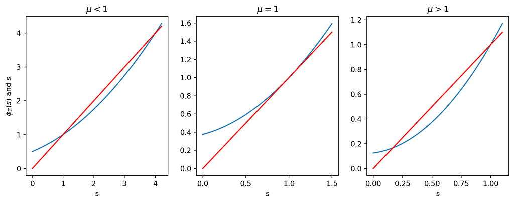

Figure 6.1: Extinction probabilities for branching processes

## 6.3 Examples

- If
  $$p(0)=\frac14, p(1)=\frac14, p(2)=\frac12 \implies \phi(s)=\frac14 + \frac14 s + \frac12 s^2$$
  then $\mu=\frac{5}{4}>1$ and solving $\phi(a)=a$ gives $a=1,\frac12$ so the extinction probability is $1/2$.
- If
  $$p(0)=\frac14, p(1)=\frac12, p(2)=\frac11 \implies \phi(s)=\frac14 + \frac12 s + \frac14 s^2$$
  then $\mu=1$ and solving $\phi(a)=a$ gives $a=1$ so the extinction probability is $1$.
- If
  $$p(0)=\frac12, p(1)=\frac14, p(2)=\frac14 \implies \phi(s)=\frac12 + \frac14 s + \frac14 s^2$$
  then $\mu=\frac{3}{4}<1$ and solving $\phi(a)=a$ gives $a=1,2$ so the extinction probability is $1$.

```python
import numpy as np
def f(s):
    return (1/8) + (3/8)*s + (1/8)*s**2 + (1/8)*s**3 + (2/8)*s**4

s = 0 # initial condition
N = 20 # the number of iterations

for i in range(N):
    s = f(s)
    print(s)
```

```
0.125
0.17413330078125
0.19498016827133297
0.20415762609873456
0.20826713424631457
0.2101216307743601
0.21096146654108697
0.21134240863922932
0.21151532651001245
0.2115938436492296
0.21162950143053777
0.21164569616414142
0.2116530515720635
0.21165639233633957
0.21165790969301684
0.21165859887003846
0.21165891189175637
0.21165905406517702
0.2116591186398882
0.21165914796951835
```

## 6.4 Repair shop example

Recall the Markov chain in Example 4.3. To establish if the system is postive recurrent we try to solve $\pi P=\pi$ and find the system of equations
$$\begin{aligned}
\pi(0)&= \pi(0)a_0 + \pi(1)a_0 \\
\pi(1)&= \pi(0)a_1 + \pi(1) a_1 + \pi(2)a_0 \\
\pi(2)& = \pi(0)a_2 + \pi(1)a_2 +\pi(2) a_1 + \pi(3)a_0 \\
& \vdots \\
\pi(n)& = \pi(0)a_n + \sum_{j=1}^{n+1} \pi(j) a_{n+1-j}
\end{aligned}$$

We solve this using the generating functions $\psi(s)=\sum_{n=0}^\infty s^n \pi(n)$ and $\phi(s)=\sum_{k=0}s^k a_k$:
$$\begin{aligned}
\psi(s) = \sum_{n=0}^\infty s^n\pi(n) &= \pi(0) \sum_{n=0}^\infty s^n a_n + \sum_{n=0}^\infty s^n \sum_{j=1}^{n+1} \pi(j) a_{n+1-j}\\
& = \pi(0) \sum_{n=0}^\infty s^n a_n + s^{-1} \sum_{j=1}^\infty \pi(j) s^j \sum_{n=j-1}^\infty s^{n+1-j} a_{n+1-j} \\
&=\pi(0) \phi(s) + s^{-1}(\psi(s)-\pi(0)) \phi(s)
\end{aligned}$$

Solving for $\psi(s)$ we find, after some algebra, the equation
$$\psi(s) = \frac{\pi(0) \phi(s)}{1- \frac{1- \phi(s)}{1-s}}$$

To see if we can find $\pi(0)$ such that this equation canbe solved we take $s \to 1$. We have $\psi(1)=\phi(1)=1$ and we have $\displaystyle \lim_{s\to 1}\frac{1- \phi(s)}{1-s}=\phi'(1)=\sum_{k=0}^\infty k a_k=\mu$ which is the mean number of object arriving in the repair shop in a single day. We find the equation
$$1= \frac{\pi(0)}{1- \mu}$$
and so we can find a solution $0 < \pi(0) \le 1$ if and only if $\mu< 1$ and so $\pi(0)=1-\mu$.
$$\textrm{ The repair shop Markov chain is positive recurrent iff } \mu < 1$$

To study transience we use Theorem 4.2 and try to find a solutinon $P \alpha(j) =\alpha(j)$ for $j\ge 1$ with $\alpha(0)=1$ and $0 < \alpha(j) <1$ for $j>1$. We find the system of equation
$$\begin{aligned}
\alpha(1) &= a_0 \alpha(0) + a_1 \alpha(1) + a_2 \alpha(2) + \cdots \\
\alpha(2) &= a_0 \alpha(1) + a_1 \alpha(2) + a_2 \alpha(3) + \cdots \\
\alpha(3) &= a_0 \alpha(2) + a_1 \alpha(3) + a_2 \alpha(4) + \cdots \\
& \vdots \\
\alpha(n) & = \sum_{j=0}^\infty a_j \alpha(j+n-1)
\end{aligned}$$
We try for a solution of the form $\alpha(j)=s^j$ which gives
$$s^n = \sum_{k=0}^\infty a_j s^{j+n-1} = s^{n-1} \phi(s) \implies \phi(s)=s$$
and from our analys of branching processes we know that a solution with $s<1$ exists iff $\mu= \sum_{k=0}^\infty k a_k >1$. So we get
$$\textrm{ The repair shop Markov chain is transient iff } \mu > 1$$
and it is null-recurrent if $\mu=1$.

## 6.5 Exercises

**Exercise 6.1** Consider a branching process with offspring distribution given by $p_n$. Make this process irreducible by asserting that if the the population ever dies out, then in the next generation one new individual appears (i.e. $P_{01}=1$). Determine for which values of $p_n$ the chain is positive recurrent and transient.

**Exercise 6.2** Given a branching process with the following offspring distributions determine the extinction probability $a$.

1. ${\displaystyle p(0)=.25, p(1)=.4, p(2)=.35}$
2. ${\displaystyle p(0)=5, p(1)=.1, p(3)=.4}$
3. ${\displaystyle p(0)=.62, p(1)=.30, p(2)=.02, p(6)=.02, p(13)=.04}$
4. ${\displaystyle p(i)=(1-q) q^i}$
5. ${\displaystyle p(0)=1/10, p(1)=3/10, p(2)=2/10, p(4)=1/20, p(5)=1/20, p(8)=1/10, p(12)=2/10}$
6. $p(k)$ follows a Poisson distribution with parameter $\lambda = 3/2$.

*Hint*: For the last two you need to do it numerically.

**Exercise 6.3** Consider the following variant of the branching process. During each time period each individual produces $k$ offsprings with probability $p(k)$ and has probability $0< q < 1$ of dying. Hence an individual will reproduce $j$ times where $j$ is the lifetime of the individual. For which choice of values of $q$ and $p(n)$ do we have eventual exctinction probability equal to $1$.

**Exercise 6.4** We consider the Moran strorage model. Imagine a reservoir of water capacity $c \le \infty$. The levels $X_n$ of the resevoir are observed at time $n, n+1, \cdots$. During each period an amount $m$ units of water (if available, and, with $m\le c$) are removed from the reservoir. In addition a random amount $A_n$ is added to the reservoir. The $A_n$ are supposed to be independent IID random variables and are also independent of $X_0$. The corresponding Markov chain is given by
$$X_{n+1} = \max \{ (X_n + A_{n+1} - m)_{+}, c\}$$
where $Y_+$ is the positive part of $Y$.

Consider the special case $m=1$ and $c=\infty$ (infinite reservoir). Using a moment generating function show that this Markov chain is positive recurrent provided $E[A_1] < 1$. *Hint:* If $X_n$ is positive recurrent then $X_n$ must converges to a random variable $X_\infty$ whose distribution is $\pi$. Then $X_\infty$ must satisfy the equation
$$X_\infty = (X_\infty + A_{\infty} - m)_{+}$$

# 7 Reversible Markov chains

## 7.1 Balance equation

Consider a Markov chain with transition probabilities $P(i,j)$ and stationary distribution $\pi(i)$. We can rewrite the equation for stationarity,
$$\pi(i)=\sum_{j} \pi(j) P(j,i)$$
as
$$\sum_{j} \pi(i) P(i,j) \,=\, \sum_{j} \pi(j) P(j,i) \,.
\tag{7.1}$$
which we are going to interpret as a *balance equation*.

We introduce the (stationary) probability current from $i$ to $j$ as
$$J(i,j) \equiv \pi(i) P(i,j)
\tag{7.2}$$
and Equation 7.1 can be rewritten as
$$\underbrace{\sum_{ j} J(i,j)}_{\textrm{total current out of state } i} \,=\, \underbrace{\sum_j J(j,i) }_{\textrm{total current into of state i}} \, \quad \quad \textrm{ balance equation }
\tag{7.3}$$
i.e., to be stationary the total probability current out of $i$ must be equal to the total probability current into $i$.

## 7.2 Detailed balance

A stronger condition for stationarity can be expressed in terms of the balance between the currents $J(i,j)$. A Markov chain $X_n$ satisfies detailed balance if there exists $\pi(i)\ge 0$ with $\sum_{i} \pi(i)= 1$ such that for all $i,j$ we have
$$\pi(i) P(i,j) \,=\, \pi(j) P(j,i) \quad \textrm{ or equivalently } \quad J(i,j) = J(j,i)
\tag{7.4}$$
This means that for every pair $i,j$ the probability currents $J(i,j)$ and $J(j,i)$ balance each other.
Clearly Equation 7.4 is a stronger condition than Equation 7.3 and thus we have

**Lemma 7.1** If the Markov chain satisfies detailed balance for a probability distribution $\pi$ then $\pi$ is a stationary distribution.

But it is easy to see that detailed balance is a stronger condition than stationarity. The property of detailed balance is often also called (time)-reversibility since we have the following results which states that the probability of any sequence is the same as the probability of the time reversed sequence.

**Theorem 7.1 (Time reversibility)** Suppose the Markov chain $X_n$ satisfies detailed balance and assume that the initial distribution is the stationary distribution $\pi$. Then for any sequnce of states $i_0, \cdots i_n$ we have
$$P \left\{ X_{0}= i_0 \,, X_1=i_1\,, \cdots \, , X_n =i_n \right\} \,=\, P \left\{ X_{0}= i_n \,, X_1 = i_{n-1}\,, \cdots \, , X_n =i_0 \right\}$$

*Proof*. Using Equation 7.4 repeatedly we find
$$\begin{aligned}
P \left\{ X_{0}= i_0 \,, X_1=i_1\,, \cdots \, , X_n =i_n \right\}
& \,=\, \pi(i_0) P(i_0, i_1) P(i_1, i_2) \cdots P(i_{n-1}, i_n) \\
& \,=\, P(i_1, i_0) \pi(i_1) P(i_1, i_2) \cdots P(i_{n-1}, i_n) \\
& \,=\, P(i_1, i_0) P(i_2, i_1) \pi(i_2) \cdots P(i_{n-1}, i_n) \\
& \,=\, \cdots \\
& \,=\, P(i_1, i_0) P(i_2, i_1) \cdots \pi(i_{n-1}) P(i_{n-1}, i_n) \\
&\ \,=\, P(i_1, i_0) P(i_2, i_1) \cdots P(i_n, i_{n-1}) \pi(i_n) \\
&\,=\,P \left\{ X_{0}= i_n \,, X_1 = i_{n-1}\,, \cdots \, , X_n =i_0 \right\}
\end{aligned}$$
$\blacksquare$

The next result is very easy and very useful.

**Theorem 7.2** Suppose $X_n$ is a Markov chain with finite state space $S$ and with a *symmetric* transition matrix, i.e, $P(i,j)=P(j,i)$. Then $X_n$ satisfies detailed balance with $\pi(j) = 1 /|S|$, i.e., the stationary distribution is uniform on $S$.

## 7.3 Examples

- *Random walk on the hypercube $\{0,1\}^m$*. The state space $S$ is
  $$S= \{0,1\}^m \,=\, \left\{ \sigma = ( \sigma_1, \cdots, \sigma_m) \,;\, \sigma_i \in \{0,1\} \right\}$$
  To define the move of the random walk, just pick one coordinate $j \in \{ 1, \cdots, m\}$ and flip the $j^{th}$ coordinate, i.e., $\sigma_j \to 1- \sigma_j$. We have thus
  $$P(\sigma, \sigma') =\left\{ \begin{array}{cl} \frac{1}{m} & \text{ if }\sigma \text{ and } \sigma' \text{ differ by one coordinate }
  \\ 0 &\text{ otherwise}
  \end{array}
  \right.$$
  Clearly $P$ is symmetric and thus $\pi(\sigma) \,=\, 1/ 2^m$.
- *Random walk on the graph $G=(E,V)$* has transition probabilities $p(v, w) = \frac{1}{ \text{ deg }(v)}$. This Markov chain satifies detailed balance with the (unnormalized) $\mu(v) = deg(v)$. Indeed we have $P(v,w) >0 \iff P(w,v)>0$ and thus if $P(v,w)>0$ we have
  $$\mu(v) P(v, w) \,=\, \text{ deg}(v) \frac{1}{{\rm deg} (v)} = 1 \,=\, {\rm deg}(w) \frac{1}{{\rm deg} (w)}= \mu(w) P(w, v) \,.$$
  This is slightly easier to verify that the stationary equation $\pi P = \pi$. After normalization we find $\pi(v) = {\rm deg}(v)/2|E|$.
  For example for the simple random walk on $\{0, 1, \cdots, N\}$ with reflecting boundary conditions we find $\pi \,=\, \left( \frac{1}{2N}, \frac{2}{2N}, \cdots, \frac{1}{2N} \right)$.
- *Network Markov chain*: The previous example can be generalized as follows. For a given graph $G=(E,V)$ let us assign a positive weight $c(e)>0$ to each (undirected) edge $e= \{v,w\}$, that is we choose numbers $c(v,w)=c(w,v)$ with $c(v,w)=0$ iff $v$ and $w$ are not connected by an edge. If the transition probabilities are given by
  $$P(v,w) \,=\, \frac{c(v,w)}{c(v)} \quad \textrm{ with } c(v) \,=\, \sum_{w} c(v, w) \,,$$
  then it is easy to verify that the Markov chain satisfies detailed balance with
  $$\pi(v) \,=\, \frac{c(v)}{c_G} \quad \textrm{ with } c_G \,=\, \sum_{v} c(v) \,.$$
- *Birth-Death Processes Markov chain:* Let us consider a Markov chain on the state space $S=\{0, \cdots, N\}$ ($N$ could be infinite) with transition probabilities have the following tridiagonal structure
  $$\begin{matrix}
  0 \\1\\2\\3\\ \cdots
  \end{matrix}
  \begin{pmatrix}
  r_0 & p_0 & 0 & 0& \cdots \\
  q_1 & r_1 & p_1 & 0 & \cdots \\
  0 & q_2 & r_2 & p_2 & \cdots \\
  \vdots & &\ddots&\ddots & \ddots
  \end{pmatrix}$$
  This is called a *birth and death process* since the only possible transition are to move up or down by unit or stay unchanged. Random walks (see Example 1.5 and Example 4.1), discrete queueing models (Example 4.2 ), the Ehrenfest urn model Example 1.6 are special case of birth and death processes.

Birth and death Markov chain always satisfy detailed balance. Indeed the only non trivial detailed balance conditions are
$$\pi(j)P(j,j+1) = \pi(j+1) P(j+1,j) \implies \pi(j) p_j \,=\, \pi(j+1) q_{j+1} \,, \quad \textrm{ for } j=0, \cdots, N-1 \,.$$
and this can be solved recursively. We obtain
$$\begin{aligned}
\pi(1) \,&=\, \pi(0) \frac{p_0}{q_1} \\
\pi(2) \,&=\, \pi(1) \frac{p_1}{q_2} \,=\, \pi(0) \frac{p_0 p_1 }{q_1 q_2} \\
& \vdots \\
\pi(N) \,&=\, \pi(0) \frac{p_0 p_1 \cdots p_{N-1}}{q_1 q_2 \cdots q_{N-1}}
\end{aligned}$$
and with normalization $\pi(j) \,=\, \frac{ \prod_{k=1}^j \frac{p_{k-1}}{q_k}}{ \sum_{l=0}^N \prod_{k=1}^l \frac{p_{k_1}}{q_k}}$. If $N$ is infinite we need the sum in the deominator to be finite.

For example the Ehrenfest urn in Example model has
$$p_j \,=\, \frac{N-j}{N} \,, \quad q_j \,=\, \frac{j}{N}$$
and thus we obtain
$$\pi(j) \,=\, \pi(0) \frac{ \frac{N}{N} \frac{N-1}{N} \cdots \frac{N-(j-1)}{N}}{ \frac{1}{N} \frac{2}{N} \cdots \frac{j}{N}}
\,=\, \pi(0) { N \choose j } \quad \textrm{ and also } \pi(0) =\sum_{j=0}^N {N \choose j} \,=\, 2^N.$$

## 7.4 Exercises

**Exercise 7.1** A total of $m$ white balls and $m$ black balls are distributed among two urns, each of which contains $m$ balls. At each stage a ball is randomly selected from each urn and the two selected balls are interchanged. Let $X_n$ be the number of black balls in urn 1 after $n$ stages.

1. Give the transition probabilities of the Markov chain $X_n$.
2. Can you guess without any computation guess what the stationary distribution is?
3. Find the stationary distribution using the detailed balance condition.

**Solution**

1. $P(i,i+1)= \frac{(m-i)^2}{m^2}$, $P(i,i-1)=\frac{i^2}{m^2}$, $P(i,i) = 2 \frac{i(m-1)}{m^2}$.
2. If I select $m$ balls at random from 2m balls ($m$ whites and $m$ blacks) the probability I select $j$ white balls (and thus $(m-j)$ black black balls) is $\frac{{m \choose j}{m\choose m-j} }{2m \choose m}$.

3. We get $\pi(j)={m \choose j}^2 \pi(0)= {m\choose j}{m \choose m-j} \pi(0)$ and thus $\pi(j)= \frac{{m \choose j}{m \choose m-j}}{{2m \choose m}}$

**Exercise 7.2 (Cycle condition for detailed balance)** Suppose $X_n$ an irreducible Markov chain with stationary distribution $\pi$. Assume that for all pairs $i,j$ we have $P(i,j)>0 \iff P(j,i)>0$. Show that $X_n$ satisfies detailed balance if and only if for any $n$ and any sequence of state $i_0, i_1, i_2, \cdots i_n$
$$P(i_0,i_1) P(i_1, i_2) \cdots P(i_{n-1}, i_n) P(i_n, i_0) \,=\, P(i_0,i_n) P(i_n, i_{n-1}) \cdots P(i_2, i_1) P(i_1, i_0)$$
*Hint:* For the “if” part use the convergence to stationary distribution.

**Solution**

Using detailed balance consider the path $i_0, i_1, \cdots, i_n=i_0$. We have then
$$\pi(i_0) P(i_0,i_1) \cdots P(i_{n-1}, i_0)= \pi(i_o) P(i_0, i_{n-1}) \cdots P(i_1,i_0)$$
and the $\pi(i_0)$ factors cancel out.

Conversely use the cycle condition and sum over all the states $i_2, i_2, i_{n}$. Then one finds
$$P(i_0, i_1) P^{n}(i_1,i_0) = P^{n}(i_0,i_1) P(i_1, i_0)$$
If the chain is irreducible and aperiodic then $P^{n}(i,j) \to \pi(j)$ and thus we find $\pi(i_0)P(i_0,i_1)=\pi(i_1)P(i_1,i_0)$.

If the chain is periodic the argument works in a similar manner by using that $\frac{1}{n}\sum_{k=1}^nP^k(i,j)\to \pi(j)$

**Exercise 7.3 (The time reversed chain)** Let $X_n$ be an irreducible Markov chain with transition probabilities $P(i,j)$ and stationary distribution $\pi(i)$. Define $\widehat{P}(i,j) \,=\, \frac{\pi(j)}{\pi(i)} P(j,i)$.

1. Show that $\widehat{P}(i,j)$ is a stochastic matrix and that the corresponding Markov chain $\widehat{X}_n$ is irreducible with stationary distribution $\pi$.
2. Show that if the initial distribution is $\pi$ then we have
   $$P \left\{ \widehat{X}_0 = i_0, \widehat{X}_1 = i_1, \cdots, \widehat{X}_n
   =i_n\right\} \,=\, P \left\{ X_0= i_n, X_{1}=i_{n-1}, \cdots X_n = i_O
   \right\} \,.$$
   which justifies calling the Markov chain $\widehat{X}_n$ to be the *time reversed* chain.
3. What is the time reversed chain for the Markov chain with transition matrix
   $$P= \begin{matrix}
   0\\1\\2\\\vdots
   \end{matrix}
   \begin{pmatrix}
   1-p & p & 0 & 0 & \cdots\\
   1-p & 0 & p & 0 & \cdots \\
   1-p & 0 & 0 & p & \cdots \\
   \vdots& & & \ddots & \ddots &
   \end{pmatrix}$$
4. Show that the Markov chains with transition matrices $\frac{P + \widehat{P}}{2}$ and $\widehat{P}P$ satisfy detailed balance with stationary distribution $\pi$.

**Solution**

1. Using stationarity $\sum_{j}\widehat{P}(i,j) \,=\, \frac{\sum_{j} \pi(j) P(j,i)}{\pi(i)} = \frac{\pi(i)}{\pi(i)}=1$ and using that $P$ is a stochastic matrix $\sum_{i} \pi(i)\widehat{P}(i,j)=\sum_{i} \pi(i)\frac{\pi(j) P(j,i)}{\pi(i)} =\pi(j)$.
2. $$\begin{aligned}
   \pi(i_0)\widehat{P}(i_0,i_1)\cdots \widehat{P}(i_{n-1},i_n) &= \pi(i_0) \frac{\pi(i_1) P(i_1,i_o)}{\pi(0)} \cdots \widehat{P}(i_{n-1},i_n)\\
   & = P(i_1, i_0)\pi(i_1) \widehat{P}(i_1,i_2) \cdots \widehat{P}(i_{n-1},i_n)
   \end{aligned}$$
   and so on.
3. The stationary distribution is $\pi(j)=(1-p)p^j$. The time reversal gives $\pi(j)P(j,0)=\pi(0)\widehat{P}(0,j)$ and thus $\widehat{P}(0,j)=\pi(j)$. Also we have $\pi(j)P(j,j+1)=\pi(j+1)\widehat{P}(j+1,j)$ and thus $\widehat{P}(j+1,j)=1$. Thus we have
   $$\widehat{P}= \begin{matrix}
   0\\1\\2\\3\\\vdots
   \end{matrix}
   \begin{pmatrix}
   \pi(0) & \pi(1) & \pi(2) & \pi(3) & \cdots\\
   1 & 0 & 0 & 0 & \cdots \\
   0 & 1 & 0 & 0 & \cdots \\
   0& 0 & 1& 0 & \cdots & \\
   \vdots& & & \ddots & \ddots &
   \end{pmatrix}$$
4. By definition of time reversal $\pi(i)P(i,j)=\pi(j)\widehat{P}(j,i)$ and thus $\pi(i)\frac{1}{2}(P(i,j)+ \widehat{P}(j,i))= \pi(j)\frac{1}{2}(\widehat{P}(i,j)+ P(j,i))$ which proves detailed balance for $\frac{P + \widehat{P}}{2}$.

In a similar manner we have
$$\pi(i) (\widehat{P}P)(i,j)= \sum_{k} \pi(i) \widehat{P}(i,k)P(k,j) = \sum_{k} P(k,i)\pi(k)P(k,j) = \sum_{k} P(k,i)\widehat{P}(j,k) \pi(j) = \pi(j)(\widehat{P}P)(j,i)$$
which proves detailed balance for $\widehat{P}P$.

**Exercise 7.4 (Eigenvalues of $P$)** Let $P$ be the transition matrix of an irreducible Markov chain with finite state space $S$ and stationary distribution $\pi$.

1. Show that if $P$ is aperiodic then $P$ has an eigenvalue $1$ which is simple (i.e. $0$ is a simple root of $\textrm{ det}(I - P)$) and that all other eigenvalues have absolute value strictly less than $1$. *Hint*: Use the convergence theorem
2. Prove that if $P$ is periodic with period $2$ then $P$ has eigenvalues $1$ and $-1$ each of which is simple.  
   *Hint*: WLOG you can write $P$ is the block form $P=\begin{pmatrix} 0 & P_{01} \\ P_{10} & 0 \end{pmatrix}$. Show that $1$ is an eigenvalue of $P^2$ with multiplcity $2$. If $f=\begin{pmatrix} f_0 \\ f_1 \end{pmatrix}$ is an eigenvector for $P$, then consider $g=\begin{pmatrix} f_0 \\ - f_1 \end{pmatrix}$.
3. For column vectors $f$ and $g$ define a scalar product on $\mathbb{R}^{|S|}$ by $\langle f , g \rangle_\pi \,=\, \sum_{i \in S} \pi(i) f(i) g(i)$. Let $P^\dagger$ to be the adjoint of $P$ with respect to the scalar product $\langle f , g \rangle_\pi$, i.e., $\langle f , P g \rangle_\pi = \langle P^\dagger f , g \rangle_\pi$ for all $f$, $g$.  
   Show that $P^\dagger$ are the transition probabilities of the reversed Markov chain from Exercise 7.3 and that the Markov chain is reversible if and only $P=P^\dagger$.
4. Show that if the Markov chain is reversible, the eigenvalues of $P$ are real with $\lambda_0=1 > \lambda_2 \ge \lambda_3 \cdots \ge \lambda_N \ge -1$ and that if the chain is aperiodic then $\lambda_N > -1$.

**Solution**

1. If $P$ is irreducible and aperiodic we have sene that 1) the only right eigenvector are multiples of the constant column vector $1$ and the only left eigenvector are multiples of the uniqe stationary distribution. From the convergence theorem we learned that, if $\Pi$ is the matrix whose every row equal to $\pi$ then we have $(P-\Pi)^n = P^n - \pi$ and this converges to $0$ has $n\to infty$.

For the eigenvalue $1$ we thus know that the geometric multiplicity (the dimension of the eigenspace is $1$). To show the algebraic multiplicity is also $1$ assume it is not and thus we have a generalized eigenvector of the form
$$(P-I)f = 1 \implies Pf = f + 1 \implies P^n f = f + n1$$
and this contradicts the fact that $(P^n -\pi) f$ should converge to $0$.

If $\lambda$ is an eigenvalue other than $1$ and $f$ an eigenvector so that $P^f = \lambda f$. Multiplying this by the row vector $\pi$ gives $\pi P f = \pi f= \lambda \pi f$ and thus $\pi f=0$. Therefore $(P^n-\Pi)f = P^nf = \lambda^n f$ and the convergence theorem implies that the eigenvalue $\lambda$ must statisfy $|\lambda|<1$.

2. Suppose $P$ is irredicuble with period $2$. Then $P$ has the form $P=\begin{pmatrix} 0 & P_{01} \\ P_{10} & 0 \end{pmatrix}$ and thus $P^2=\begin{pmatrix} P_{01}P_{10} & \\ 0 & P_{1,0}P_{0,1} \end{pmatrix}$. In particular $P^2$ is not irreducible and for the eigenvalue $1$ of $P^2$ we have two eigenvectors of the form $\begin{pmatrix} f_0\\0 \end{pmatrix}$ and $\begin{pmatrix} 0\\f_1 \end{pmatrix}$ which satisfies
   $$P_{01}P_{10} f_0 = f_0 \quad \quad P_{10}P_{01} f_1 = f_1 \,.$$
   Consider now the two vectors $\begin{pmatrix} f_0\\f_1 \end{pmatrix}$ and $\begin{pmatrix} f_0\\-f_1 \end{pmatrix}$ which are linearly independent. Then we claim this vector are eiegenvectors for $P$ with eiegenvalues $1$ and $-1$ respectively. Indeed
   $$\begin{pmatrix} 0 & P_{01} \\ P_{10} & 0 \end{pmatrix} \begin{pmatrix} f_0\\f_1 \end{pmatrix} = \begin{pmatrix} f_0\\f_1 \end{pmatrix} \iff \begin{matrix} P_{01}f_1=f_0\\ P_{10} f_0 = f_1\end{matrix} \iff \begin{matrix} P_{01}P_{10} f_0=f_0 \\ P_{10}P_{01} f_1=f_1 \end{matrix}$$
   and similarly
   $$\begin{pmatrix} 0 & P_{01} \\ P_{10} & 0 \end{pmatrix} \begin{pmatrix} f_0\\-f_1 \end{pmatrix} = -\begin{pmatrix} f_0\\-f_1 \end{pmatrix} \iff \begin{matrix} -P_{01}f_1=- f_0\\ P_{10} f_0 = f_1\end{matrix} \iff \begin{matrix} P_{01}P_{10} f_0=f_0 \\ P_{10}P_{01} f_1=f_1 \end{matrix}$$
   which proves our claim.
3. Let us consider the scalar product of ${\mathbb{C}^{|S|}}$ given by $\langle f , g \rangle_\pi= \sum_{i \in S} \pi(i) \overline{f(i)} g(i)$. (We will need to consider complex values later on). Then we have, using $\pi P(i,j) = \pi(j) \widehat{P}(j,i)$
   $$\begin{aligned}
   \langle f , P g \rangle_\pi = \sum_{i} \pi(i) \overline{f(i)} P g(i) = \sum_{i } \sum_{j} \pi(i) \overline{f(i)} P(i,j) g(j) \\
   =\sum_{i } \sum_{j} \pi(j) \overline{f(i)} \widehat{P}(j,i) g(j) = \sum_{j} \pi(j) \overline{ \widehat{P}f(j)} g(j) = \langle \widehat{P}f , g \rangle_\pi
   \end{aligned}$$
   and therefore $\widehat{P}$ is the adjoint $P^\dagger$ of $$ with respect to this scalar product and $P$ is reversible if only if $P$ is selfadjoint.
4. If $P$ is reversible and $f$ is an eigenvalue, then due to the fact that $P$ is a real matrix we have
   $$P f = \lambda f \implies P \overline{f} = \overline{\lambda} \overline{f}$$
   that is the eigenvalues of $P$ are either real or come in complex conjugate pairs. If $P$ is reversible then using the scalar product $\langle f , g \rangle_\pi$ we have
   $$\lambda \langle f , P g \rangle_\pi = \langle f , P f \rangle_\pi \underbrace{=}_{P \text{reversible}} \langle Pf , f \rangle_\pi = \overline{\lambda} \langle f , f \rangle_\pi$$
   and thus $\lambda$ must be real.

**Exercise 7.5** A Markov chain (on a finite state space) is a called a tree process if

- $P(i,j)>0 \iff P(j,i)>0$
- For any pair $(i,j)$ there is a unique path $i_0=i,i_1, i_2, \cdots, i_N=j$ such that $P(i_k,i_k+1)>0$ for $k=0, \cdots, N-1$.

Show that a irreducible tree process satisfies detailed balance.

**Solution**

Since there is a unique path with positive probability between two states, pick one (arbitrary) state, say $j_0$ and set $\mu(j_0)=1$. Now for any $j$ define
$$\mu(j) = \frac{ P(j_0,i_1) P(i_1,i_2) \cdots P(i_{n-1}, j) }{{ P(j,i_{n-1}) P(i_{n-1},i_{n-1}) \cdots P(i_{1}, j) }}$$
By the uniqueness of the path between $j_0$ anfd $j$ this defined $\alpha(j)$ an unmabiguous manner.

To check detailed balance let us consider two arbitrary states $j$ and $j'$. If $P(j,j')>0$ (and then also $P(j',j)>0$) then there is path of positive of probability of the form $j_0,i_1,\cdots, i_{n_1}, j, j'$ (or a path with instead $j',j$ at the end). Then by construction
$$\mu(j') = \frac{ P(j_0,i_1) P(i_1,i_2) \cdots P(i_{n-1}, j) P(j,j') }{{ P(j',j)P(j,i_{n-1}) P(i_{n-1},i_{n-1}) \cdots P(i_{1}, j) }} = \frac{\mu(j) P(j,j')}{P(j',j)}[]$$
and this proves detailed balance. We can then normalize $\alpha$ to make it a probability measure.

# 8 Markov chain Monte-Carlo

## 8.1 MCMC

Suppose you are given a certain probability distribution $\pi$ on a set $S$ and you goal is to generate a sample from this distribution. The **Monte-Carlo Markov chain (MCMC)** method consists in constructing an irreducible Markov chain $X_n$ whose stationary distribution is $\pi$. Then to generate $\pi$ one simply runs the Markov chains $X_n$ long enough such that it is close to its equilibrium distribution. It turns out that using the detailed balance condition is a very useful tool to construct the Markov chain in this manner.

A-priori this method might seems an unduly complicated way to sample from $\pi$. Indeed why not simply simulate from $\pi$ directly?

To dispel this impression we will consider some concrete examples but for example we will see that often one want to generate a uniform distribution on a set $S$ whose cardinality $|S|$ might be very difficult.

A large class of model are so-called “energy models” which are described by an explicit function $f:S \to \mathbb{R}$ interpreted as the energy (or weight) of the state. Then one is interested in the stationary distribution
$$\pi(i) = Z^{-1} e^{-f(i)} \quad \textrm { where } Z= \sum_{i}e^{-f(i)} \textrm{ is a normalization constant}$$
As we will see computing the normalization constant $Z$ can be very difficult and so one cannot directly simulate from $\pi$!

The measure $\pi$ assign biggest probability to the states $i$ where $f(i)$ is the smallest, that is they have the smallest energy.  
Often (e.g. in economics) the measure is written with a different sign convention $\pi(i) = Z^{-1}e^{f(i)}$ which now favor the states with the highest values of $f$.

## 8.2 Proper q-coloring of a graph

For a graph $G=(E,V)$ a proper $q$-coloring consists of assigning to each vertex $v$ of the graph one of $q$ colors subject to the constraint that if $2$ vertices are linked by an edge they should have different colors. The set $S'$ of all proper $q$-coloring which is a subset of $S \,=\, \left\{ 1, \cdots, q\right\}^V$. We denote the elements of $S$ by $\sigma = \{ \sigma(v)\}_{v \in V}$ with $\sigma(v) \in \{1, \cdots, q\}$. The uniform distribution on all such proper coloring is $\pi(\sigma) = 1/|S'|$ for all $\sigma \in S'$. Even for moderately complicated graph it can be very difficult to compute to $|S'|$.

Consider the following transition rules:  
1. Choose a vertex $v$ of at random and choose a color $a$ at random. 2. Set $\sigma'(v) = a$ and $\sigma'(w)=\sigma(w)$ for $w \not=v$. 3. If $\sigma'$ is a proper $q$-coloring then set $X_{n+1}=\sigma'$. Otherwise set $X_{n}=\sigma$.

The transition probabilities are then given by
$$\begin{aligned}
P(\sigma, \sigma') =\left\{
\begin{array}{cl}
\frac{1}{q |V|} & \textrm{ if } \sigma \textrm{ and } \sigma' \textrm{ differ at exactly one vertex} \\
0 & \textrm{ if }\sigma \textrm{ and } \sigma' \textrm{ differ at more than one vertex} \\
1 - \sum_{\sigma' \not = \sigma} P(\sigma, \sigma') & \textrm{ if } \sigma'=\sigma
\end{array}
\right.
\end{aligned}$$
Note that $P(\sigma, \sigma)$ is not known explicitly either but is also not used to run the algorithm. The cardinality $|S'|$ is also not needed.

In order to check that the uniform distribution is stationary for this Markov chain it note that $P(\sigma, \sigma')$ is symmetric matrix. If one can change $\sigma$ into $\sigma'$ by changing one color then one can do the reverse transformation too.

## 8.3 Knapsack problem

This is a classical optimization problem. You own $m$ books and the $i^{th}$ book has weight $w_i$ lb and is worth $ $v_i$. In your knapsack you can put at most a total of $b$ pounds and you are looking to pack the most valuable knapsack possible.

To formulate the problem mathematically we introduce
$$\begin{aligned}
w \,&=\, (w_1, \cdots w_m) \in {\bf R}^m &\textrm{ weight vector} \\
v \,&=\, (v_1, \cdots v_m) \in {\bf R}^m &\textrm{ value vector} \\
\sigma\,&=\, (\sigma_1, \cdots \sigma_m) \in \{0,1\}^m &\textrm{ decision vector}
\end{aligned}$$
where we think that $\sigma_i =1$ if the $i^{th}$ book is in the knapsack. The state space is
$$S' \,=\, \left\{ \sigma \in \{0,1\}^{m} \,;\, \sigma \cdot w \le b \right\}$$
and the optimization problem is
$$\textrm{Maximize } v \cdot \sigma \textrm{ subject to the constraint } \sigma \in S'$$

As a first step we generate a random element of $S'$ using the simple algorithm. If $X_n=\sigma$ then

1. Choose $j \in \{1, \cdots m\}$ at random.
2. Set $\sigma' \,=\, ( \sigma_1, \cdots, 1-\sigma_j, \cdots, \sigma_m)$.
3. If $\sigma' \in S'$, i.e., if $\sigma' \cdot w \le b$ then let $X_{n+1}=\sigma'$. Otherwise $X_{n+1}=\sigma$.

In other words, choose a random book. If it is in the sack already remove it. If it is not in the sack add it provided you do not exceed the the maximum weight. Note that the Markov chain $X_n$ is irreducible, since each state communicates with the state $\sigma=(0, \cdots, 0)$. It is aperiodic except in the uninteresting case where $\sum_{i} w_i \le b$. Finally the transition probabilities are symmetric and thus the uniform distribution the unique stationary distribution.

In the knapsack problem we want to maximize the function $f(\sigma)=\sigma\cdot v$ on the state space. One possible algorithm would be to generate an uniform distribution on the state space and then to look for the maximum value of the function. But it would be a better idea to sample from a distribution which assign higher probabilities to the states which we are interested in, the ones with a high value of $f$.

Let $S$ be the state space and let $f \,:\, S \to \mathbb{R}$ be a function. It is convenient to introduce the probability distributions define for $\beta>0$ by
$$\pi_\beta(i) \,=\, \frac{e^{\beta f(i)}}{Z_\beta} \, \quad \textrm{ with } \quad Z_\beta =\sum_{j \in S} e^{\beta f(j)} \,.$$
Clearly $\pi_\beta$ assign higher weights to the states $i$ with bigger values of $f(i)$. Let us define
$$S^* \,=\, \left\{ i \in S \,;\, f(i) = f^* \equiv \max_{j \in S} f(j) \right\} \,.$$
If $\beta=0$ then $\pi_0$ is simply the uniform distribution on $S$. For $\beta \to \infty$ we have
$$\lim_{\beta \to \infty} \pi_\beta(i) \,=\, \lim_{\beta \to \infty} \frac{ e^{\beta (f(i)- f^*)}} { |S^*| + \sum_{j \in S\setminus S^*} e^{\beta (f(j) - f^* )}} \,=\,
\left\{
\begin{array}{cl} \frac{1}{|S^*|} & {\rm ~if~} i \in S^* \\ 0 & {\rm ~if~} i \notin S^* \\
\end{array}
\right. \,,$$
i.e., for large $\beta$ $\pi_\beta$ is concentrated on the global maxima of $f$.

## 8.4 Metropolis algorithm

A fairly general method to generate a distribution $\pi$ on the state space $S$ is given the **Metropolis algorithm**. This algorithm assumes that you already know how to generate the uniform distribution on $S$ by using a symmetric transition matrix $Q$.

**Theorem 8.1 (Metropolis algorithm)** Let $\pi$ be a probability distribution on $S$ with $\pi(i)>0$ for all $i$ and let $Q$ be a symmetric transition matrix. Consider the Markov chain with the following transition matrix (the Metropolis algorithm). If $X_n=i$

1. Choose $Y \in S$ according to $Q$, i.e., $P\{ Y=j \,\vert\, X_n=i\} \,=\, Q(i,j)$
2. Define the acceptance probability $\alpha(i,j) \,=\, \min \left \{ 1 \,, \frac{\pi(j)}{\pi(i)} \right\}$
3. Accept $Y$ with probability $\alpha=\alpha(i,j)$ by generating random number $U$. If $U \le \alpha$ then set $X_{n+1}= Y$ (i.e., accept the move) and if $U > \alpha$ then $X_{n+1}= X_n$ (i.e., reject the move).

If $Q$ is an irreducible transition probability matrix on $S$ then the Metropolis algorithm defines an irreducible Markov chain on $S$ which satisfies detailed balance with stationary distribution $\pi$.

*Proof*. Let $P(i,j)$ be the transition probabilities for the Metropolis Markov chain. Then we have
$$P(i,j) \,=\, Q(i,j) \alpha(i,j) \,=\, Q(i,j) \min \left\{ 1 \,,\, \frac{\pi(j)}{\pi(i)} \right\} \,.$$

Since we assume $\pi(i)>0$ for all states $i$, the acceptance probability $\alpha$ never vanishes. Thus if $P(i,j)>0$ whenever $Q(i,j)>0$ and thus $P$ is irreducible if $Q$ is itself irreducible.

In order to check the reversibility we note that
$$\pi(i) P(i,j) \,=\, Q(i,j) \pi(i) \min \left\{ 1, \frac{\pi(j)}{\pi(i)} \right\} \,=\, Q(i,j) \min \left\{\pi(i)\,,\, \pi(j) \right\}$$
and the r.h.s is symmetric in $i,j$ and thus $\pi(i) P(i,j) =\pi(j) P(j,i)$. $\quad \blacksquare$

- Note that only the ratios $\frac{\pi(j)}{\pi(i)}$ are needed to run the algorithm, in particular we do not need the normalization constant. This is a very important feature of the Metropolis algorithm.
- We could have chosen another acceptance probability $\alpha(i,j)$. By inspection of the proof it is enough to pick $\alpha(i,j)$ such that $\alpha(i,j) \le 1$ and $\pi(i) \alpha(i,j) = \pi(j) \alpha(j,i)$ is symmetric. Some such examples will be considered in the homework and the choice given in Theorem 8.1 is actually optimal in the sense it gives the highest acceptance probability.
- The general case with a non-symmetric proposal matrix $Q$ is called the **Metropolis-Hastings algorithm**. In this case we use the acceptance probability is chosen to be
  $$\alpha(i,j) = \min \left\{ 1, \frac{\pi(j)Q(j,i)}{\pi(i)Q(i,j)} \right\}$$
  and it is not difficult to check (see Homework) that the Metropolis-Hasting algorithm yields a reversible Markov chain with stationary distribution $\pi$.

## 8.5 Uniform distribution on a graph

Suppose we are given a graph $G=(E,V)$. Often in application to computer networks or social networks the graph is not fully known. Only local information is available: given a vertex one knows the vertices one is connected to. Nonetheless you can run a random walk on the graph by choosing a edge at random and moving to the corresponding vertex, i.e.
$$Q(v,w) = \frac{1}{\textrm{ deg}(v)} \textrm{ if } v \sim w$$
and the stationary distribution is $\pi(v) \propto \rm{deg}(v)$.

Suppose you wish to generate a uniform distribution on the graph. Then we can use the Metropolis-Hasting to generate a Markov chain with a uniform stationary distribution. We have
$$\alpha(v,w) = \min\left\{ 1, \frac{Q(w,v)}{Q(v,w)}\right\} =\min\left\{ 1, \frac{\textrm{ deg}(v)}{\textrm{ deg}(w)}\right\} \textrm{ if } v \sim w$$
and thus the transition matrix
$$P(v,w) = Q(v,w) \alpha(v,w) =
\frac{1}{\textrm{ deg}(v)} \min\left\{ 1, \frac{\textrm{ deg}(v)}{\textrm{ deg}(w)}\right\}
= \min\left\{ \frac{1}{\textrm{ deg}(v)}, \frac{1}{\textrm{ deg}(w)} \right\}$$
generates a uniform distribution on a graph.

## 8.6 Metropolis algorithm for the knapsack problem

Consider the distribution $\pi_\beta(\sigma) \,=\, \frac{e^{\beta v \cdot \sigma}}{ Z_\beta}$ where the normalization constant $Z_\beta = \sum_{\sigma \in S'} e^{\beta v \cdot \sigma}$ is almost always impossible to compute in practice. However the ration
$$\frac{\pi(\sigma')}{\pi(\sigma)} = e^{\beta v \cdot (\sigma'-\sigma)}$$
does not involve $Z_\beta$ and is easy to compute.

For this distribution we take as the proposal $Q$ matrix used to generate a uniform distribution on the allowed states of the knapsack (see Knapsack problem) and the Metropolis algorithm now reads as follows. If $X_n=\sigma$ then

1. Choose $j \in \{1, \cdots m\}$ at random.
2. Set $\sigma' \,=\, ( \sigma_1, \cdots, 1-\sigma_j, \cdots, \sigma_m)$.
3. If $\sigma'\cdot w >b$ (i.e. if $\sigma \notin S'$) then $X_{n+1}=\sigma$. (i.e. reject)
4. If $\sigma'\cdot w \le b$ then let $\displaystyle \alpha \,=\, \min \left\{ 1 , \frac{ \pi(\sigma')}{\pi(\sigma)} \right\} \,=\, \min \left\{1, e^{\beta v \cdot (\sigma' - \sigma)} \right\} \,=\, \left\{ \begin{array}{cl} e^{- \beta v_j} & {\rm ~if~} \sigma_j=1 \\ 1 & {\rm ~if~} \sigma_j=0 \end{array} \right.$
5. Generate a random number $U$, If $U \le \alpha$ then $X_{n+1}=\sigma'$. Otherwise $X_{n+1}=\sigma$.

In short, if you can add a book to your knapsack you always do so, while you remove a book with a probability which is exponentially small in the weight.

## 8.7 Glauber algorithm

Another algorithm which is widely used for Monte-Carlo Markov chain is the **Glauber algorithm** which appear in the literature under a variety of other names such as Gibbs sampler in statistical applications, logit rule in economics and social sciences, heat bath in physics, and undoubtedly under various other names.

The Glauber algorithm is not quite as general as the Metropolis algorithm. Indeed we *assume* that the state space $S$ has the following structure
$$S \subset \Omega^V$$
where both $\Omega$ and $V$ are finite sets. For example $S \subset \{0,1\}^m$ in the case of the knapsack problem or $S \subset \{ 1, \cdots, q\}^V$ for the case of the proper $q$-coloring of a graph. We denote by
$$\sigma \,=\, \{ \sigma(v) \}_{v \in V} \,, \quad \sigma(v) \in \Omega \,.$$
the elements of $S$.

It is useful to introduce the notation
$$\sigma_{-v} \,=\, \{ \sigma(w) \}_{w \in V, w\not =v}$$
and we write
$$\sigma \,=\, ( \sigma_{-v}, \sigma(v) ) \,.$$
to single out the $v$ entry of the vector $\sigma$.

**Theorem 8.2 (Glauber algorithm)** Let $\pi$ be a probability distribution on $S\subset \Omega^V$ and extend $\pi$ to $\Omega^V$ by setting $\pi(\sigma)=0$ if $\sigma \in \Omega^V \setminus S$. If $X_n \,=\, \sigma$ then

1. Choose $v \in V$ at random.
2. Replace $\sigma(v)$ by a new value $a \in \Omega$ (provided $( \sigma_{-v}, a) \in S$) with probability
   $$\frac{ \pi( \sigma_{-v}, a) } {\sum_{ b \in \Omega} \pi( \sigma_{-v}, b)} \,.$$

The Glauber algorithm defines a Markov chain on $S$ which satisfies detailed balance with stationary distribution $\pi$.

The irreducibility of the algorithm is not guaranteed a-priori and needs to be checked on a case-by-case basis.

*Proof*. The transition probabilities are given by

$$P(\sigma, \sigma') =
\left\{ \begin{array}{cl}
\frac{1}{ |V|} \frac{ \pi( \sigma_{-v}, \sigma'(v)) } {\sum_{ b \in \Omega} \pi( \sigma_{-v}, b)} & \textrm{ if } \sigma_{-v} = \sigma'_{-v} {\rm~for~some~}v \\
0 & \textrm{ if } \sigma_{-v} \not= \sigma'_{-v} {\rm~for~all~}v \\
1 - \sum_{\sigma'} P(\sigma, \sigma') & \textrm{ if } \sigma=\sigma'
\end{array} \right.$$

To check detailed balance we note that if $P(\sigma, \sigma')\not=0$
$$\pi(\sigma) P(\sigma, \sigma') \,=\, \frac{\pi(\sigma) \pi(\sigma')} {\sum_{ b \in \Omega} \pi( \sigma_{-v}, b)} \,,$$
and this is symmetric in $\sigma$ and $\sigma'$. $\quad \blacksquare$.

## 8.8 Ising model on a graph

Let $G=(E,V)$ be a graph and let $S= \{-1,1\}^V$. That is to each vertex assign the value $\pm 1$, you can think of a magnet at each vertex pointing either upward ($+1$) or downward ($-1$). To each $\sigma \in S$ we assign an “energy” $H(\sigma)$ given by
$$H(\sigma) \,=\, - \sum_{ e=(v,w) \in E} \sigma(v) \sigma(w) \,.$$
The energy $\sigma$ is minimal if $\sigma(v) \sigma(w) =1$ i.e., if the magnets at $v$ and $w$ are aligned. Let us consider the probability distribution
$$\pi_\beta (\sigma) \,=\, \frac{e^{-\beta H(\sigma)} }{Z_\beta} \,, \quad Z_\beta \,=\, \sum_{\sigma} e^{-\beta H(\sigma)} \,.$$
The distribution $\pi_\beta$ is concentrated around the minima of $H(\sigma)$. To describe the Glauber dynamics note that
$$H ( \sigma_{-v}, 1) - H( \sigma_{-v}, -1) \,=\, -2 \sum_{ w\,;\, w \sim v} \sigma(w)$$
and this can be computed simply by looking at the vertices connected to $v$ and not at all the graph. So the transition probabilities for the Glauber algorithm are given by picking a vertex at random and then updating with probabilities
$$\frac{ \pi( \sigma_{-v}, \pm 1)} { \pi( \sigma_{-v}, 1) + \pi( \sigma_{-v}, -1) } \,=\, \frac{1}{ 1 + e^{\pm \beta \left[ H ( \sigma_{-v}, 1) -
H( \sigma_{-v}, -1)\right]}} \,=\, \frac{1}{1 + e^{\mp 2 \beta \sum_{ w\,;\, w \sim v} \sigma(w)}} \,.$$

By comparison for the Metropolis algorithm we pick a vertex at random and switch $\sigma(v)$ to $-\sigma(v)$ and accept the move with probability
$$\min\left\{ 1, \frac{ \pi( \sigma_{-v}, - \sigma(v))}{\pi( \sigma_{-v}, \sigma(v))} \right\} \,=\,
\min\left\{ 1, \frac{ \pi( \sigma_{-v}, - \sigma(v))}{\pi( \sigma_{-v}, \sigma(v))} \right\} \,=\, \min \left\{ 1, e^{ 2\beta \sum_{ w\,;\, w \sim v}
\sigma(w)\sigma(v)} \right\} \,.$$

## 8.9 Simulated annealing

- Consider again the problem of finding the minimum of a function $f(j)$, that is
  $$f^*= \min\{f(j), j \in S\}$$
  and we denote by $S^*\subset S$ the location of the global minima. You should think of $f$ as a complicated (and non-convex) function with complicated level sets and various “local” minima.
- To perform this task we sampling a distribution of the form
  $$\pi_T(j) = e^{-\frac{f(j)}{T}}$$
  which concentrates on the minima of $f(j)$, and the more so as $T \to 0$.
- The idea of simulated annealing comes from physics. The concept of annealing in physics is to obtain a low energy state of a solid (typically a crystal) you first heat it up to reach a liquid state and then, slowly, decrease the temperature to let the particles arrange themselves.
- For a Markov chain the idea is to pick a *temperature schedule*
  $$T_1 > T_2 > T_3 > \cdots \quad \textrm{ with } \lim_{k \to \infty} T_k =0$$
  with $T_1$ sufficiently large.

The following algorithm is a Markov chain with nonstationary transition probabilities.

**Simulated annealing algorithm**:  
+ Initialise the Markov chain $X_0$ and the temperature $T_1$.  
+ For each $k$ run $N_k$ steps of the Metropolis or Gibbs sampler with invariant distribution $\pi_{T_k}$.  
+ Update the temperature to $T_{k+1}$ starting with the final configuration.

A nice result about Metropolis sampler can be found for example in Hajek (1988) (a more precsie version is given there)

**Theorem 8.3 (Convergence of simulated annealing)** For the simulated annealing of the Metropolis algorithm ($N_k=1$) there exists a constant $d^*$ such that we have
$$\lim_{n \to \infty} P\{X_n \in S^*\} = 1$$
if and only if
$$\sum_{k=1}^\infty e^{-\frac{d^*}{T_k}} =\infty$$
The constant $d^*$ measure the depths of the local minima of $f$ where locality is measure in terms of the proposal matrix $Q$.

The theorem tells us that if decrease the temperature very very slowly, e.g. like
$$T_k = \frac{c}{\log(k)}$$
with $c> d^*$ then the Markov chain will converge, with probabilty 1, to a minima.
This an extremely slow cooling schedule which makes it not very practical and other schedules are used like $T_{k+1} = 0.99 T_k$.

## 8.10 Parallel tempering

- The idea of parallel tempering is not use a temperature schedule but rather to use several copies of the system running at different temperatures. The copies at high temperature will explore the state space more efficiently and there is a switching mechanism which *exchange* the different copies so that the lower temperature copies can take advantage of the exploration done at high temperature.
- The state space is the product of $k$ copies of $S$
  $$S^{(K)} = \underbrace{S \times \cdots \times S}_{\textrm{k times}}$$
  and we denote a state by the vector $\mathbf{i} = (i_1, \cdots, i_K)$.
- One picks a set of temperatures $T_1 < T_2 < \cdots < T_k$ and a probability distribution
  $$\pi^{(k)} ({\bf i}) =\prod_{l=1}^K \pi_{T_l}(i_l)= \prod_{l=1}^K Z_{l} e^{- \frac{f(i_l)}{T_l}}$$
  which is the product of the distribution at different temperatures.
- The parallel tempering consists if two kinds of moves. The parallel move update each component of $\mathbf{X}_n$ independently with the Metropolis algorithms at different temperature and there is a swapping move which exchanges a pair of components of the state vector $\mathbf{X}_n$ in such a way as not to disturb the invariant measure. The component at the lowest temperature can be used to find the desired minimum.

**Parallel tempering algorithm**:

- Suppose the state $\mathbf{X}=\mathbf{i}$, pick a random number $U$.
- If $U < \alpha$ then we do the *parallel step* and update each compoent of $\mathbf{X}$ according to a Metropolis move at the corresponding temperatures $T_l$.
- If $U \ge \alpha$ we do the *swapping step*. We randomly chose a neighboring pair $l,l+1$ and propose to swap the components $X_{n,l}$ and $X_{n,l+1}$. We accept the swap with probability
  $$\min\left\{
  1, \frac{ \pi_{T_l}( i_{l+1}) \pi_{T_{l+1}}( i_l ) }{ \pi_{T_l}(i_l) \pi_{T_{l+1}}(i_{l+1})}
  \right\}$$

The parallel moves clearly satisfy satisfy the detailed balance since each component does. As for a swap move which swaps the component $i_l$ and $i_{l+1}$ in the state vector, we also have detailed balance since
$$\begin{aligned}
& \pi_{T_l}(i_l) \pi_{T_{l+1}}(i_{l+1}) (1-\alpha) \frac{1}{K-1}
\min\left\{
1, \frac{ \pi_{T_l}( i_{l+1}) \pi_{T_{l+1}}( i_l ) }{ \pi_{T_l}(i_l) \pi_{T_{l+1}}(i_{l+1})}
\right\}
\\
& = (1-\alpha) \frac{1}{K-1}
\min \left\{
\pi_{T_l}(i_l) \pi_{T_{l+1}}(i_{l+1}) , \pi_{T_l}( i_{l+1}) \pi_{T_{l+1}}( i_l )
\right\}
\end{aligned}$$
which is symmetric in $i_l,i_{l+1}$.

## 8.11 Exercises

**Exercise 8.1** Consider a symmetric random walk $p=\frac{1}{2}$ on $\{0,1,2,\cdots\}$ as a proposal matrix. What is the Metropolis-Hasting algorithm to generate a Poisson distribution with parameter $\lambda$.

**Exercise 8.2 (General Metropolis-Hastings algorithm)** Let $\pi(i)>0$ be a probability distribution on the state space $S$. Let $Q(i,j)$ be a transition probability matrix (not necessarily symmetric). Set
$$T(i,j) \,=\, \frac{\pi(j) Q(j, i)}{\pi(i) Q(i,j)}$$
and suppose $A : [0 , \infty] \to [0,1]$ be any function such that
$$A(z) = z A(1/z)$$
for all $z \in [0, \infty]$. Set
$$P(i,j) \,=\, Q(i,j) A ( T(i,j) ) \textrm{ for } i \not= j$$
and $P(i,i)= 1 - \sum_{j \not= i} P(i,j)$. Think of $A(T(i,j))$ has the acceptance probability for the proposed transition from $i$ to $j$.

1. Suppose $Q(i,j) >0$ for all $i,j$. Prove that $P$ is the transition matrix of a reversible irreducible Markov chain which satisfies detailed balance and has stationary distribution $\pi$.
2. Suppose now that $Q(i,j)$ might be $0$ for some values of $i,j$. Prove that $P$ is still well-defined and satisfies detailed balance but that $P$ might not be irreducible even if $Q$ is irreducible.
3. Find the values of $a$ and $b$ for which $\displaystyle A(z)= \frac{z^a}{1 + z^b}$ can be used.
4. Show that $A(z) = \min\{ 1, z\}$ can be used and that it leads to the Metropolis algorithm when $Q$ is symmetric. In which sense is that particular $A(z)$ better than the ones in c?

**Exercise 8.3 (N-queens problem)** The $N$-queens problems consist at arranging $N$ queens on a $N \times N$ checkerboord so that no two queens can attack each other. You should formulate this problem as a MCMC method as follows.

- Clearly no 2 queens can be on the same row and so, without loss of generality, we can represent a state of the system by a vector $\sigma=(\sigma_1, \cdots, \sigma_N)$ where $\sigma_j \in \{1, 2, \cdots, N\}$. Here $\sigma_j=k$ if the row on row $j$ is on the $k^{th}$ position on that row.
- Define a function which $S(\sigma)$ which counts the number of attacking pair of queens. Solving the $N$-queens problem consists in finding solutions such that $S(\sigma)=0$.
1. Write down the Metropolis and Glauber algorithms for the distribution $\pi(\sigma) \propto e^{- S(\sigma)/T}$.
2. Code it, e.g. the Metropolis and try to find all the solutions for the $N$-queens problems. For $N=8$ there are 92 solutions.

The algorithm goes as follows: Suppose $\pi(\sigma)$ is the target distribution.

- Given $X_n= (X_{n,1}, \cdots, X_{n,d})$ generate $Y$ as follows.
  - Generate $Y_1$ from the conditional distribution $\pi(\sigma_1|X_{n,2}, \cdots, X_{n,d})$.
  - Generate $Y_2$ from the conidtional distribution $\pi(\sigma_2|Y_1, X_{n,3}, \cdots, X_{n,d})$.
  - $\cdots$
  - Generate $Y_d$ from the conidtional distribution $\pi(\sigma_2|Y_1, Y_2, \cdots, Y_{n-1})$.
- Set $X_{n+1}=Y$.
1. Write down the algorithm explicitly, say for the knapsack problem.
2. What is the connection between the Glauber and Gibbs samplers?
3. Prove that $\pi$ is a stationary distribution for the resulting Markov chain. Is it reversible?

# 9 Coupling methods

## 9.1 Total variation norm

- Given two probability measure $\mu$ and $\nu$ on $S$ the total variation distance between $\mu$ and $\nu$ is given by
  $$\|\mu - \nu\|_{\textrm{TV}}= \sup_{A \subset \Omega}|\mu(A) - \nu(A)|$$
  that is the largest distance between the measures of sets.
- The supremum over all set is not convenient to compute but we have the formula

**Theorem 9.1** We have the formula
$$\begin{aligned}
\|\mu - \nu\|_{\textrm{TV}} &= \sum_{i: \mu(i) \ge \nu(i)} (\mu(i) - \nu(i))(x)
= \frac{1}{2} \sum_{i} | \mu(i) - \nu(i)|
\end{aligned}
\tag{9.1}$$

*Proof*. First note that the second equality in Equation 9.1 follows from the first. Indeed, if the first equality holds, then by interchanging $\mu$ and $\nu$ we also have
$$\|\mu - \nu\|_{\textrm{TV}} =
\sum_{i: \mu(i) \ge \nu(i)} |\mu(i) - \nu(i)| =
\sum_{i: \nu(i) \ge \mu(i)} |\nu(i) - \mu(i)|$$
which proves the second equality.

To prove the first equality in Equation 9.1 we consider the set $B=\{i:\mu(i) \ge \nu(i)\}$. For any event $A$ we have
$$\begin{aligned}
\mu(A) - \nu(A) = \sum_{i \in A } \mu(i)-\nu(i) \le \sum_{i \in A \cap B} \mu(i)-\nu(i) \le \sum_{i \in B} \mu(i)-\nu(i) =\mu(B)-\nu(B)
\end{aligned}$$
By interchanging the role of $\mu$ and $\nu$ we find
$$\begin{aligned}
\nu(A) - \mu(A) &\le \nu(B^c)-\mu(B^c) = \mu(B) -\nu(B)
\end{aligned}$$
and thus for any set $A$ we have $|\mu(A)-\nu(A)|\le \mu(B) - \nu(B)$. $\quad\blacksquare$

- The total variation is also intimately related to the notion of coupling between probability measures. A coupling between the probability measure $\mu$ and $\nu$ is a probability measure $q(i,j)$ on the product space $S \times S$ such that
  $$\sum_{j} q(i,j) = \mu(i) \quad \textrm { and } \quad \sum_{i} q(i,j) = \nu(j)$$
  i.e. the marginals of $q$ are $\mu$ and $\nu$.
- Coupling are nicely expressed in terms of random variables. We can think of $q(i,j)$ has the (joint) pdf of the rv $(X,Y)$ where $X$ has pdf $\mu$ and $Y$ has pdf $\nu$.
- There always exists a coupling since we can always hoose $X$ and $Y$ independent, i.e. $q(i,j)=\mu(i)\nu(j)$.
- On the oppposite extreme if $\mu=\nu$ then we can pick $X=Y$ has a coupling i.e $q(i,i)=\mu(i)=\nu(i)$ and $q(i,j)=0$ if $i\not=j$.

## 9.2 Total variation and coupling

**Theorem 9.2 (Coupling representation of total variation)** We have
$$\|\mu -\nu\|_{\textrm{TV}}= \inf \left\{ P\{X \not =Y\}\,; (X,Y) \textrm{ coupling of } \mu \textrm { and } \nu \right\}
\tag{9.2}$$

*Proof*. We first prove an inequality:
$$\begin{aligned}
\mu(A)-\nu(A) &= P\{X \in A\} - P\{Y \in A\} \le P\{X \in A\}- P\{X \in A, Y \in A\}
\\& = P\{X \in A, Y \notin A\} \le P\{ X \not=Y\}
\end{aligned}$$
and thus $\|\mu-\mu\|_{\textrm{TV}} \le \inf P \{ X \not=Y\}$.

To show the equality we construct an optimal coupling.

Recall from Theorem 9.1 that $\displaystyle \|\mu-\nu\|_{\textrm{TV}}=\sum_{\mu(i)\ge \nu(i)}\mu(i)-\nu(i) = \sum_{\nu(i)\ge \mu(i)}\nu(i)-\mu(i)$ (see regions A and B in Figure 9.1) and we set
$$p= \sum_{i} \mu(i) \wedge \nu(i) = 1 - \|\mu-\nu\|_{\textrm{TV}}$$
(see region C in Figure 9.1).

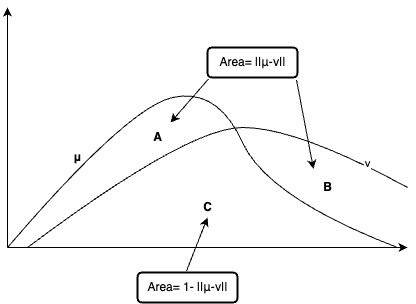

Figure 9.1: schematics of the optimal coupling

Consider now the coupling defined as follows. Pick a random number $U$

If $U \le p$ then let $Z$ be the RV with pdf
$$\gamma_C(i)=\frac{ \mu(i) \wedge \nu(i) }{p}$$
and set $X=Y=Z$.

If $U>p$ then let $X$ be the random variable with pdf $\gamma_A(i)$ and $Y$ be the random variable with pdf $\gamma_B(i)$ where
$$\begin{aligned}
\gamma_A(i) =\left\{
\begin{array}{cl}
\frac{\mu(i)-\nu(i)}{\|\mu-\nu\|_{\textrm{TV}}} & \mu(i)\ge \nu(i) \\
0 & \textrm{otherwise}
\end{array}
\right.
\quad
\gamma_B(i) =\left\{
\begin{array}{cl}
\frac{\nu(i)-\mu(i)}{\|\mu-\nu\|_{\textrm{TV}}} & \nu(i)\ge \mu(i) \\
0 & \textrm{otherwise}
\end{array}
\right.
\end{aligned}$$

Since $p \gamma_C + (1-p) \gamma_A = \mu$ and $p \gamma_C + (1-p) \gamma_B = \nu$ this defines a coupling and we have $P\{ X\not=Y\}=1-p =\|\mu-\nu\|_{\textrm{TV}}$. $\quad \blacksquare$.

## 9.3 Coupling of Markov chains

- A coupling of a Markov chain is a stochastic process $(X_n,Y_n)$ with state space $S\times S$ such that both $X_n$ and $Y_n$ are Markov chains with transition matrix $P$ but with possibly different initial conditions.
- A Markovian coupling is a coupling such that the joint $(X_n,Y_n)$ is itself a Markov chain with some transition matrix $Q((i,j), (k,l))$ which must then satisfy
  $$\sum_{k} Q((i,j), (k,l)) = P(j,l) \quad \textrm{ and } \sum_{l} Q((i,j), (k,l)) = P(i,k) \,.$$
- In Theorem 2.3 where we proved the convergence of aperiodic irreducible Markov chains to their stationary distribution using an independent coupling. That is we pick $Q((i,j), (k,l))= P(i,k) P(j,l)$.
- Another useful coupling is the common noise coupling. To understand this recall that any Markov chain has the representation $X_n=f(X_{n-1}, Z_n)$ where the $Z_n$ are IID random variable. For the common noise coupling we use
  $$X_n=f(X_{n-1}, Z_n) \, \quad \quad Y_n=f(X_{n-1}, Z_n)$$
  where we use the same noise $Z_n$ to evolve both $X_n$ and $Y_n$.
- The coupling time is defined by
  $$\sigma= \inf \{ n \ge 0 \,:\, X_n=Y_n \}$$
  that is, it is the first time that the Markov chain visit the same state.
- After the coupling time $\sigma$, $X_n$ and $Y_n$ have the same distribution (by the strong Markov property) so we can always modified a coupling so that, after time $\sigma$, $X_n$ and $Y_n$ are moving together, i.e. $X_n=Y_n$ for all $n \ge \sigma$ (that is we use the common noise coupling). We will *always* assume this to be true in what follows.

## 9.4 Speed of convergence via coupling

**Theorem 9.3** Suppose $(X_n,Y_n)$ is a coupling of a Markov chain such that $X_0=i$ and $Y_0=j$ and $\sigma$ is the coupling time. Then we have
$$\|P^n(i,\cdot) - P^n(j,\cdot)\|_{ \textrm{TV} } \le P \left\{ \sigma>n| X_0=i, Y_0=j\right\}$$

*Proof*. We have $P\{X_n=l|X_0=i\}=P^n(i,l)$ and $P\{Y_n=l|Y_0=j\}=P^n(j,l)$ and therefore $X_n$ and $Y_n$ is a coupling of the the probability distributions $P^n(i,\cdot)$ and $P^n(j,\cdot)$. So by Theorem 9.2 we have
$$\|P^n(i,\cdot) - P^n(j,\cdot)\|_{\textrm{TV}} \le P \left\{ X_n \not= Y_n | X_0=i,Y_0=j\right\} = P \left\{ \sigma > n | X_0=i,Y_0=j\right\}\,.$$
$\blacksquare$

We can use this result to bound the distance to the stationary measure

**Theorem 9.4** We have
$$\sup_{i \in S } \| P^n(i,\cdot) - \pi\|_{\textrm{TV}} \le \sup_{i,j \in S } \|P^n(i,\cdot) - P^n(j,\cdot)\|_{\textrm{TV}}$$

*Proof*. Using the stationarity and the triangle inequality we have
$$\begin{aligned}
\| P^n(i,\cdot) - \pi\|_{\textrm{TV}}
&= \sup_{A} |P^n(i,A) - \pi(A)| \\
& = \sup_{A}| \sum_{j} \pi(j) (P^n(i,A)-P^n(j,A))| \\
%& \le \sup_{A} \sum_{j} \pi(j) |P^n(i,A)-P^n(j,A)| \\
& \le \sum_{j} \pi(j) \sup_{A} |P^n(i,A)-P^n(j,A)| \\
& = \sum_{j} \pi(j) \|P^n(i,\cdot) - P^n(j,\cdot)\|_{TV} \\
& \le \sup_{i,j\in S} \|P^n(i,\cdot) - P^n(j,\cdot)\|_{TV} \quad \blacksquare
\end{aligned}$$

We set $d(n) = \sup_{i} \|P^n(i,\cdot) - \pi \|_{\textrm{TV}}$ which is the maximal distance to stationarity starting from an arbitrary initial state. (It is not hard to see that $\|\mu P^n - \pi \|_{\textrm{TV}} \le d(n)$ for abitrary initial distribution $\mu$ as well).
We define then the mixing time $t_{\textrm{mix}}(\varepsilon)$ of a Markov chain to be
$$t_{\textrm{mix}}(\varepsilon) = \min\{ n, d(n) \le \varepsilon \}\,.$$
That is, if $n>t_{\textrm{mix}}(\varepsilon)$ then $\mu P^n$ is less than $\varepsilon$ close to the stationary distribution.

## 9.5 Mixing time for the sucess run chain

We start with a countable state space example, the success run chain which is very easy to analyze.

Parenthetically, it should be noted that the supremum over $i$ in $d(n)$ is often not well suited for countable state space. It may often happen that the number of steps it take to be close to the stationary distribution may depend on where you start.

We consider a special case of Example 4.4 with constant succes probability.
$$P(n,0)=(1-p)\,, \quad P(n,n+1)= p\,, \quad n=0,1,2,\cdots$$

Suppose $X_0=i$ and $Y_0=j$ (with $i\not=j$) we couple the two chains by moving them together.

- Pick a random number $U$, if $U \le (1-p)$ then set $X_1=Y_1=0$ the coupling time $\sigma=1$.
- If $U \ge 1-p$ then move $X_1=i+1$, $Y_1=j+1$.

Clearly we have
$$P( \sigma >n| X_0=i, Y_0=j) = p^n$$
and thus we find for the mixing time
$$d(n)=p^n < \varepsilon \iff n \ge \frac{\ln(p)}{\ln \varepsilon}$$

## 9.6 Mixing time for the random walk on the hypercube

Recall that for the random walk on the hypercube (see Example 1.4) a state is a $d$-bit $\sigma=(\sigma_1, \cdots, \sigma_d)$ with $\sigma_j\in \{0,1\}$.

The Markov chain is periodic with period $2$ so to make it aperiodic we consider its “lazy” version in which we do not move with probability $1/2$, that is we consider instead the transition matrix $\frac{P+I}{2}$ which makes it periodic. The Markov chain moves then as follows, we pick a coordinate $\sigma_j$ at random and then replace by a random bit $0$ or $1$.

To couple the Markov chain we simply move *move them together*: If $X_n=\sigma$ and $Y_n=\sigma'$ we pick a coordinate $j \in \{1,\cdots, d\}$ at random and then replace both $\sigma_j$ and $\sigma'_j$ by the *same* random bit. This is a coupling and after a move the chosen coordinates coincide.

Under this coupling $X_n$ and $Y_n$ will get closer to each other if we select a $j$ such that $\sigma_j \not= \sigma'_j$ and we will couple when all the coordinates have been selected. The distribution of the coupling time is thus exactly the same as the time $\tau$ need to collect $d$ toys in the coupon collector problem.

We now get a bound on the tail as follows. We denote by $A_i$ the events that coordinate $i$ has not been selected after $m$ steps. We have, using the inequality $(1-x)\le e^{-x}$
$$\begin{aligned}
P\{\sigma > n\} = P\left(\bigcup_{i=1}^d A_i\right) \le \sum_{i=1}^d P(A_i) =
\sum_{i=1}^d \left(1- \frac{1}{d}\right)^n \le d e^{-\frac{n}{d}}
\end{aligned}$$
So if we pick $n = d\ln(d) + c d$ we find
$$P\{\sigma > d\ln(d) + c d\} \le d e^{-\frac{d \ln(d) + cd}{d}}= e^{-c} \implies t_{\textrm{mix}}(\varepsilon) \le d\ln(d) + \ln(\varepsilon^{-1})d\,.$$

## 9.7 Exercise

**Exercise 9.1 (Properties of the total variation norm)**

1. Prove the following formula for the total variation norm
   $$\|\mu-\nu\|_{\rm TV} = \sup_{f \,:\, \|f\|_\infty=\sup_{i}|f(i)|\le 1} |\mu f - \nu f|$$
2. Prove that the map $(\mu, \nu) \mapsto \|\mu-\nu\|_{\text{TV}}$ is a (jointly) convex in $(\mu\, \nu)$.
3. Prove that $\|\mu P^n - \nu P^n\|_{TV} \le \sum_{i,j} \mu(i) \nu(j) \|P^n(i, \cdot) - P^n(j, \cdot)\|_{\text{TV}}$

**Exercise 9.2 (Examples of optimal coupling)**

1. Suppose $X$ and $Y$ are two Bernoulii random variables with paramter $p$ and $q$. Using random number $U$ we can represent $X = 1_{U<p}$. Consider the coupling between $X$ and $Y$ by using the same random variable $U$ to generate $X$ and $Y$. Compute the joint distribution of $(X,Y)$.
2. What is the optimal coupling between $X$ and $Y$ in the sense of Theorem 9.2

**Exercise 9.3 (Coupling for card shuffling)** We consider the following shuffling procedure: given a deck of 52 cards pick one number $j$ at random between 1 and 52 and take the card in poistion $j$ and move itto the top of the card (this is called the random to top shuffling).

Now consider the following coupling: you have two decks of cards. Do a random to top shuffling for the first deck. Look at which card you just put on top (say a seven of spades). Now in the second deck take the seven of spades and put it on top.

Show that this is a coupling and use this to show that after $n\ln(n/\epsilon)$ the random to top shuffling is at total variation distance no more than $\epsilon$ from the stationary distribution.

## 9.8 References

Hajek, Bruce. 1988. “Cooling Schedules for Optimal Annealing.” *Mathematics of Operations Research* 13 (2): 311–29. http://www.jstor.org/stable/3689827.

Lawler, Gregory F. 2006. *Introduction to Stochastic Processes.*

Levin, David Asher, James Propp, David B. Wilson, Elizabeth L. Wilmer, and Y. Peres. 2017. *Markov Chains and Mixing Times.* American Mathematical Society.